# PANCHANGE_analysis

Katie Thompson, Topher Huebel, Molly Davies, Kirstin Purves

Sys.Date()

This is the analysis script to prepare the data to run analyses for the project “Anxiety, depression and trauma symptom change during the COVID-19 pandemic: retrospective versus objective assessment” - Young et al (2020)

Script written by K Purves, K Thompson, C Huebel and M Davies. Email: kirstin.purves@kcl.ac.uk, katie.thompson@kcl.ac.uk, christopher.1.huebel@kcl.ac.uk, molly.davies@kcl.ac.uk

#Set up

Clear global environment

Retrieve the current date to use it for file endings to not overwrite files when one exports files

#Packages Install packages (if they are not available in your version of R)

Load packages

```
x ggplot2::%+%()   masks psych::%+%()
```

# Colour palettes

Define colours for plotting this are the standard coping colours

Choose in this chunk which palette to use 04.07.2020 - Default to 2 colour COPING palette

# ggplot theme

Set up ggplot theme for the plots

# Data import

## Read in data

```
[1] 31656   602
```

```
  [1] "Sample"
  [2] "ID"
  [3] "startDate.prepandemic"
  [4] "Age_uncleaned"
  [5] "Gender_unc"
  [6] "Sex"
  [7] "EduYrs"
  [8] "demographics.college_or_university_degree"
  [9] "demographics.a_levelsas_levels_or_equivalent"
 [10] "demographics.o_levelsgcses_or_equivalent"
 [11] "demographics.cses_or_equivalent"
 [12] "demographics.nvq_or_hnd_or_hnc_or_equivalent"
 [13] "Ethnicity_unc"
 [14] "Gender_numeric"
 [15] "Sex_numeric"
```

[output cut: 587 more lines]

## Important vectors with collections of columns

## Vectors for sum_score

```
 [1] "gad.sum_score_prepan"        "pcl.sum_score_prepan"
 [3] "phq.sum_score_prepan"        "phq.sum_score_8items_prepan"
 [5] "ocir.sum_score_prepan"       "gad.sum_score_base"
 [7] "gad.sum_score_retro"         "pcl.sum_score_base"
 [9] "pcl.sum_score_retro"         "phq.sum_score_base"
[11] "phq.sum_score_8items_base"   "phq.sum_score_retro"
[13] "phq.sum_score_8items_retro"  "ocir.sum_score_base"
[15] "ocir.sum_score_retro"
```

```
[1] "phq.sum_score_prepan" "phq.sum_score_base"   "phq.sum_score_retro"
```

```
[1] "gad.sum_score_prepan" "gad.sum_score_base"   "gad.sum_score_retro"
```

```
[1] "ocir.sum_score_prepan" "ocir.sum_score_base"   "ocir.sum_score_retro"
```

```
[1] "pcl.sum_score_prepan" "pcl.sum_score_base"   "pcl.sum_score_retro"
```

## Vectors for diff_score

```
 [1] "phq.diff_score_retro_prepan"  "phq.diff_score_base_prepan"
 [3] "phq.diff_score_base_retro"    "gad.diff_score_retro_prepan"
 [5] "gad.diff_score_base_prepan"   "gad.diff_score_base_retro"
 [7] "pcl.diff_score_base_prepan"   "ocir.diff_score_retro_prepan"
 [9] "ocir.diff_score_base_prepan"  "ocir.diff_score_base_retro"
```

```
[1] "phq.diff_score_retro_prepan" "phq.diff_score_base_prepan"
[3] "phq.diff_score_base_retro"
```

```
[1] "gad.diff_score_retro_prepan" "gad.diff_score_base_prepan"
[3] "gad.diff_score_base_retro"
```

```
[1] "ocir.diff_score_retro_prepan" "ocir.diff_score_base_prepan"
[3] "ocir.diff_score_base_retro"
```

#ANALYSIS PLAN 1. Calculate mean change per disorder group i. Disorders (9) a. Rank the disorders by the size of the change ii. Sex iii. Age (13; RAMP; potentially collapse above 65 depending on group sizes) iv. Ethnicity groups (5; White European, Black (British), Asian, Arab, Mixed)

# 1. Questionnaire comparions: Calculate mean change per group

## gad

### Summary scores

| gad.change_binary | Prepan_mean | Base_mean | Retro_mean | Prepan_sd | Base_sd | Retro_sd | Prepan_median | Base_median | Retro_median | Prepan_min | Base_min | Retro_min | Prepan_max | Base_max | Retro_max | Prepan_skew | Base_skew | Retro_skew | Prepan_kurtosis | Base_kurtosis | Retro_kurtosis |
| --- | --- | --- | --- | --- | --- | --- | --- | --- | --- | --- | --- | --- | --- | --- | --- | --- | --- | --- | --- | --- | --- |
| No change | 8.263319 | 2.644151 | NaN | 6.205455 | 4.427571 | NA | 7 | 0 | NA | 0 | 0 | Inf | 21 | 21 | -Inf | 0.47084604 | 2.1896831 | NA | -0.9094530 | 4.5243936 | NA |
| Worsening | 9.395522 | 8.667286 | 4.622999 | 5.856213 | 5.688727 | 4.271819 | 8 | 7 | 4 | 0 | 0 | 0 | 21 | 21 | 21 | 0.34162322 | 0.5300909 | 1.3790990 | -0.9285568 | -0.7925179 | 1.9434344 |
| Improvement | 9.229856 | 4.734068 | 8.346929 | 5.813215 | 4.792302 | 5.468637 | 8 | 3 | 7 | 0 | 0 | 0 | 21 | 21 | 21 | 0.33476480 | 1.3658899 | 0.5200135 | -0.8985195 | 1.5835669 | -0.5748321 |
| NA | 10.000000 | 5.479167 | NaN | 8.563488 | 5.889007 | NA | 13 | 4 | NA | 0 | 0 | Inf | 21 | 21 | -Inf | -0.03139272 | 1.1007255 | NA | -1.9895986 | 0.3415449 | NA |

| Change | Variable | Min | Max | Mean | Median | SD | Skew | Kurtosis |
| --- | --- | --- | --- | --- | --- | --- | --- | --- |
| No change | Base | 0 | 21 | 2.644151 | 0 | 4.427571 | 2.18968308 | 4.5243936 |
| No change | Prepan | 0 | 21 | 8.263319 | 7 | 6.205455 | 0.47084604 | -0.9094530 |
| No change | Retro | Inf | -Inf | NaN | NA | NA | NA | NA |
| Worsening | Base | 0 | 21 | 8.667286 | 7 | 5.688727 | 0.53009094 | -0.7925179 |
| Worsening | Prepan | 0 | 21 | 9.395522 | 8 | 5.856213 | 0.34162322 | -0.9285568 |
| Worsening | Retro | 0 | 21 | 4.622999 | 4 | 4.271819 | 1.37909898 | 1.9434344 |
| Improvement | Base | 0 | 21 | 4.734068 | 3 | 4.792302 | 1.36588991 | 1.5835669 |
| Improvement | Prepan | 0 | 21 | 9.229856 | 8 | 5.813215 | 0.33476480 | -0.8985195 |
| Improvement | Retro | 0 | 21 | 8.346929 | 7 | 5.468637 | 0.52001350 | -0.5748321 |
| NA | Base | 0 | 21 | 5.479167 | 4 | 5.889007 | 1.10072552 | 0.3415449 |

[output cut: 2 more lines]

Table for knitting gad sum score summary table

| Change | Variable | Min | Max | Mean | Median | SD | Skew | Kurtosis |
| --- | --- | --- | --- | --- | --- | --- | --- | --- |
| No change | Base | 0 | 21 | 2.644151 | 0 | 4.427571 | 2.1896831 | 4.5243936 |
| No change | Prepan | 0 | 21 | 8.263319 | 7 | 6.205455 | 0.4708460 | -0.9094530 |
| No change | Retro | Inf | -Inf | NaN | NA | NA | NA | NA |
| Worsening | Base | 0 | 21 | 8.667286 | 7 | 5.688727 | 0.5300909 | -0.7925179 |
| Worsening | Prepan | 0 | 21 | 9.395522 | 8 | 5.856213 | 0.3416232 | -0.9285568 |
| Worsening | Retro | 0 | 21 | 4.622999 | 4 | 4.271819 | 1.3790990 | 1.9434344 |
| Improvement | Base | 0 | 21 | 4.734068 | 3 | 4.792302 | 1.3658899 | 1.5835669 |
| Improvement | Prepan | 0 | 21 | 9.229856 | 8 | 5.813215 | 0.3347648 | -0.8985195 |
| Improvement | Retro | 0 | 21 | 8.346929 | 7 | 5.468637 | 0.5200135 | -0.5748321 |
| NA | Base | 0 | 21 | 5.479167 | 4 | 5.889007 | 1.1007255 | 0.3415449 |
| NA | Prepan | 0 | 21 | 10.000000 | 13 | 8.563488 | -0.0313927 | -1.9895986 |
| NA | Retro | Inf | -Inf | NaN | NA | NA | NA | NA |

### Differences scores

| gad.change_binary | Base - prepan_mean | Base - retro_mean | Prepan - retro_mean | Base - prepan_sd | Base - retro_sd | Prepan - retro_sd | Base - prepan_median | Base - retro_median | Prepan - retro_median | Base - prepan_min | Base - retro_min | Prepan - retro_min | Base - prepan_max | Base - retro_max | Prepan - retro_max | Base - prepan_skew | Base - retro_skew | Prepan - retro_skew | Base - prepan_kurtosis | Base - retro_kurtosis | Prepan - retro_kurtosis |
| --- | --- | --- | --- | --- | --- | --- | --- | --- | --- | --- | --- | --- | --- | --- | --- | --- | --- | --- | --- | --- | --- |
| No change | -2.0610617 | NaN | NaN | 4.732334 | NA | NA | -1 | NA | NA | -21 | Inf | Inf | 20 | -Inf | -Inf | -0.48392920 | NA | NA | 1.4967586 | NA | NA |
| Worsening | 0.9722107 | 4.045474 | -3.5741971 | 5.311708 | 4.278713 | 5.104206 | 1 | 3 | -3 | -18 | -21 | -21 | 21 | 21 | 18 | -0.01721620 | 0.7734232 | -0.2944346 | 0.6009871 | 0.898742 | 0.4404629 |
| Improvement | -4.0687606 | -3.607965 | 0.3483432 | 5.492207 | 5.278090 | 5.698578 | -3 | -3 | 1 | -21 | -21 | -21 | 12 | 21 | 20 | -0.29999766 | 0.4287263 | -0.1563139 | 0.1338814 | 2.068401 | 0.8732731 |
| NA | -1.5000000 | NaN | NaN | 5.431390 | NA | NA | -2 | NA | NA | -9 | Inf | Inf | 6 | -Inf | -Inf | 0.04680888 | NA | NA | -1.6798094 | NA | NA |

| Change | Variable | Min | Max | Mean | Median | SD | Skew | Kurtosis |
| --- | --- | --- | --- | --- | --- | --- | --- | --- |
| No change | Base - prepan | -21 | 20 | -2.0610617 | -1 | 4.732334 | -0.48392920 | 1.4967586 |
| No change | Base - retro | Inf | -Inf | NaN | NA | NA | NA | NA |
| No change | Prepan - retro | Inf | -Inf | NaN | NA | NA | NA | NA |
| Worsening | Base - prepan | -18 | 21 | 0.9722107 | 1 | 5.311708 | -0.01721620 | 0.6009871 |
| Worsening | Base - retro | -21 | 21 | 4.0454736 | 3 | 4.278713 | 0.77342321 | 0.8987420 |
| Worsening | Prepan - retro | -21 | 18 | -3.5741971 | -3 | 5.104206 | -0.29443463 | 0.4404629 |
| Improvement | Base - prepan | -21 | 12 | -4.0687606 | -3 | 5.492207 | -0.29999766 | 0.1338814 |
| Improvement | Base - retro | -21 | 21 | -3.6079655 | -3 | 5.278090 | 0.42872631 | 2.0684012 |
| Improvement | Prepan - retro | -21 | 20 | 0.3483432 | 1 | 5.698578 | -0.15631387 | 0.8732731 |
| NA | Base - prepan | -9 | 6 | -1.5000000 | -2 | 5.431390 | 0.04680888 | -1.6798094 |

[output cut: 2 more lines]

Table for knitting gad diff summary table

| Change | Variable | Min | Max | Mean | Median | SD | Skew | Kurtosis |
| --- | --- | --- | --- | --- | --- | --- | --- | --- |
| No change | Base - prepan | -21 | 20 | -2.0610617 | -1 | 4.732334 | -0.4839292 | 1.4967586 |
| No change | Base - retro | Inf | -Inf | NaN | NA | NA | NA | NA |
| No change | Prepan - retro | Inf | -Inf | NaN | NA | NA | NA | NA |
| Worsening | Base - prepan | -18 | 21 | 0.9722107 | 1 | 5.311708 | -0.0172162 | 0.6009871 |
| Worsening | Base - retro | -21 | 21 | 4.0454736 | 3 | 4.278713 | 0.7734232 | 0.8987420 |
| Worsening | Prepan - retro | -21 | 18 | -3.5741971 | -3 | 5.104206 | -0.2944346 | 0.4404629 |
| Improvement | Base - prepan | -21 | 12 | -4.0687606 | -3 | 5.492207 | -0.2999977 | 0.1338814 |
| Improvement | Base - retro | -21 | 21 | -3.6079655 | -3 | 5.278090 | 0.4287263 | 2.0684012 |
| Improvement | Prepan - retro | -21 | 20 | 0.3483432 | 1 | 5.698578 | -0.1563139 | 0.8732731 |
| NA | Base - prepan | -9 | 6 | -1.5000000 | -2 | 5.431390 | 0.0468089 | -1.6798094 |
| NA | Base - retro | Inf | -Inf | NaN | NA | NA | NA | NA |
| NA | Prepan - retro | Inf | -Inf | NaN | NA | NA | NA | NA |

### Long format

|  | ID | Sample | Gender_collapsed | Ethnicity_collapsed | Disorder_hierarchical | gad.diff_score | Time_point |
| --- | --- | --- | --- | --- | --- | --- | --- |
| 1 | 8 | GLAD | Male | European | Depressive disorders | NA | retro_prepan |
| 2 | 10 | GLAD | Female | European | Depressive disorders | -5 | retro_prepan |
| 3 | 11 | GLAD | Male | European | Depressive disorders | 7 | retro_prepan |
| 4 | 13 | GLAD | Female | European | Depressive disorders | 0 | retro_prepan |
| 5 | 15 | GLAD | Female | European | Depressive disorders | NA | retro_prepan |
| 6 | 20 | GLAD | Female | European | Depressive disorders | 15 | retro_prepan |

|  | ID | Sample | Gender_collapsed | Ethnicity_collapsed | Disorder_hierarchical | gad.sum_score | Time_point |
| --- | --- | --- | --- | --- | --- | --- | --- |
| 1 | 8 | GLAD | Male | European | Depressive disorders | 16 | prepan |
| 2 | 10 | GLAD | Female | European | Depressive disorders | 7 | prepan |
| 3 | 11 | GLAD | Male | European | Depressive disorders | 2 | prepan |
| 4 | 13 | GLAD | Female | European | Depressive disorders | 5 | prepan |
| 5 | 15 | GLAD | Female | European | Depressive disorders | 3 | prepan |
| 6 | 20 | GLAD | Female | European | Depressive disorders | 6 | prepan |

### Plots diff

makes this into percentages

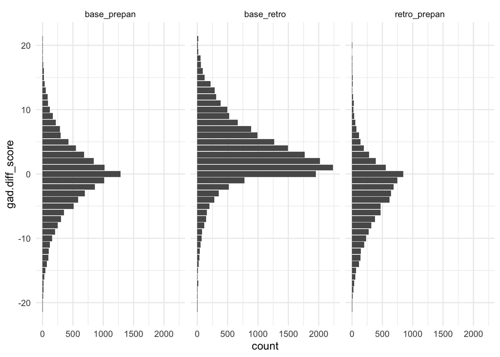

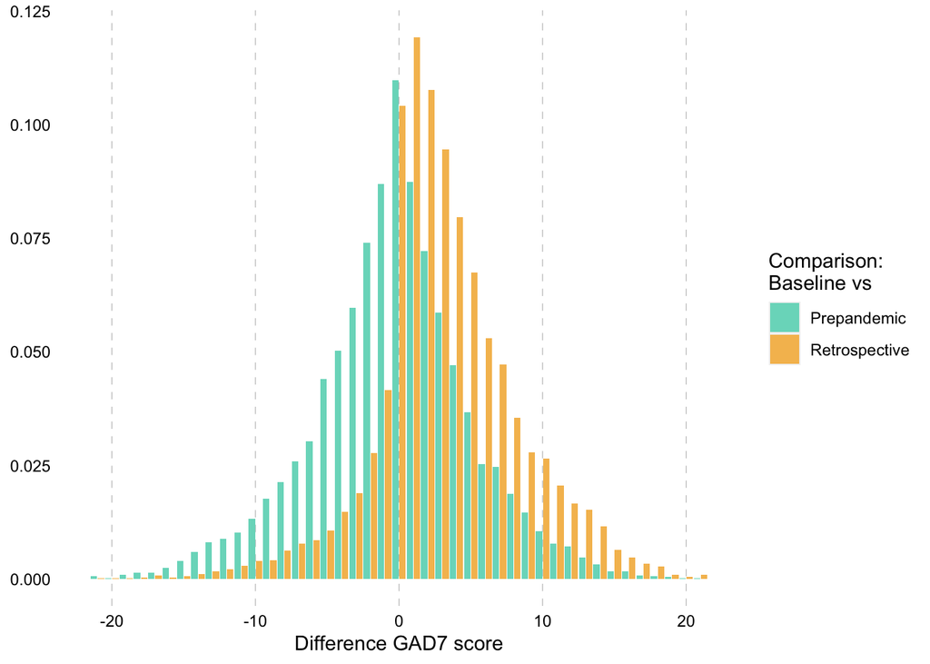

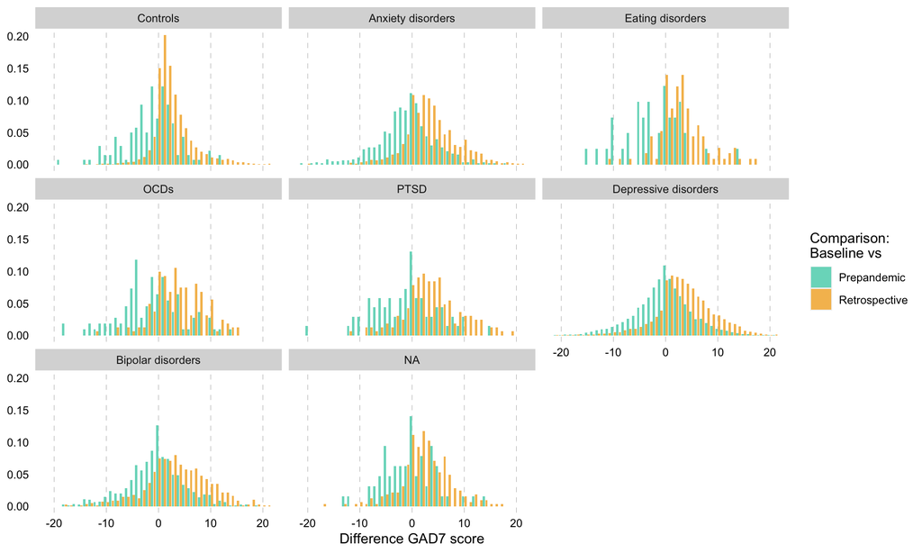

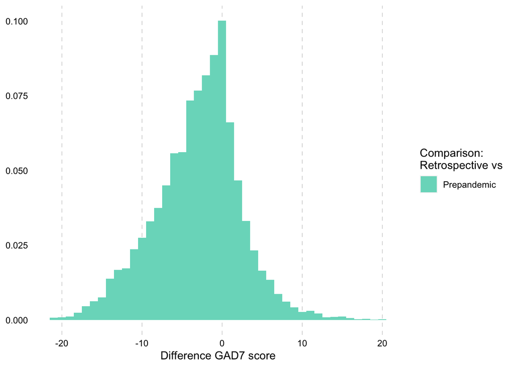

### Plots sum

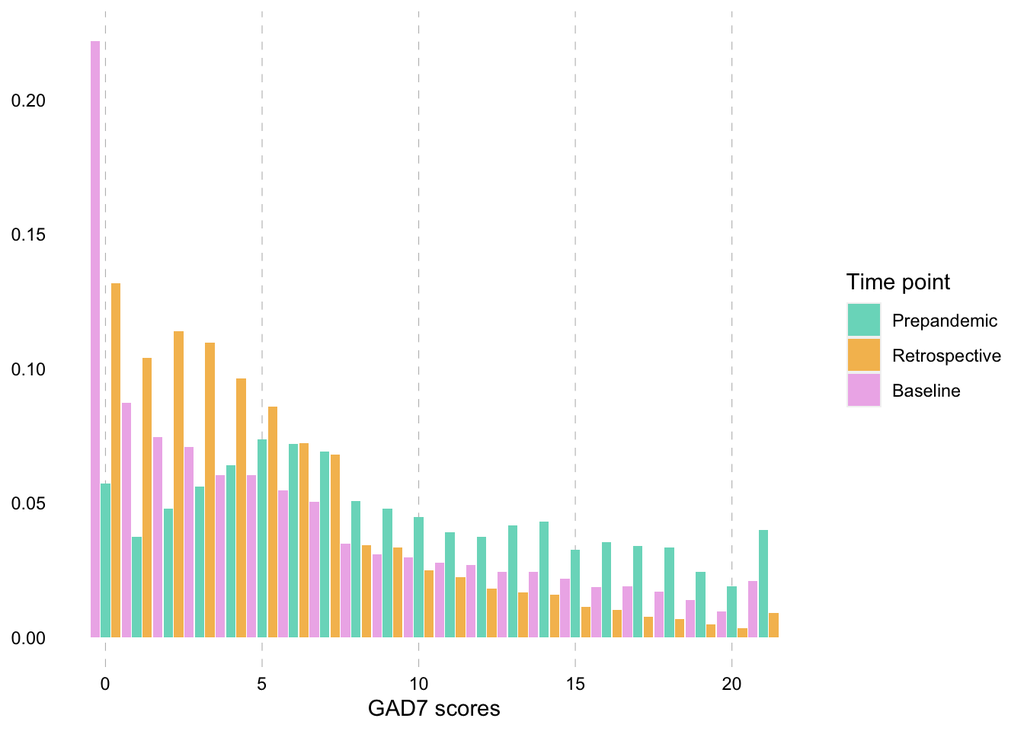

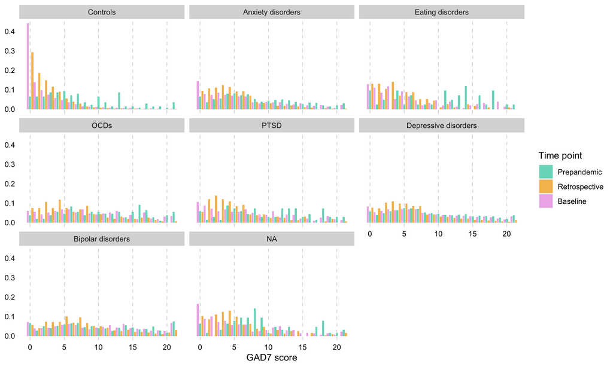

## phq

### Summary scores

| phq.change_binary | Prepan_mean | Base_mean | Retro_mean | Prepan_sd | Base_sd | Retro_sd | Prepan_median | Base_median | Retro_median | Prepan_min | Base_min | Retro_min | Prepan_max | Base_max | Retro_max | Prepan_skew | Base_skew | Retro_skew | Prepan_kurtosis | Base_kurtosis | Retro_kurtosis |
| --- | --- | --- | --- | --- | --- | --- | --- | --- | --- | --- | --- | --- | --- | --- | --- | --- | --- | --- | --- | --- | --- |
| No change | 10.47491 | 3.751084 | NaN | 7.201444 | 5.446976 | NA | 9 | 2 | NA | 0 | 0 | Inf | 27 | 27 | -Inf | 0.4741123 | 2.0322669 | NA | -0.7475571 | 3.8732380 | NA |
| Worsening | 11.72712 | 10.285336 | 5.696905 | 6.742953 | 6.592386 | 5.269996 | 11 | 9 | 4 | 0 | 0 | 0 | 27 | 27 | 27 | 0.3037578 | 0.5989792 | 1.4256319 | -0.7712932 | -0.5310081 | 1.9669136 |
| Improvement | 11.52199 | 6.718949 | 9.802548 | 6.724335 | 5.715055 | 6.780175 | 11 | 5 | 9 | 0 | 0 | 0 | 27 | 27 | 27 | 0.3010798 | 1.0617910 | 0.6018901 | -0.8151806 | 0.7417556 | -0.4521918 |
| NA | 11.42424 | 5.905797 | NaN | 7.583000 | 6.905924 | NA | 9 | 3 | NA | 0 | 0 | Inf | 25 | 27 | -Inf | 0.3851207 | 1.1356293 | NA | -1.1446285 | 0.3384540 | NA |

| Phq.change_binary | Variable | Min | Max | Mean | Median | SD | Skew | Kurtosis |
| --- | --- | --- | --- | --- | --- | --- | --- | --- |
| No change | Base | 0 | 27 | 3.751084 | 2 | 5.446976 | 2.0322669 | 3.8732380 |
| No change | Prepan | 0 | 27 | 10.474906 | 9 | 7.201444 | 0.4741123 | -0.7475571 |
| No change | Retro | Inf | -Inf | NaN | NA | NA | NA | NA |
| Worsening | Base | 0 | 27 | 10.285336 | 9 | 6.592386 | 0.5989792 | -0.5310081 |
| Worsening | Prepan | 0 | 27 | 11.727124 | 11 | 6.742953 | 0.3037578 | -0.7712932 |
| Worsening | Retro | 0 | 27 | 5.696905 | 4 | 5.269996 | 1.4256319 | 1.9669136 |
| Improvement | Base | 0 | 27 | 6.718949 | 5 | 5.715055 | 1.0617910 | 0.7417556 |
| Improvement | Prepan | 0 | 27 | 11.521994 | 11 | 6.724335 | 0.3010798 | -0.8151806 |
| Improvement | Retro | 0 | 27 | 9.802548 | 9 | 6.780175 | 0.6018901 | -0.4521918 |
| NA | Base | 0 | 27 | 5.905797 | 3 | 6.905924 | 1.1356293 | 0.3384540 |

[output cut: 2 more lines]

Table for knitting phq sum score summary table

| Phq.change_binary | Variable | Min | Max | Mean | Median | SD | Skew | Kurtosis |
| --- | --- | --- | --- | --- | --- | --- | --- | --- |
| No change | Base | 0 | 27 | 3.751084 | 2 | 5.446976 | 2.0322669 | 3.8732380 |
| No change | Prepan | 0 | 27 | 10.474906 | 9 | 7.201444 | 0.4741123 | -0.7475571 |
| No change | Retro | Inf | -Inf | NaN | NA | NA | NA | NA |
| Worsening | Base | 0 | 27 | 10.285336 | 9 | 6.592386 | 0.5989792 | -0.5310081 |
| Worsening | Prepan | 0 | 27 | 11.727124 | 11 | 6.742953 | 0.3037578 | -0.7712932 |
| Worsening | Retro | 0 | 27 | 5.696905 | 4 | 5.269996 | 1.4256319 | 1.9669136 |
| Improvement | Base | 0 | 27 | 6.718949 | 5 | 5.715055 | 1.0617910 | 0.7417556 |
| Improvement | Prepan | 0 | 27 | 11.521994 | 11 | 6.724335 | 0.3010798 | -0.8151806 |
| Improvement | Retro | 0 | 27 | 9.802548 | 9 | 6.780175 | 0.6018901 | -0.4521918 |
| NA | Base | 0 | 27 | 5.905797 | 3 | 6.905924 | 1.1356293 | 0.3384540 |
| NA | Prepan | 0 | 25 | 11.424242 | 9 | 7.583000 | 0.3851207 | -1.1446285 |
| NA | Retro | Inf | -Inf | NaN | NA | NA | NA | NA |

### Differences score

| phq.change_binary | Base - prepan_mean | Base - retro_mean | Prepan - retro_mean | Base - prepan_sd | Base - retro_sd | Prepan - retro_sd | Base - prepan_median | Base - retro_median | Prepan - retro_median | Base - prepan_min | Base - retro_min | Prepan - retro_min | Base - prepan_max | Base - retro_max | Prepan - retro_max | Base - prepan_skew | Base - retro_skew | Prepan - retro_skew | Base - prepan_kurtosis | Base - retro_kurtosis | Prepan - retro_kurtosis |
| --- | --- | --- | --- | --- | --- | --- | --- | --- | --- | --- | --- | --- | --- | --- | --- | --- | --- | --- | --- | --- | --- |
| No change | -1.9873288 | NaN | NaN | 5.138924 | NA | NA | -1 | NA | NA | -25 | Inf | Inf | 23 | -Inf | -Inf | -0.31582751 | NA | NA | 1.6899330 | NA | NA |
| Worsening | 0.8044898 | 4.583867 | -4.2459485 | 5.551624 | 4.519872 | 5.498939 | 1 | 4 | -4 | -23 | -18 | -27 | 24 | 27 | 21 | -0.07023685 | 0.92828219 | -0.3764632 | 0.8801034 | 1.357391 | 0.604677 |
| Improvement | -4.0176082 | -3.075616 | -0.1294118 | 5.604538 | 5.516985 | 6.144041 | -3 | -3 | 0 | -22 | -24 | -27 | 14 | 23 | 22 | -0.41445009 | -0.03519592 | -0.0218246 | 0.2273638 | 1.750540 | 0.727592 |
| NA | -0.5312500 | NaN | NaN | 6.111778 | NA | NA | 0 | NA | NA | -21 | Inf | Inf | 8 | -Inf | -Inf | -1.10418703 | NA | NA | 1.8755762 | NA | NA |

| Phq.change_binary | Variable | Min | Max | Mean | Median | SD | Skew | Kurtosis |
| --- | --- | --- | --- | --- | --- | --- | --- | --- |
| No change | Base - prepan | -25 | 23 | -1.9873288 | -1 | 5.138924 | -0.31582751 | 1.6899330 |
| No change | Base - retro | Inf | -Inf | NaN | NA | NA | NA | NA |
| No change | Prepan - retro | Inf | -Inf | NaN | NA | NA | NA | NA |
| Worsening | Base - prepan | -23 | 24 | 0.8044898 | 1 | 5.551624 | -0.07023685 | 0.8801034 |
| Worsening | Base - retro | -18 | 27 | 4.5838671 | 4 | 4.519872 | 0.92828219 | 1.3573905 |
| Worsening | Prepan - retro | -27 | 21 | -4.2459485 | -4 | 5.498939 | -0.37646319 | 0.6046770 |
| Improvement | Base - prepan | -22 | 14 | -4.0176082 | -3 | 5.604538 | -0.41445009 | 0.2273638 |
| Improvement | Base - retro | -24 | 23 | -3.0756160 | -3 | 5.516985 | -0.03519592 | 1.7505401 |
| Improvement | Prepan - retro | -27 | 22 | -0.1294118 | 0 | 6.144041 | -0.02182460 | 0.7275920 |
| NA | Base - prepan | -21 | 8 | -0.5312500 | 0 | 6.111778 | -1.10418703 | 1.8755762 |

[output cut: 2 more lines]

Table for knitting phq diff summary table

| Phq.change_binary | Variable | Min | Max | Mean | Median | SD | Skew | Kurtosis |
| --- | --- | --- | --- | --- | --- | --- | --- | --- |
| No change | Base - prepan | -25 | 23 | -1.9873288 | -1 | 5.138924 | -0.3158275 | 1.6899330 |
| No change | Base - retro | Inf | -Inf | NaN | NA | NA | NA | NA |
| No change | Prepan - retro | Inf | -Inf | NaN | NA | NA | NA | NA |
| Worsening | Base - prepan | -23 | 24 | 0.8044898 | 1 | 5.551624 | -0.0702368 | 0.8801034 |
| Worsening | Base - retro | -18 | 27 | 4.5838671 | 4 | 4.519872 | 0.9282822 | 1.3573905 |
| Worsening | Prepan - retro | -27 | 21 | -4.2459485 | -4 | 5.498939 | -0.3764632 | 0.6046770 |
| Improvement | Base - prepan | -22 | 14 | -4.0176082 | -3 | 5.604538 | -0.4144501 | 0.2273638 |
| Improvement | Base - retro | -24 | 23 | -3.0756160 | -3 | 5.516985 | -0.0351959 | 1.7505401 |
| Improvement | Prepan - retro | -27 | 22 | -0.1294118 | 0 | 6.144041 | -0.0218246 | 0.7275920 |
| NA | Base - prepan | -21 | 8 | -0.5312500 | 0 | 6.111778 | -1.1041870 | 1.8755762 |
| NA | Base - retro | Inf | -Inf | NaN | NA | NA | NA | NA |
| NA | Prepan - retro | Inf | -Inf | NaN | NA | NA | NA | NA |

### Long format

|  | ID | Sample | Gender_collapsed | Ethnicity_collapsed | Disorder_hierarchical | phq.diff_score | Time_point |
| --- | --- | --- | --- | --- | --- | --- | --- |
| 1 | 8 | GLAD | Male | European | Depressive disorders | 9 | retro_prepan |
| 2 | 10 | GLAD | Female | European | Depressive disorders | -3 | retro_prepan |
| 3 | 11 | GLAD | Male | European | Depressive disorders | 5 | retro_prepan |
| 4 | 13 | GLAD | Female | European | Depressive disorders | -1 | retro_prepan |
| 5 | 15 | GLAD | Female | European | Depressive disorders | NA | retro_prepan |
| 6 | 20 | GLAD | Female | European | Depressive disorders | 7 | retro_prepan |

|  | ID | Sample | Gender_collapsed | Ethnicity_collapsed | Disorder_hierarchical | phq.sum_score | Time_point |
| --- | --- | --- | --- | --- | --- | --- | --- |
| 1 | 8 | GLAD | Male | European | Depressive disorders | 14 | prepan |
| 2 | 10 | GLAD | Female | European | Depressive disorders | 4 | prepan |
| 3 | 11 | GLAD | Male | European | Depressive disorders | 2 | prepan |
| 4 | 13 | GLAD | Female | European | Depressive disorders | 8 | prepan |
| 5 | 15 | GLAD | Female | European | Depressive disorders | 5 | prepan |
| 6 | 20 | GLAD | Female | European | Depressive disorders | 13 | prepan |

### Plots

makes this into percentages

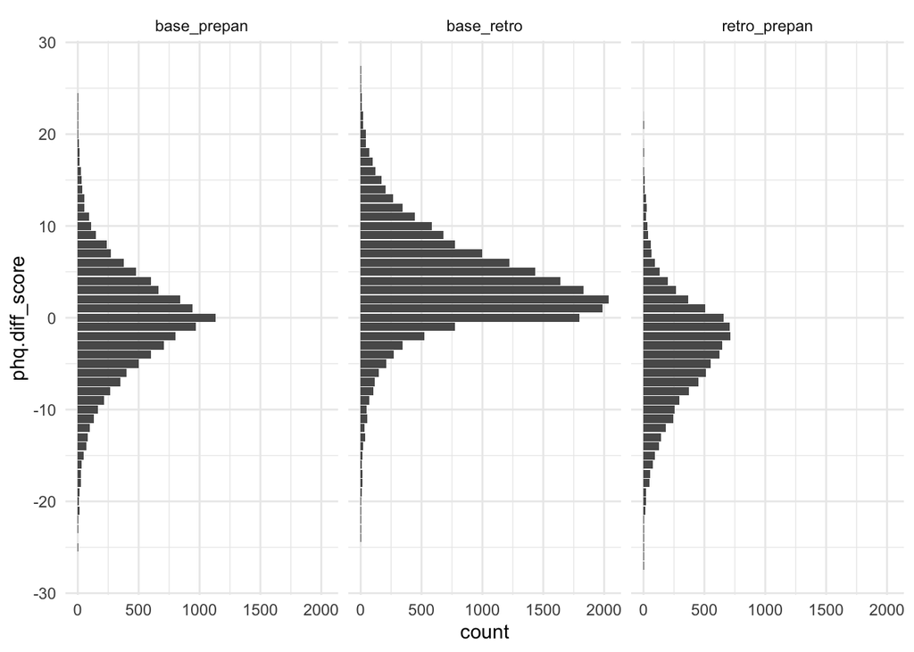

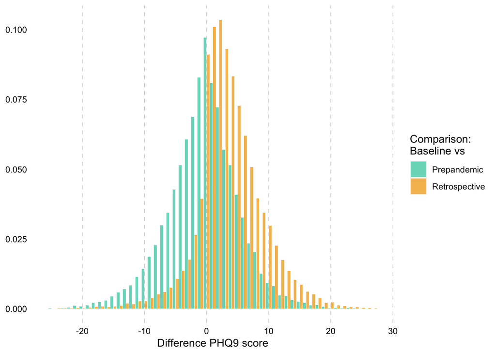

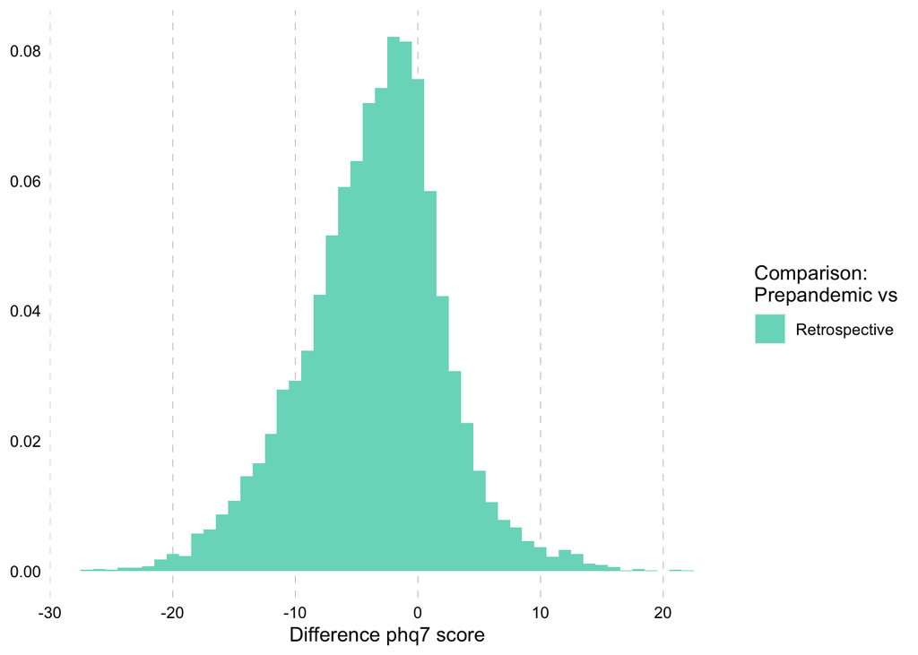

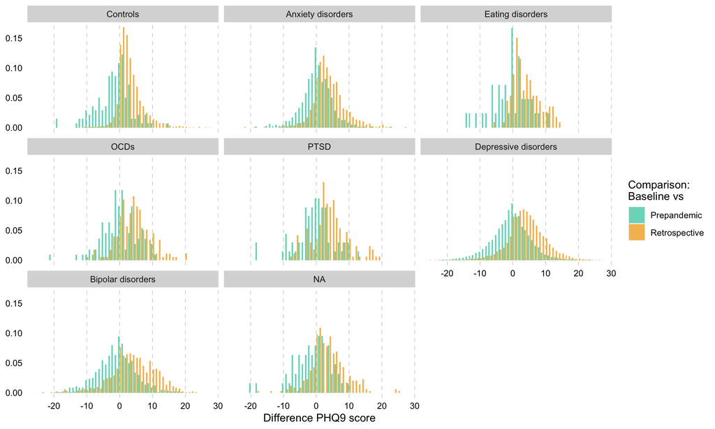

### Plots sum

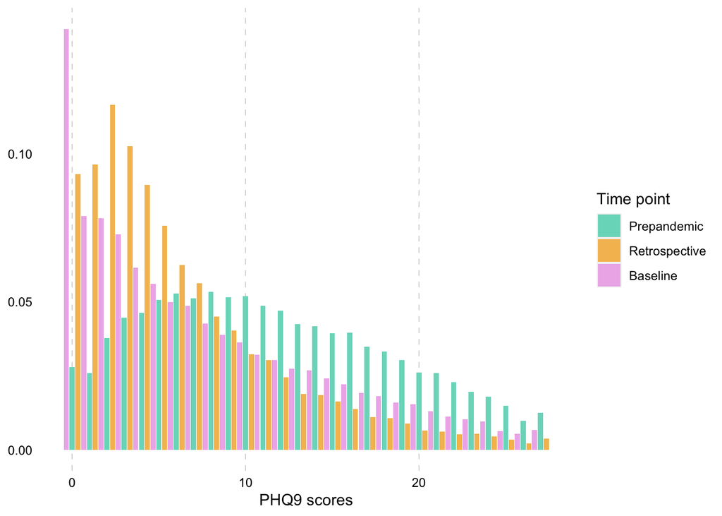

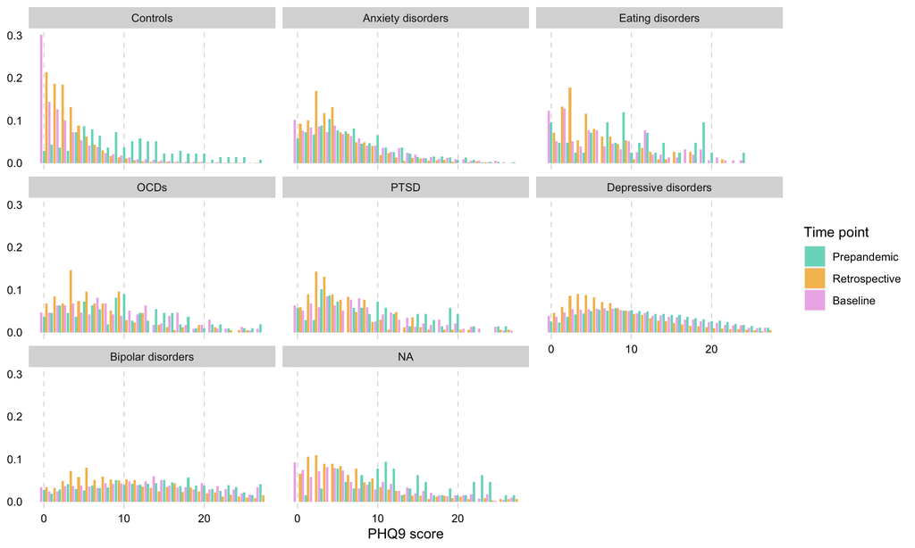

## ocir

### Summary scores

| ocir.change_binary | Prepan_mean | Base_mean | Retro_mean | Prepan_sd | Base_sd | Retro_sd | Prepan_median | Base_median | Retro_median | Prepan_min | Base_min | Retro_min | Prepan_max | Base_max | Retro_max | Prepan_skew | Base_skew | Retro_skew | Prepan_kurtosis | Base_kurtosis | Retro_kurtosis |
| --- | --- | --- | --- | --- | --- | --- | --- | --- | --- | --- | --- | --- | --- | --- | --- | --- | --- | --- | --- | --- | --- |
| No change | 25.43672 | 14.14024 | 17.35170 | 13.04519 | 12.29158 | 12.65999 | 24.0 | 10.5 | 15.0 | 0 | 0 | 0 | 68 | 65 | 68 | 0.6012320 | 1.4746668 | 1.1245171 | 0.001005796 | 2.1363815 | 1.25217707 |
| Worsening | 27.48611 | 17.70898 | 16.96528 | 14.15328 | 12.86033 | 12.82906 | 26.0 | 15.0 | 14.0 | 1 | 0 | 0 | 71 | 72 | 71 | 0.6260970 | 1.1394029 | 1.1034181 | -0.035356286 | 1.2209801 | 0.98303747 |
| Improvement | 27.50000 | 21.69872 | 18.08333 | 14.46452 | 14.14871 | 11.58083 | 23.5 | 18.0 | 16.5 | 10 | 0 | 0 | 55 | 72 | 58 | 0.5157999 | 0.8108321 | 0.7019637 | -1.117788443 | 0.2791119 | -0.01455729 |
| NA | 16.40014 | NaN | 17.00000 | 10.67619 | NA | NA | 14.0 | NA | 17.0 | 0 | Inf | 17 | 68 | -Inf | 17 | 1.1010942 | NA | NA | 1.316266918 | NA | NA |

| Variable | Min | Max | Mean | Median | SD | Skew | Kurtosis |
| --- | --- | --- | --- | --- | --- | --- | --- |
| Base | 0 | 72 | 17.70898 | 15 | 12.86033 | 1.139403 | 1.22098007 |
| Prepan | 1 | 71 | 27.48611 | 26 | 14.15328 | 0.626097 | -0.03535629 |
| Retro | 0 | 71 | 16.96528 | 14 | 12.82906 | 1.103418 | 0.98303747 |

Table for knitting ocir sum score summary table

| Variable | Min | Max | Mean | Median | SD | Skew | Kurtosis |
| --- | --- | --- | --- | --- | --- | --- | --- |
| Base | 0 | 72 | 17.70898 | 15 | 12.86033 | 1.139403 | 1.2209801 |
| Prepan | 1 | 71 | 27.48611 | 26 | 14.15328 | 0.626097 | -0.0353563 |
| Retro | 0 | 71 | 16.96528 | 14 | 12.82906 | 1.103418 | 0.9830375 |

### Differences scores

| Base - prepan_mean | Base - retro_mean | Prepan - retro_mean | Base - prepan_sd | Base - retro_sd | Prepan - retro_sd | Base - prepan_median | Base - retro_median | Prepan - retro_median | Base - prepan_min | Base - retro_min | Prepan - retro_min | Base - prepan_max | Base - retro_max | Prepan - retro_max | Base - prepan_skew | Base - retro_skew | Prepan - retro_skew | Base - prepan_kurtosis | Base - retro_kurtosis | Prepan - retro_kurtosis |
| --- | --- | --- | --- | --- | --- | --- | --- | --- | --- | --- | --- | --- | --- | --- | --- | --- | --- | --- | --- | --- |
| -8.04185 | 0.8412626 | -3.515716 | 10.76092 | 9.624354 | 9.314158 | -7 | 0 | -3 | -40 | -44 | -30 | 34 | 72 | 27 | -0.1105825 | 0.2952616 | -0.05931387 | 0.6667169 | 2.526911 | 0.3705987 |

| Variable | Min | Max | Mean | Median | SD | Skew | Kurtosis |
| --- | --- | --- | --- | --- | --- | --- | --- |
| Base - prepan | -40 | 34 | -8.0418502 | -7 | 10.760918 | -0.11058248 | 0.6667169 |
| Base - retro | -44 | 72 | 0.8412626 | 0 | 9.624354 | 0.29526155 | 2.5269113 |
| Prepan - retro | -30 | 27 | -3.5157159 | -3 | 9.314158 | -0.05931387 | 0.3705987 |

Table for knitting ocir diff summary table

| Variable | Min | Max | Mean | Median | SD | Skew | Kurtosis |
| --- | --- | --- | --- | --- | --- | --- | --- |
| Base - prepan | -40 | 34 | -8.0418502 | -7 | 10.760918 | -0.1105825 | 0.6667169 |
| Base - retro | -44 | 72 | 0.8412626 | 0 | 9.624354 | 0.2952616 | 2.5269113 |
| Prepan - retro | -30 | 27 | -3.5157159 | -3 | 9.314158 | -0.0593139 | 0.3705987 |

### Long format

|  | ID | Sample | Gender_collapsed | Ethnicity_collapsed | Disorder_hierarchical | ocir.diff_score | Time_point |
| --- | --- | --- | --- | --- | --- | --- | --- |
| 1 | 8 | GLAD | Male | European | Depressive disorders | NA | retro_prepan |
| 2 | 10 | GLAD | Female | European | Depressive disorders | NA | retro_prepan |
| 3 | 11 | GLAD | Male | European | Depressive disorders | NA | retro_prepan |
| 4 | 13 | GLAD | Female | European | Depressive disorders | NA | retro_prepan |
| 5 | 15 | GLAD | Female | European | Depressive disorders | NA | retro_prepan |
| 6 | 20 | GLAD | Female | European | Depressive disorders | NA | retro_prepan |

|  | ID | Sample | Gender_collapsed | Ethnicity_collapsed | Disorder_hierarchical | ocir.sum_score | Time_point |
| --- | --- | --- | --- | --- | --- | --- | --- |
| 1 | 8 | GLAD | Male | European | Depressive disorders | NA | prepan |
| 2 | 10 | GLAD | Female | European | Depressive disorders | NA | prepan |
| 3 | 11 | GLAD | Male | European | Depressive disorders | NA | prepan |
| 4 | 13 | GLAD | Female | European | Depressive disorders | NA | prepan |
| 5 | 15 | GLAD | Female | European | Depressive disorders | NA | prepan |
| 6 | 20 | GLAD | Female | European | Depressive disorders | NA | prepan |

### Plots

makes this into percentages

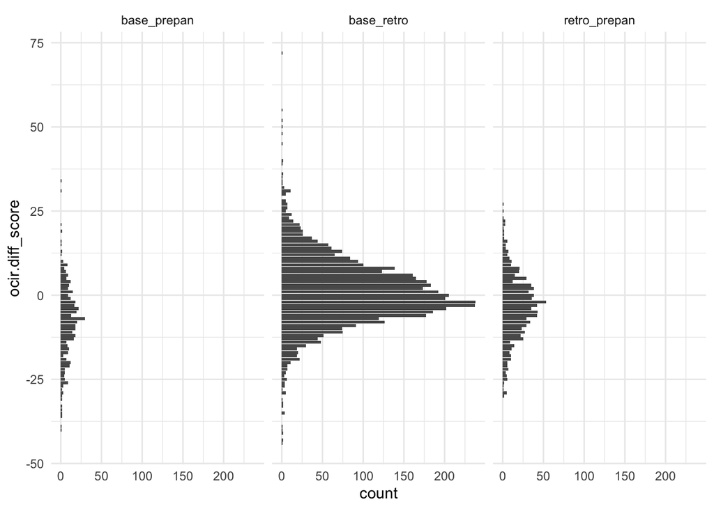

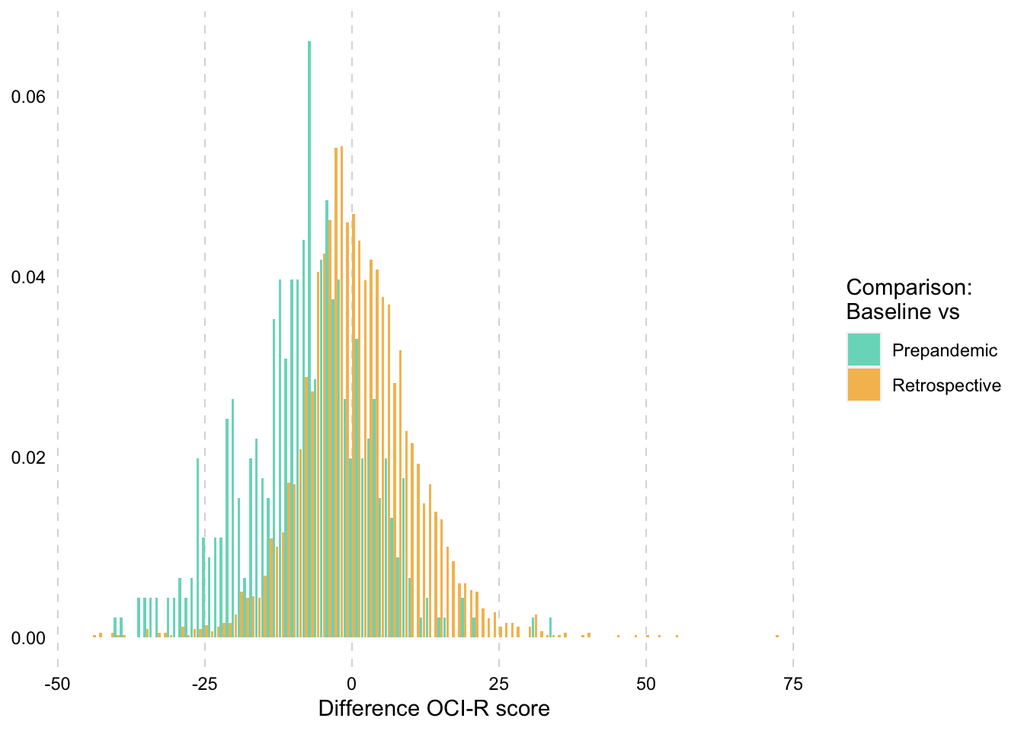

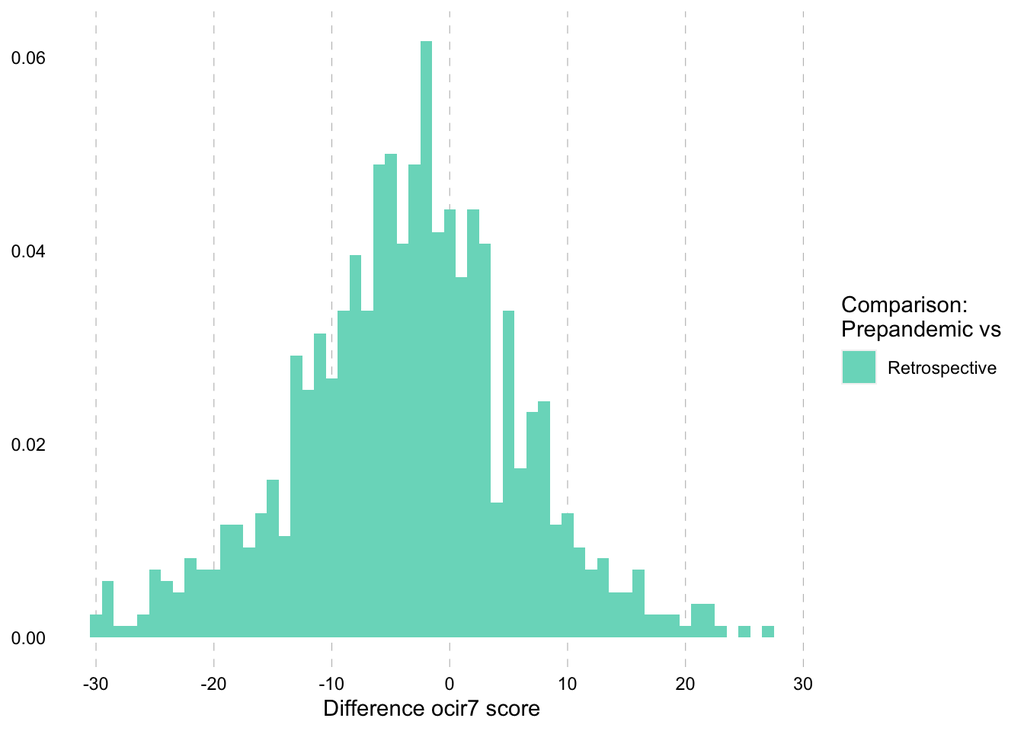

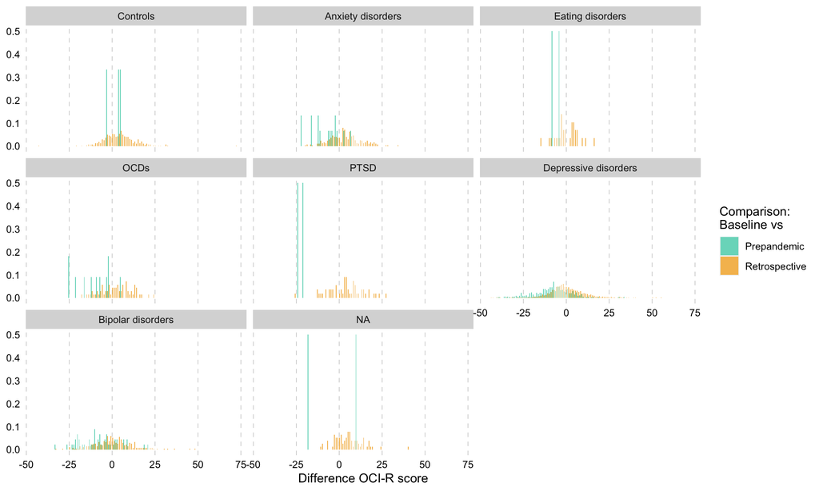

### Plots sum

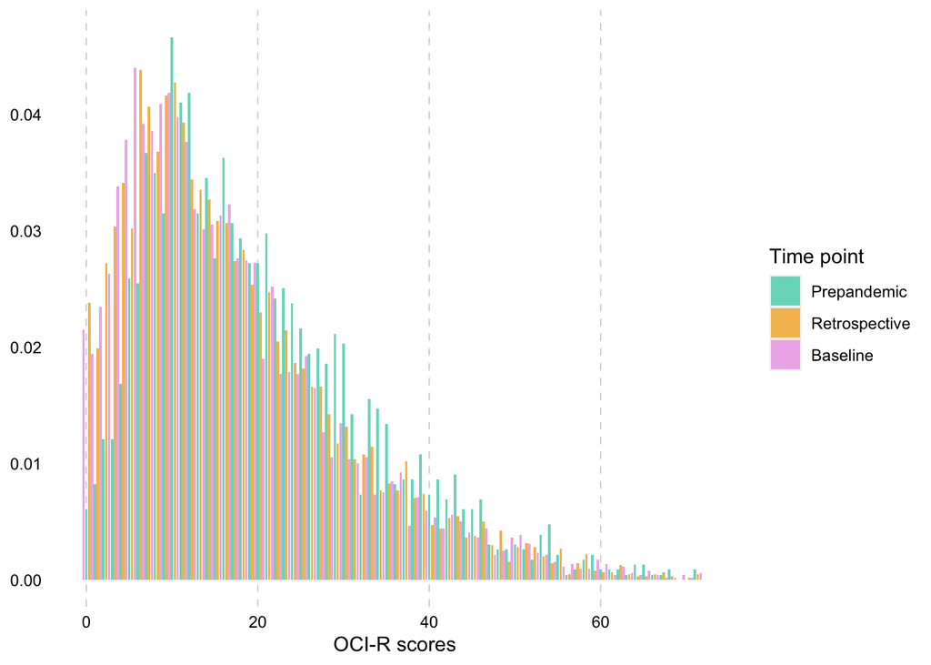

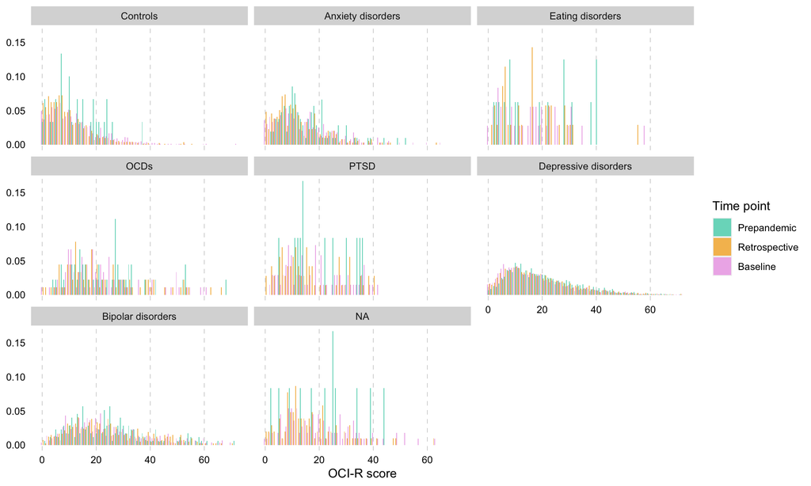

++CH: Rank the disorders by the size of the change

PCL: Calculate the total GLAD, COPING, RAMP baseline ## PCL

| Base - prepan_mean | Base - prepan_sd | Base - prepan_median | Base - prepan_min | Base - prepan_max | Base - prepan_skew | Base - prepan_kurtosis |
| --- | --- | --- | --- | --- | --- | --- |
| 0.2071534 | 5.67056 | 0 | -23 | 24 | -0.0764891 | 0.6525103 |

| Variable | Min | Max | Mean | Median | SD | Skew | Kurtosis |
| --- | --- | --- | --- | --- | --- | --- | --- |
| Base - prepan | -23 | 24 | 0.2071534 | 0 | 5.67056 | -0.0764891 | 0.6525103 |

| Variable | Min | Max | Mean | Median | SD | Skew | Kurtosis |
| --- | --- | --- | --- | --- | --- | --- | --- |
| Base - prepan | -23 | 24 | 0.2071534 | 0 | 5.67056 | -0.0764891 | 0.6525103 |

| Base - prepan_mean | Base - prepan_sd | Base - prepan_median | Base - prepan_min | Base - prepan_max | Base - prepan_skew | Base - prepan_kurtosis |
| --- | --- | --- | --- | --- | --- | --- |
| 0.2071534 | 5.67056 | 0 | -23 | 24 | -0.0764891 | 0.6525103 |

| Variable | Min | Max | Mean | Median | SD | Skew | Kurtosis |
| --- | --- | --- | --- | --- | --- | --- | --- |
| Base | 6 | 30 | 12.30834 | 11 | 6.040565 | 0.9417553 | -0.002231813 |
| Prepan | 6 | 30 | 15.63191 | 15 | 6.122545 | 0.3803556 | -0.740488580 |

| Variable | Min | Max | Mean | Median | SD | Skew | Kurtosis |
| --- | --- | --- | --- | --- | --- | --- | --- |
| Base | 6 | 30 | 12.30834 | 11 | 6.040565 | 0.9417553 | -0.0022318 |
| Prepan | 6 | 30 | 15.63191 | 15 | 6.122545 | 0.3803556 | -0.7404886 |

|  | ID | Sample | Gender_collapsed | Ethnicity_collapsed | Disorder_hierarchical | pcl.sum_score | Time_point |
| --- | --- | --- | --- | --- | --- | --- | --- |
| 1 | 8 | GLAD | Male | European | Depressive disorders | 18 | prepan |
| 2 | 10 | GLAD | Female | European | Depressive disorders | 22 | prepan |
| 3 | 11 | GLAD | Male | European | Depressive disorders | 11 | prepan |
| 4 | 13 | GLAD | Female | European | Depressive disorders | 15 | prepan |
| 5 | 15 | GLAD | Female | European | Depressive disorders | 16 | prepan |
| 6 | 20 | GLAD | Female | European | Depressive disorders | 16 | prepan |

For each item present percentages of how say that this is due to the pandemic

| PCL Item | Binary_score | n | prop | n_prop |
| --- | --- | --- | --- | --- |
| pcl.cut_people_feeling_distant_retro_numeric | 0 | 5905 | 18.7 | 5905 (18.7%) |
| pcl.cut_people_feeling_distant_retro_numeric | 1 | 15261 | 48.2 | 15261 (48.2%) |
| pcl.cut_people_feeling_distant_retro_numeric | Missing | 10490 | 33.1 | 10490 (33.1%) |
| pcl.difficulty_concentrating_retro_numeric | 0 | 9809 | 31.0 | 9809 (31%) |
| pcl.difficulty_concentrating_retro_numeric | 1 | 10191 | 32.2 | 10191 (32.2%) |
| pcl.difficulty_concentrating_retro_numeric | Missing | 11656 | 36.8 | 11656 (36.8%) |
| pcl.feeling_irritable_or_having_angry_outbursts_retro_numeric | 0 | 8651 | 27.3 | 8651 (27.3%) |
| pcl.feeling_irritable_or_having_angry_outbursts_retro_numeric | 1 | 9777 | 30.9 | 9777 (30.9%) |
| pcl.feeling_irritable_or_having_angry_outbursts_retro_numeric | Missing | 13228 | 41.8 | 13228 (41.8%) |
| pcl.stressful_experience_repeated_images_retro_numeric | 0 | 12974 | 41.0 | 12974 (41%) |
| pcl.stressful_experience_repeated_images_retro_numeric | 1 | 2867 | 9.1 | 2867 (9.1%) |
| pcl.stressful_experience_repeated_images_retro_numeric | Missing | 15815 | 50.0 | 15815 (50%) |
| pcl.stressful_experience_upset_reminded_retro_numeric | 0 | 13704 | 43.3 | 13704 (43.3%) |
| pcl.stressful_experience_upset_reminded_retro_numeric | 1 | 3698 | 11.7 | 3698 (11.7%) |
| pcl.stressful_experience_upset_reminded_retro_numeric | Missing | 14254 | 45.0 | 14254 (45%) |
| pcl.stressful_situation_avoiding_activities_retro_numeric | 0 | 9027 | 28.5 | 9027 (28.5%) |
| pcl.stressful_situation_avoiding_activities_retro_numeric | 1 | 2433 | 7.7 | 2433 (7.7%) |
| pcl.stressful_situation_avoiding_activities_retro_numeric | Missing | 20196 | 63.8 | 20196 (63.8%) |

| PCL Item | Binary_score | n | prop | n_prop |
| --- | --- | --- | --- | --- |
| pcl.cut_people_feeling_distant_retro_numeric | 0 | 5905 | 18.7 | 5905 (18.7%) |
| pcl.cut_people_feeling_distant_retro_numeric | 1 | 15261 | 48.2 | 15261 (48.2%) |
| pcl.cut_people_feeling_distant_retro_numeric | Missing | 10490 | 33.1 | 10490 (33.1%) |
| pcl.difficulty_concentrating_retro_numeric | 0 | 9809 | 31.0 | 9809 (31%) |
| pcl.difficulty_concentrating_retro_numeric | 1 | 10191 | 32.2 | 10191 (32.2%) |
| pcl.difficulty_concentrating_retro_numeric | Missing | 11656 | 36.8 | 11656 (36.8%) |
| pcl.feeling_irritable_or_having_angry_outbursts_retro_numeric | 0 | 8651 | 27.3 | 8651 (27.3%) |
| pcl.feeling_irritable_or_having_angry_outbursts_retro_numeric | 1 | 9777 | 30.9 | 9777 (30.9%) |
| pcl.feeling_irritable_or_having_angry_outbursts_retro_numeric | Missing | 13228 | 41.8 | 13228 (41.8%) |
| pcl.stressful_experience_repeated_images_retro_numeric | 0 | 12974 | 41.0 | 12974 (41%) |

[output cut: 8 more lines]

### Plots sum

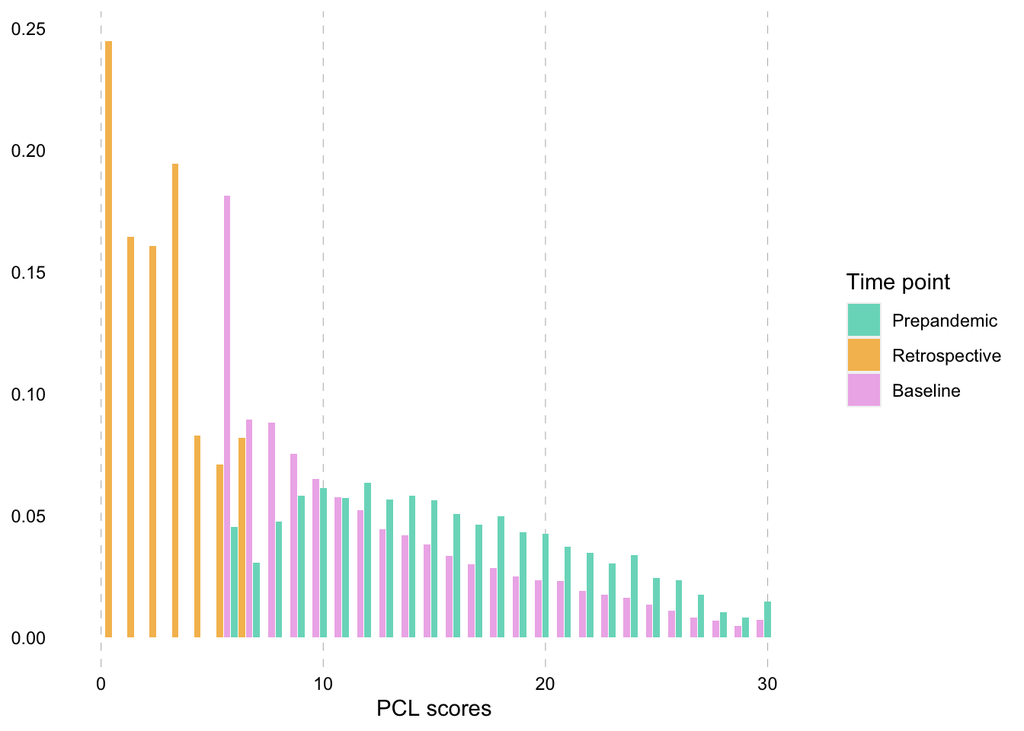

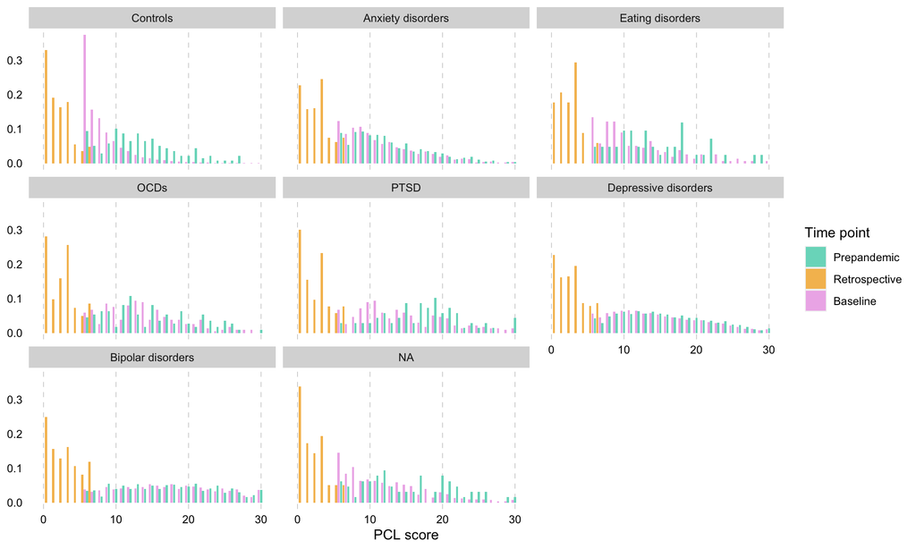

# Create subsets of data for analyses

Filter data frame to create 2 additional datasets. Additional exclusion criteria (beyond those listed above) are specified below:

1. Retrospective - baseline change anlyses
   1. Exclude individuals missing retrospective and/or baseline data
2. Prepandemic - baseline change analyses i. Exclude individuals missing pandemic and/or baseline data ii. Exclude individuals with prepandemic data collected after 1st March.

Retro-baseline analyses

```
[1] 23325   602
```

Prepan-baseline analyses Exclude individuals with NA for MHD, age, gender; exclude if prepan data collected after 1 March

```
[1] 11209   602
```

2. Regression models (Regress covariates out of the change? Which?)
   1. Model 0: Disorders
   2. Model 1: Model 0 + Sex + Age + Ethnicity + Time registration and baseline
3. Re-calculate change
4. Re-rank the change again
5. PCL:
   1. Calculate the total GLAD, COPING, RAMP baseline
   2. For each item:
      1. present percentages of how say that this is due to the pandemic
      2. Calculate a variable PCL pandemic score
      3. If one item is highly endorsed due to pandemic -> exclude in sensitivity analysis

# 2. Regression

Regress covariates out of the change? Which?

Model naming conventions: 0 - unadjusted 1 - adjusted a - hierarchical disorders b - overlapping disorder categories

++MD: We may want to exclude disorders from Model b that aren’t including in the hierarchy (e.g. ADHD, ASD)

# Functions

#GAD baseline, not controlling for prior symptoms ### Model 0a: Disorder_hierarchical, Unadjusted

| Indepent variable | Estimate | 95% CI low | 95% CI up | SE | p value |
| --- | --- | --- | --- | --- | --- |
| Intercept | 2.46 | 2.36 | 2.55 | 0.05 | 0.00e+00 |
| Anxiety disorders | 4.11 | 3.86 | 4.37 | 0.13 | 3.06e-214 |
| Eating disorders | 3.74 | 2.92 | 4.57 | 0.42 | 6.66e-19 |
| OCDs | 6.53 | 5.86 | 7.20 | 0.34 | 1.91e-80 |
| PTSD | 4.97 | 4.30 | 5.63 | 0.34 | 8.53e-48 |
| Depressive disorders | 5.75 | 5.62 | 5.87 | 0.06 | 0.00e+00 |
| Bipolar disorders | 7.42 | 7.10 | 7.74 | 0.16 | 0.00e+00 |

| Indepent variable | Estimate | 95% CI low | 95% CI up | SE | p value |
| --- | --- | --- | --- | --- | --- |
| Intercept | 2.46 | 2.36 | 2.55 | 0.05 | 0.00e+00 |
| Anxiety disorders | 4.11 | 3.86 | 4.37 | 0.13 | 3.06e-214 |
| Eating disorders | 3.74 | 2.92 | 4.57 | 0.42 | 6.66e-19 |
| OCDs | 6.53 | 5.86 | 7.20 | 0.34 | 1.91e-80 |
| PTSD | 4.97 | 4.30 | 5.63 | 0.34 | 8.53e-48 |
| Depressive disorders | 5.75 | 5.62 | 5.87 | 0.06 | 0.00e+00 |
| Bipolar disorders | 7.42 | 7.10 | 7.74 | 0.16 | 0.00e+00 |

| n | R2 | adjust. R2 | F | p value | df |
| --- | --- | --- | --- | --- | --- |
| 31111 | 0.22 | 0.22 | 1502.70 | 0.00e+00 | 6 |

| n | R2 | adjust. R2 | F | p value | df |
| --- | --- | --- | --- | --- | --- |
| 31111 | 0.22 | 0.22 | 1502.70 | 0.00e+00 | 6 |

### Model 0b: Overlapping disorders, Unadjusted

| Indepent variable | Estimate | 95% CI low | 95% CI up | SE | p value |
| --- | --- | --- | --- | --- | --- |
| Intercept | 2.64 | 2.56 | 2.73 | 0.04 | 0.00e+00 |
| Depressive and anxiety disorder | 5.64 | 5.50 | 5.77 | 0.07 | 0.00e+00 |
| Only depressive disorder | 2.09 | 1.91 | 2.26 | 0.09 | 4.31e-118 |
| Only anxiety disorder | 4.03 | 3.81 | 4.26 | 0.12 | 2.25e-263 |
| Eating disorders | 1.47 | 1.23 | 1.70 | 0.12 | 6.04e-34 |
| OCDs | 1.90 | 1.67 | 2.13 | 0.12 | 5.15e-60 |
| Psychotic and bipolar disorder | 0.42 | -0.23 | 1.06 | 0.33 | 0.21 |
| Only psychotic disorder | 0.39 | -0.16 | 0.94 | 0.28 | 0.16 |
| Only bipolar disorder | 0.48 | 0.14 | 0.83 | 0.18 | 0.006 |
| PTSD | 1.57 | 1.36 | 1.78 | 0.11 | 1.09e-48 |
| ASD | 2.18 | 1.77 | 2.59 | 0.21 | 3.28e-25 |
| ADHD | 1.16 | 0.61 | 1.70 | 0.28 | 2.99e-05 |
| Personality disorder | 2.19 | 1.89 | 2.50 | 0.15 | 6.52e-46 |

| Indepent variable | Estimate | 95% CI low | 95% CI up | SE | p value |
| --- | --- | --- | --- | --- | --- |
| Intercept | 2.64 | 2.56 | 2.73 | 0.04 | 0.00e+00 |
| Depressive and anxiety disorder | 5.64 | 5.50 | 5.77 | 0.07 | 0.00e+00 |
| Only depressive disorder | 2.09 | 1.91 | 2.26 | 0.09 | 4.31e-118 |
| Only anxiety disorder | 4.03 | 3.81 | 4.26 | 0.12 | 2.25e-263 |
| Eating disorders | 1.47 | 1.23 | 1.70 | 0.12 | 6.04e-34 |
| OCDs | 1.90 | 1.67 | 2.13 | 0.12 | 5.15e-60 |
| Psychotic and bipolar disorder | 0.42 | -0.23 | 1.06 | 0.33 | 0.21 |
| Only psychotic disorder | 0.39 | -0.16 | 0.94 | 0.28 | 0.16 |
| Only bipolar disorder | 0.48 | 0.14 | 0.83 | 0.18 | 0.006 |
| PTSD | 1.57 | 1.36 | 1.78 | 0.11 | 1.09e-48 |

[output cut: 3 more lines]

[output not shown]

[output not shown]

### Model 1a: Disorder hierarchical, Adjusted

Model 0a + Gender_collapsed + age_category_collapsed + Ethnicity_collapsed + Time registration and baseline

| Indepent variable | Estimate | 95% CI low | 95% CI up | SE | p value |
| --- | --- | --- | --- | --- | --- |
| Intercept | 9.01 | 8.58 | 9.44 | 0.22 | 0.00e+00 |
| Anxiety disorders | 2.96 | 2.70 | 3.22 | 0.13 | 1.06e-108 |
| Eating disorders | 2.09 | 1.28 | 2.90 | 0.42 | 4.97e-07 |
| OCDs | 4.00 | 3.34 | 4.67 | 0.34 | 2.38e-32 |
| PTSD | 3.95 | 3.28 | 4.62 | 0.34 | 5.91e-31 |
| Depressive disorders | 4.53 | 4.39 | 4.67 | 0.07 | 0.00e+00 |
| Bipolar disorders | 6.10 | 5.79 | 6.42 | 0.16 | 4.54e-301 |
| Female | 0.97 | 0.83 | 1.11 | 0.07 | 9.95e-42 |
| Non-binary/Self-defined | 1.59 | 1.02 | 2.15 | 0.29 | 3.51e-08 |
| 19-25 years | -1.42 | -1.83 | -1.02 | 0.21 | 7.49e-12 |
| 26-35 years | -3.16 | -3.54 | -2.78 | 0.19 | 2.92e-59 |
| 36-45 years | -4.01 | -4.39 | -3.63 | 0.20 | 8.85e-93 |
| 46-55 years | -4.73 | -5.10 | -4.36 | 0.19 | 3.83e-134 |
| 56-65 years | -5.76 | -6.13 | -5.39 | 0.19 | 2.65e-198 |
| 66-70 years | -6.75 | -7.15 | -6.34 | 0.21 | 4.16e-231 |
| 71-75 years | -6.92 | -7.35 | -6.49 | 0.22 | 1.71e-215 |
| 76+ years | -6.84 | -7.38 | -6.29 | 0.28 | 7.62e-132 |
| Mixed or multiple ethnic origins | 0.03 | -0.42 | 0.48 | 0.23 | 0.91 |
| Asian or Asian British | -0.36 | -0.91 | 0.19 | 0.28 | 0.20 |
| African or African British | -0.28 | -1.21 | 0.64 | 0.47 | 0.55 |
| Other ethnicity | 0.90 | 0.06 | 1.73 | 0.42 | 0.03 |
| Time difference: Lockdown to baseline | -0.26 | -0.30 | -0.23 | 0.02 | 1.69e-61 |

| Indepent variable | Estimate | 95% CI low | 95% CI up | SE | p value |
| --- | --- | --- | --- | --- | --- |
| Intercept | 9.01 | 8.58 | 9.44 | 0.22 | 0.00e+00 |
| Anxiety disorders | 2.96 | 2.70 | 3.22 | 0.13 | 1.06e-108 |
| Eating disorders | 2.09 | 1.28 | 2.90 | 0.42 | 4.97e-07 |
| OCDs | 4.00 | 3.34 | 4.67 | 0.34 | 2.38e-32 |
| PTSD | 3.95 | 3.28 | 4.62 | 0.34 | 5.91e-31 |
| Depressive disorders | 4.53 | 4.39 | 4.67 | 0.07 | 0.00e+00 |
| Bipolar disorders | 6.10 | 5.79 | 6.42 | 0.16 | 4.54e-301 |
| Female | 0.97 | 0.83 | 1.11 | 0.07 | 9.95e-42 |
| Non-binary/Self-defined | 1.59 | 1.02 | 2.15 | 0.29 | 3.51e-08 |
| 19-25 years | -1.42 | -1.83 | -1.02 | 0.21 | 7.49e-12 |

[output cut: 12 more lines]

[output not shown]

[output not shown]

### Model 1b: Overlapping disorders, Adjusted

| Indepent variable | Estimate | 95% CI low | 95% CI up | SE | p value |
| --- | --- | --- | --- | --- | --- |
| Intercept | 9.02 | 8.62 | 9.42 | 0.21 | 0.00e+00 |
| Depressive and anxiety disorder | 4.62 | 4.47 | 4.76 | 0.07 | 0.00e+00 |
| Only depressive disorder | 1.82 | 1.64 | 2.00 | 0.09 | 5.55e-84 |
| Only anxiety disorder | 3.06 | 2.83 | 3.29 | 0.12 | 1.03e-144 |
| Eating disorders | 0.92 | 0.68 | 1.15 | 0.12 | 1.41e-14 |
| OCDs | 1.41 | 1.19 | 1.64 | 0.11 | 4.12e-35 |
| Psychotic and bipolar disorder | 0.75 | 0.12 | 1.38 | 0.32 | 0.02 |
| Only psychotic disorder | 0.54 | 0.00 | 1.08 | 0.27 | 0.05 |
| Only bipolar disorder | 0.67 | 0.33 | 1.01 | 0.17 | 1.07e-04 |
| PTSD | 1.59 | 1.38 | 1.80 | 0.11 | 6.91e-51 |
| ASD | 1.30 | 0.90 | 1.71 | 0.21 | 3.56e-10 |
| ADHD | 0.44 | -0.10 | 0.97 | 0.27 | 0.11 |
| Personality disorder | 1.81 | 1.51 | 2.11 | 0.15 | 8.55e-33 |
| Female | 0.91 | 0.77 | 1.04 | 0.07 | 1.08e-39 |
| Non-binary/Self-defined | 0.69 | 0.15 | 1.23 | 0.28 | 0.01 |
| 19-25 years | -1.65 | -2.03 | -1.27 | 0.19 | 2.40e-17 |
| 26-35 years | -3.25 | -3.61 | -2.90 | 0.18 | 1.76e-70 |
| 36-45 years | -3.91 | -4.27 | -3.54 | 0.18 | 1.70e-98 |
| 46-55 years | -4.42 | -4.77 | -4.07 | 0.18 | 5.50e-131 |
| 56-65 years | -5.29 | -5.64 | -4.94 | 0.18 | 1.01e-189 |
| 66-70 years | -6.25 | -6.63 | -5.87 | 0.19 | 9.52e-225 |
| 71-75 years | -6.43 | -6.83 | -6.03 | 0.21 | 2.87e-210 |
| 76+ years | -6.31 | -6.82 | -5.79 | 0.26 | 4.22e-126 |
| Mixed or multiple ethnic origins | 0.08 | -0.35 | 0.51 | 0.22 | 0.71 |
| Asian or Asian British | 0.10 | -0.42 | 0.61 | 0.26 | 0.72 |
| African or African British | -0.20 | -1.08 | 0.68 | 0.45 | 0.66 |
| Other ethnicity | 0.68 | -0.11 | 1.47 | 0.40 | 0.09 |
| key_worker_numeric | -0.34 | -0.47 | -0.22 | 0.06 | 5.56e-08 |
| Time difference: Lockdown to baseline | -0.28 | -0.31 | -0.25 | 0.02 | 1.55e-73 |

| Indepent variable | Estimate | 95% CI low | 95% CI up | SE | p value |
| --- | --- | --- | --- | --- | --- |
| Intercept | 9.02 | 8.62 | 9.42 | 0.21 | 0.00e+00 |
| Depressive and anxiety disorder | 4.62 | 4.47 | 4.76 | 0.07 | 0.00e+00 |
| Only depressive disorder | 1.82 | 1.64 | 2.00 | 0.09 | 5.55e-84 |
| Only anxiety disorder | 3.06 | 2.83 | 3.29 | 0.12 | 1.03e-144 |
| Eating disorders | 0.92 | 0.68 | 1.15 | 0.12 | 1.41e-14 |
| OCDs | 1.41 | 1.19 | 1.64 | 0.11 | 4.12e-35 |
| Psychotic and bipolar disorder | 0.75 | 0.12 | 1.38 | 0.32 | 0.02 |
| Only psychotic disorder | 0.54 | 0.00 | 1.08 | 0.27 | 0.05 |
| Only bipolar disorder | 0.67 | 0.33 | 1.01 | 0.17 | 1.07e-04 |
| PTSD | 1.59 | 1.38 | 1.80 | 0.11 | 6.91e-51 |

[output cut: 19 more lines]

[output not shown]

[output not shown]

# GAD prepan

## Regression: Change scores

### Model 0a: Disorder_hierarchical, Unadjusted

| Indepent variable | Estimate | 95% CI low | 95% CI up | SE | p value |
| --- | --- | --- | --- | --- | --- |
| Intercept | -1.16 | -2.09 | -0.22 | 0.48 | 0.02 |
| Anxiety disorders | 0.16 | -0.88 | 1.19 | 0.53 | 0.77 |
| Eating disorders | -0.59 | -2.64 | 1.47 | 1.05 | 0.58 |
| OCDs | -0.15 | -1.56 | 1.25 | 0.72 | 0.83 |
| PTSD | -0.09 | -1.73 | 1.55 | 0.83 | 0.91 |
| Depressive disorders | 0.85 | -0.09 | 1.79 | 0.48 | 0.08 |
| Bipolar disorders | 0.81 | -0.20 | 1.83 | 0.52 | 0.12 |

| Indepent variable | Estimate | 95% CI low | 95% CI up | SE | p value |
| --- | --- | --- | --- | --- | --- |
| Intercept | -1.16 | -2.09 | -0.22 | 0.48 | 0.02 |
| Anxiety disorders | 0.16 | -0.88 | 1.19 | 0.53 | 0.77 |
| Eating disorders | -0.59 | -2.64 | 1.47 | 1.05 | 0.58 |
| OCDs | -0.15 | -1.56 | 1.25 | 0.72 | 0.83 |
| PTSD | -0.09 | -1.73 | 1.55 | 0.83 | 0.91 |
| Depressive disorders | 0.85 | -0.09 | 1.79 | 0.48 | 0.08 |
| Bipolar disorders | 0.81 | -0.20 | 1.83 | 0.52 | 0.12 |

| n | R2 | adjust. R2 | F | p value | df |
| --- | --- | --- | --- | --- | --- |
| 11123 | 0.00 | 0.00 | 3.14 | 0.004 | 6 |

| n | R2 | adjust. R2 | F | p value | df |
| --- | --- | --- | --- | --- | --- |
| 11123 | 0.00 | 0.00 | 3.14 | 0.004 | 6 |

### Model 0b: Overlapping disorders, Unadjusted

| Indepent variable | Estimate | 95% CI low | 95% CI up | SE | p value |
| --- | --- | --- | --- | --- | --- |
| Intercept | -0.83 | -1.51 | -0.16 | 0.34 | 0.02 |
| Depressive and anxiety disorder | 0.45 | -0.24 | 1.13 | 0.35 | 0.20 |
| Only depressive disorder | 0.98 | 0.24 | 1.71 | 0.38 | 0.010 |
| Only anxiety disorder | -0.27 | -1.05 | 0.51 | 0.40 | 0.49 |
| Eating disorders | 0.17 | -0.16 | 0.51 | 0.17 | 0.30 |
| OCDs | -0.25 | -0.56 | 0.07 | 0.16 | 0.12 |
| Psychotic and bipolar disorder | -0.51 | -1.42 | 0.40 | 0.46 | 0.27 |
| Only psychotic disorder | 0.76 | 0.00 | 1.52 | 0.39 | 0.05 |
| Only bipolar disorder | 0.21 | -0.24 | 0.66 | 0.23 | 0.36 |
| PTSD | 0.14 | -0.16 | 0.43 | 0.15 | 0.36 |
| ASD | 0.16 | -0.44 | 0.77 | 0.31 | 0.60 |
| ADHD | -0.77 | -1.60 | 0.05 | 0.42 | 0.07 |
| Personality disorder | -0.17 | -0.57 | 0.24 | 0.21 | 0.43 |

| Indepent variable | Estimate | 95% CI low | 95% CI up | SE | p value |
| --- | --- | --- | --- | --- | --- |
| Intercept | -0.83 | -1.51 | -0.16 | 0.34 | 0.02 |
| Depressive and anxiety disorder | 0.45 | -0.24 | 1.13 | 0.35 | 0.20 |
| Only depressive disorder | 0.98 | 0.24 | 1.71 | 0.38 | 0.010 |
| Only anxiety disorder | -0.27 | -1.05 | 0.51 | 0.40 | 0.49 |
| Eating disorders | 0.17 | -0.16 | 0.51 | 0.17 | 0.30 |
| OCDs | -0.25 | -0.56 | 0.07 | 0.16 | 0.12 |
| Psychotic and bipolar disorder | -0.51 | -1.42 | 0.40 | 0.46 | 0.27 |
| Only psychotic disorder | 0.76 | 0.00 | 1.52 | 0.39 | 0.05 |
| Only bipolar disorder | 0.21 | -0.24 | 0.66 | 0.23 | 0.36 |
| PTSD | 0.14 | -0.16 | 0.43 | 0.15 | 0.36 |

[output cut: 3 more lines]

[output not shown]

[output not shown]

### Model 1a: Disorder hierarchical, Adjusted

Model 0a + Gender_collapsed + age_category_collapsed + Ethnicity_collapsed + Time registration and baseline

| Indepent variable | Estimate | 95% CI low | 95% CI up | SE | p value |
| --- | --- | --- | --- | --- | --- |
| Intercept | -1.91 | -3.16 | -0.67 | 0.63 | 0.003 |
| Anxiety disorders | 0.09 | -0.95 | 1.12 | 0.53 | 0.87 |
| Eating disorders | -0.75 | -2.80 | 1.31 | 1.05 | 0.48 |
| OCDs | -0.27 | -1.68 | 1.14 | 0.72 | 0.71 |
| PTSD | -0.25 | -1.90 | 1.40 | 0.84 | 0.76 |
| Depressive disorders | 0.74 | -0.20 | 1.69 | 0.48 | 0.12 |
| Bipolar disorders | 0.76 | -0.26 | 1.78 | 0.52 | 0.14 |
| Female | 0.50 | 0.22 | 0.77 | 0.14 | 4.50e-04 |
| Non-binary/Self-defined | 0.43 | -0.36 | 1.23 | 0.40 | 0.28 |
| 19-25 years | 0.53 | -0.16 | 1.22 | 0.35 | 0.14 |
| 26-35 years | 0.48 | -0.19 | 1.14 | 0.34 | 0.16 |
| 36-45 years | 0.65 | -0.02 | 1.32 | 0.34 | 0.06 |
| 46-55 years | 0.46 | -0.21 | 1.13 | 0.34 | 0.18 |
| 56-65 years | 0.65 | -0.04 | 1.34 | 0.35 | 0.06 |
| 66-70 years | 0.26 | -0.59 | 1.11 | 0.43 | 0.55 |
| 71-75 years | 0.17 | -0.83 | 1.18 | 0.51 | 0.73 |
| 76+ years | 0.92 | -0.75 | 2.59 | 0.85 | 0.28 |
| Mixed or multiple ethnic origins | 0.29 | -0.43 | 1.02 | 0.37 | 0.42 |
| Asian or Asian British | -0.39 | -1.57 | 0.78 | 0.60 | 0.51 |
| African or African British | -1.25 | -3.01 | 0.51 | 0.90 | 0.16 |
| Other ethnicity | -0.04 | -1.17 | 1.09 | 0.58 | 0.94 |
| Time difference: Lockdown to baseline | -0.01 | -0.08 | 0.06 | 0.03 | 0.78 |

| Indepent variable | Estimate | 95% CI low | 95% CI up | SE | p value |
| --- | --- | --- | --- | --- | --- |
| Intercept | -1.91 | -3.16 | -0.67 | 0.63 | 0.003 |
| Anxiety disorders | 0.09 | -0.95 | 1.12 | 0.53 | 0.87 |
| Eating disorders | -0.75 | -2.80 | 1.31 | 1.05 | 0.48 |
| OCDs | -0.27 | -1.68 | 1.14 | 0.72 | 0.71 |
| PTSD | -0.25 | -1.90 | 1.40 | 0.84 | 0.76 |
| Depressive disorders | 0.74 | -0.20 | 1.69 | 0.48 | 0.12 |
| Bipolar disorders | 0.76 | -0.26 | 1.78 | 0.52 | 0.14 |
| Female | 0.50 | 0.22 | 0.77 | 0.14 | 4.50e-04 |
| Non-binary/Self-defined | 0.43 | -0.36 | 1.23 | 0.40 | 0.28 |
| 19-25 years | 0.53 | -0.16 | 1.22 | 0.35 | 0.14 |

[output cut: 12 more lines]

[output not shown]

[output not shown]

### Model 1b: Overlapping disorders, Adjusted

Model 0a + Gender_collapsed + age_category_collapsed + Ethnicity_collapsed + Time registration and baseline

| Indepent variable | Estimate | 95% CI low | 95% CI up | SE | p value |
| --- | --- | --- | --- | --- | --- |
| Intercept | -1.63 | -2.68 | -0.58 | 0.54 | 0.002 |
| Depressive and anxiety disorder | 0.38 | -0.31 | 1.07 | 0.35 | 0.28 |
| Only depressive disorder | 0.91 | 0.16 | 1.66 | 0.38 | 0.02 |
| Only anxiety disorder | -0.33 | -1.11 | 0.46 | 0.40 | 0.41 |
| Eating disorders | 0.13 | -0.20 | 0.47 | 0.17 | 0.44 |
| OCDs | -0.25 | -0.57 | 0.06 | 0.16 | 0.11 |
| Psychotic and bipolar disorder | -0.39 | -1.31 | 0.52 | 0.47 | 0.40 |
| Only psychotic disorder | 0.79 | 0.02 | 1.55 | 0.39 | 0.04 |
| Only bipolar disorder | 0.30 | -0.16 | 0.75 | 0.23 | 0.20 |
| PTSD | 0.11 | -0.18 | 0.41 | 0.15 | 0.45 |
| ASD | 0.26 | -0.35 | 0.87 | 0.31 | 0.40 |
| ADHD | -0.76 | -1.59 | 0.07 | 0.42 | 0.07 |
| Personality disorder | -0.19 | -0.60 | 0.22 | 0.21 | 0.36 |
| Female | 0.47 | 0.19 | 0.75 | 0.14 | 0.001 |
| Non-binary/Self-defined | 0.47 | -0.32 | 1.26 | 0.40 | 0.25 |
| 19-25 years | 0.53 | -0.16 | 1.21 | 0.35 | 0.13 |
| 26-35 years | 0.47 | -0.19 | 1.13 | 0.34 | 0.16 |
| 36-45 years | 0.60 | -0.07 | 1.27 | 0.34 | 0.08 |
| 46-55 years | 0.38 | -0.28 | 1.05 | 0.34 | 0.26 |
| 56-65 years | 0.57 | -0.11 | 1.25 | 0.35 | 0.10 |
| 66-70 years | 0.17 | -0.67 | 1.01 | 0.43 | 0.69 |
| 71-75 years | 0.18 | -0.81 | 1.18 | 0.51 | 0.72 |
| 76+ years | 0.86 | -0.81 | 2.53 | 0.85 | 0.31 |
| Mixed or multiple ethnic origins | 0.29 | -0.43 | 1.01 | 0.37 | 0.43 |
| Asian or Asian British | -0.32 | -1.50 | 0.85 | 0.60 | 0.59 |
| African or African British | -1.18 | -2.94 | 0.58 | 0.90 | 0.19 |
| Other ethnicity | -0.15 | -1.26 | 0.96 | 0.57 | 0.79 |
| key_worker_numeric | 0.18 | -0.04 | 0.39 | 0.11 | 0.11 |
| Time difference: Lockdown to baseline | -0.01 | -0.08 | 0.06 | 0.03 | 0.75 |

| Indepent variable | Estimate | 95% CI low | 95% CI up | SE | p value |
| --- | --- | --- | --- | --- | --- |
| Intercept | -1.63 | -2.68 | -0.58 | 0.54 | 0.002 |
| Depressive and anxiety disorder | 0.38 | -0.31 | 1.07 | 0.35 | 0.28 |
| Only depressive disorder | 0.91 | 0.16 | 1.66 | 0.38 | 0.02 |
| Only anxiety disorder | -0.33 | -1.11 | 0.46 | 0.40 | 0.41 |
| Eating disorders | 0.13 | -0.20 | 0.47 | 0.17 | 0.44 |
| OCDs | -0.25 | -0.57 | 0.06 | 0.16 | 0.11 |
| Psychotic and bipolar disorder | -0.39 | -1.31 | 0.52 | 0.47 | 0.40 |
| Only psychotic disorder | 0.79 | 0.02 | 1.55 | 0.39 | 0.04 |
| Only bipolar disorder | 0.30 | -0.16 | 0.75 | 0.23 | 0.20 |
| PTSD | 0.11 | -0.18 | 0.41 | 0.15 | 0.45 |

[output cut: 19 more lines]

| n | R2 | adjust. R2 | F | p value | df |
| --- | --- | --- | --- | --- | --- |
| 11123 | 0.00 | 0.00 | 3.14 | 0.004 | 6 |

| n | R2 | adjust. R2 | F | p value | df |
| --- | --- | --- | --- | --- | --- |
| 11123 | 0.00 | 0.00 | 3.14 | 0.004 | 6 |

## Regression: Absolute scores

### Model 0a: Disorder_hierarchical, Unadjusted

| Indepent variable | Estimate | 95% CI low | 95% CI up | SE | p value |
| --- | --- | --- | --- | --- | --- |
| Intercept | 2.25 | 1.43 | 3.07 | 0.42 | 9.06e-08 |
| gad.sum_score_prepan | 0.55 | 0.53 | 0.56 | 0.01 | 0.00e+00 |
| Anxiety disorders | 0.56 | -0.34 | 1.46 | 0.46 | 0.22 |
| Eating disorders | 0.74 | -1.05 | 2.54 | 0.92 | 0.42 |
| OCDs | 1.38 | 0.15 | 2.61 | 0.63 | 0.03 |
| PTSD | 1.11 | -0.32 | 2.54 | 0.73 | 0.13 |
| Depressive disorders | 1.50 | 0.68 | 2.33 | 0.42 | 3.40e-04 |
| Bipolar disorders | 1.88 | 0.99 | 2.76 | 0.45 | 3.29e-05 |

| Indepent variable | Estimate | 95% CI low | 95% CI up | SE | p value |
| --- | --- | --- | --- | --- | --- |
| Intercept | 2.25 | 1.43 | 3.07 | 0.42 | 9.06e-08 |
| gad.sum_score_prepan | 0.55 | 0.53 | 0.56 | 0.01 | 0.00e+00 |
| Anxiety disorders | 0.56 | -0.34 | 1.46 | 0.46 | 0.22 |
| Eating disorders | 0.74 | -1.05 | 2.54 | 0.92 | 0.42 |
| OCDs | 1.38 | 0.15 | 2.61 | 0.63 | 0.03 |
| PTSD | 1.11 | -0.32 | 2.54 | 0.73 | 0.13 |
| Depressive disorders | 1.50 | 0.68 | 2.33 | 0.42 | 3.40e-04 |
| Bipolar disorders | 1.88 | 0.99 | 2.76 | 0.45 | 3.29e-05 |

| n | R2 | adjust. R2 | F | p value | df |
| --- | --- | --- | --- | --- | --- |
| 11123 | 0.32 | 0.32 | 742.65 | 0.00e+00 | 7 |

| n | R2 | adjust. R2 | F | p value | df |
| --- | --- | --- | --- | --- | --- |
| 11123 | 0.32 | 0.32 | 742.65 | 0.00e+00 | 7 |

### Model 0b: Overlapping disorders, Unadjusted

| Indepent variable | Estimate | 95% CI low | 95% CI up | SE | p value |
| --- | --- | --- | --- | --- | --- |
| Intercept | 2.97 | 2.38 | 3.57 | 0.30 | 1.88e-22 |
| gad.sum_score_prepan | 0.52 | 0.50 | 0.53 | 0.01 | 0.00e+00 |
| Depressive and anxiety disorder | 0.83 | 0.24 | 1.43 | 0.30 | 0.006 |
| Only depressive disorder | -0.24 | -0.88 | 0.41 | 0.33 | 0.47 |
| Only anxiety disorder | 0.08 | -0.59 | 0.76 | 0.34 | 0.81 |
| Eating disorders | 0.73 | 0.44 | 1.02 | 0.15 | 7.39e-07 |
| OCDs | 0.61 | 0.34 | 0.88 | 0.14 | 1.03e-05 |
| Psychotic and bipolar disorder | -0.52 | -1.31 | 0.27 | 0.40 | 0.19 |
| Only psychotic disorder | 0.39 | -0.27 | 1.05 | 0.34 | 0.24 |
| Only bipolar disorder | 0.18 | -0.21 | 0.58 | 0.20 | 0.36 |
| PTSD | 0.75 | 0.50 | 1.00 | 0.13 | 6.98e-09 |
| ASD | 0.91 | 0.39 | 1.43 | 0.27 | 6.49e-04 |
| ADHD | -0.18 | -0.90 | 0.53 | 0.36 | 0.62 |
| Personality disorder | 0.92 | 0.57 | 1.28 | 0.18 | 3.15e-07 |

| Indepent variable | Estimate | 95% CI low | 95% CI up | SE | p value |
| --- | --- | --- | --- | --- | --- |
| Intercept | 2.97 | 2.38 | 3.57 | 0.30 | 1.88e-22 |
| gad.sum_score_prepan | 0.52 | 0.50 | 0.53 | 0.01 | 0.00e+00 |
| Depressive and anxiety disorder | 0.83 | 0.24 | 1.43 | 0.30 | 0.006 |
| Only depressive disorder | -0.24 | -0.88 | 0.41 | 0.33 | 0.47 |
| Only anxiety disorder | 0.08 | -0.59 | 0.76 | 0.34 | 0.81 |
| Eating disorders | 0.73 | 0.44 | 1.02 | 0.15 | 7.39e-07 |
| OCDs | 0.61 | 0.34 | 0.88 | 0.14 | 1.03e-05 |
| Psychotic and bipolar disorder | -0.52 | -1.31 | 0.27 | 0.40 | 0.19 |
| Only psychotic disorder | 0.39 | -0.27 | 1.05 | 0.34 | 0.24 |
| Only bipolar disorder | 0.18 | -0.21 | 0.58 | 0.20 | 0.36 |

[output cut: 4 more lines]

| n | R2 | adjust. R2 | F | p value | df |
| --- | --- | --- | --- | --- | --- |
| 11144 | 0.01 | 0.01 | 11.20 | 1.70e-12 | 6 |

| n | R2 | adjust. R2 | F | p value | df |
| --- | --- | --- | --- | --- | --- |
| 11144 | 0.01 | 0.01 | 11.20 | 1.70e-12 | 6 |

### Model 1a: Disorder hierarchical, Adjusted

Model 0a + Gender_collapsed + age_category_collapsed + Ethnicity_collapsed + Time registration and baseline

| Indepent variable | Estimate | 95% CI low | 95% CI up | SE | p value |
| --- | --- | --- | --- | --- | --- |
| Intercept | 3.41 | 2.32 | 4.50 | 0.56 | 8.58e-10 |
| gad.sum_score_prepan | 0.52 | 0.51 | 0.54 | 0.01 | 0.00e+00 |
| Anxiety disorders | 0.53 | -0.37 | 1.42 | 0.46 | 0.25 |
| Eating disorders | 0.63 | -1.15 | 2.41 | 0.91 | 0.49 |
| OCDs | 1.14 | -0.08 | 2.36 | 0.62 | 0.07 |
| PTSD | 1.34 | -0.08 | 2.77 | 0.73 | 0.06 |
| Depressive disorders | 1.61 | 0.79 | 2.42 | 0.42 | 1.16e-04 |
| Bipolar disorders | 2.12 | 1.24 | 3.00 | 0.45 | 2.31e-06 |
| Female | 0.51 | 0.27 | 0.75 | 0.12 | 3.43e-05 |
| Non-binary/Self-defined | 0.84 | 0.15 | 1.52 | 0.35 | 0.02 |
| 19-25 years | -0.31 | -0.91 | 0.29 | 0.31 | 0.31 |
| 26-35 years | -1.07 | -1.65 | -0.50 | 0.29 | 2.70e-04 |
| 36-45 years | -1.26 | -1.84 | -0.67 | 0.30 | 2.54e-05 |
| 46-55 years | -1.58 | -2.17 | -1.00 | 0.30 | 1.01e-07 |
| 56-65 years | -2.02 | -2.62 | -1.42 | 0.31 | 4.59e-11 |
| 66-70 years | -2.95 | -3.69 | -2.21 | 0.38 | 6.47e-15 |
| 71-75 years | -3.27 | -4.15 | -2.40 | 0.44 | 1.99e-13 |
| 76+ years | -2.69 | -4.14 | -1.23 | 0.74 | 2.87e-04 |
| Mixed or multiple ethnic origins | 0.10 | -0.53 | 0.72 | 0.32 | 0.76 |
| Asian or Asian British | -0.36 | -1.37 | 0.66 | 0.52 | 0.49 |
| African or African British | -0.43 | -1.95 | 1.09 | 0.78 | 0.58 |
| Other ethnicity | 0.48 | -0.50 | 1.45 | 0.50 | 0.34 |
| Time difference: Lockdown to baseline | -0.01 | -0.07 | 0.04 | 0.03 | 0.66 |

| Indepent variable | Estimate | 95% CI low | 95% CI up | SE | p value |
| --- | --- | --- | --- | --- | --- |
| Intercept | 3.41 | 2.32 | 4.50 | 0.56 | 8.58e-10 |
| gad.sum_score_prepan | 0.52 | 0.51 | 0.54 | 0.01 | 0.00e+00 |
| Anxiety disorders | 0.53 | -0.37 | 1.42 | 0.46 | 0.25 |
| Eating disorders | 0.63 | -1.15 | 2.41 | 0.91 | 0.49 |
| OCDs | 1.14 | -0.08 | 2.36 | 0.62 | 0.07 |
| PTSD | 1.34 | -0.08 | 2.77 | 0.73 | 0.06 |
| Depressive disorders | 1.61 | 0.79 | 2.42 | 0.42 | 1.16e-04 |
| Bipolar disorders | 2.12 | 1.24 | 3.00 | 0.45 | 2.31e-06 |
| Female | 0.51 | 0.27 | 0.75 | 0.12 | 3.43e-05 |
| Non-binary/Self-defined | 0.84 | 0.15 | 1.52 | 0.35 | 0.02 |

[output cut: 13 more lines]

| n | R2 | adjust. R2 | F | p value | df |
| --- | --- | --- | --- | --- | --- |
| 11144 | 0.01 | 0.01 | 11.20 | 1.70e-12 | 6 |

| n | R2 | adjust. R2 | F | p value | df |
| --- | --- | --- | --- | --- | --- |
| 11144 | 0.01 | 0.01 | 11.20 | 1.70e-12 | 6 |

### Model 1b: Overlapping disorders, Adjusted

Model 0a + Gender_collapsed + age_category_collapsed + Ethnicity_collapsed + Time registration and baseline

| Indepent variable | Estimate | 95% CI low | 95% CI up | SE | p value |
| --- | --- | --- | --- | --- | --- |
| Intercept | 4.16 | 3.24 | 5.07 | 0.47 | 6.03e-19 |
| gad.sum_score_prepan | 0.49 | 0.48 | 0.51 | 0.01 | 0.00e+00 |
| Depressive and anxiety disorder | 0.92 | 0.33 | 1.51 | 0.30 | 0.002 |
| Only depressive disorder | 0.01 | -0.63 | 0.65 | 0.33 | 0.98 |
| Only anxiety disorder | 0.03 | -0.64 | 0.70 | 0.34 | 0.92 |
| Eating disorders | 0.61 | 0.32 | 0.89 | 0.15 | 3.86e-05 |
| OCDs | 0.55 | 0.28 | 0.82 | 0.14 | 7.13e-05 |
| Psychotic and bipolar disorder | -0.26 | -1.04 | 0.53 | 0.40 | 0.52 |
| Only psychotic disorder | 0.45 | -0.20 | 1.10 | 0.33 | 0.18 |
| Only bipolar disorder | 0.34 | -0.05 | 0.73 | 0.20 | 0.09 |
| PTSD | 0.82 | 0.57 | 1.07 | 0.13 | 2.27e-10 |
| ASD | 0.74 | 0.21 | 1.26 | 0.27 | 0.006 |
| ADHD | -0.28 | -1.00 | 0.43 | 0.36 | 0.44 |
| Personality disorder | 0.84 | 0.49 | 1.20 | 0.18 | 2.81e-06 |
| Female | 0.39 | 0.16 | 0.63 | 0.12 | 0.001 |
| Non-binary/Self-defined | 0.43 | -0.25 | 1.11 | 0.35 | 0.22 |
| 19-25 years | -0.35 | -0.94 | 0.23 | 0.30 | 0.24 |
| 26-35 years | -1.13 | -1.69 | -0.56 | 0.29 | 9.63e-05 |
| 36-45 years | -1.28 | -1.85 | -0.70 | 0.29 | 1.29e-05 |
| 46-55 years | -1.56 | -2.13 | -0.99 | 0.29 | 8.92e-08 |
| 56-65 years | -1.95 | -2.54 | -1.37 | 0.30 | 7.76e-11 |
| 66-70 years | -2.85 | -3.57 | -2.12 | 0.37 | 2.00e-14 |
| 71-75 years | -3.06 | -3.91 | -2.20 | 0.44 | 3.01e-12 |
| 76+ years | -2.55 | -3.99 | -1.12 | 0.73 | 4.98e-04 |
| Mixed or multiple ethnic origins | 0.07 | -0.55 | 0.68 | 0.31 | 0.83 |
| Asian or Asian British | -0.22 | -1.22 | 0.78 | 0.51 | 0.67 |
| African or African British | -0.36 | -1.87 | 1.15 | 0.77 | 0.64 |
| Other ethnicity | 0.36 | -0.58 | 1.31 | 0.48 | 0.45 |
| Time difference: Lockdown to baseline | -0.01 | -0.06 | 0.05 | 0.03 | 0.81 |

| Indepent variable | Estimate | 95% CI low | 95% CI up | SE | p value |
| --- | --- | --- | --- | --- | --- |
| Intercept | 4.16 | 3.24 | 5.07 | 0.47 | 6.03e-19 |
| gad.sum_score_prepan | 0.49 | 0.48 | 0.51 | 0.01 | 0.00e+00 |
| Depressive and anxiety disorder | 0.92 | 0.33 | 1.51 | 0.30 | 0.002 |
| Only depressive disorder | 0.01 | -0.63 | 0.65 | 0.33 | 0.98 |
| Only anxiety disorder | 0.03 | -0.64 | 0.70 | 0.34 | 0.92 |
| Eating disorders | 0.61 | 0.32 | 0.89 | 0.15 | 3.86e-05 |
| OCDs | 0.55 | 0.28 | 0.82 | 0.14 | 7.13e-05 |
| Psychotic and bipolar disorder | -0.26 | -1.04 | 0.53 | 0.40 | 0.52 |
| Only psychotic disorder | 0.45 | -0.20 | 1.10 | 0.33 | 0.18 |
| Only bipolar disorder | 0.34 | -0.05 | 0.73 | 0.20 | 0.09 |

[output cut: 19 more lines]

| n | R2 | adjust. R2 | F | p value | df |
| --- | --- | --- | --- | --- | --- |
| 11144 | 0.01 | 0.01 | 11.20 | 1.70e-12 | 6 |

| n | R2 | adjust. R2 | F | p value | df |
| --- | --- | --- | --- | --- | --- |
| 11144 | 0.01 | 0.01 | 11.20 | 1.70e-12 | 6 |

# GAD retro

## Regression: Change scores

### Model 0a: Disorder_hierarchical, Unadjusted

| Indepent variable | Estimate | 95% CI low | 95% CI up | SE | p value |
| --- | --- | --- | --- | --- | --- |
| Intercept | 2.56 | 2.42 | 2.70 | 0.07 | 4.79e-267 |
| Anxiety disorders | 0.86 | 0.55 | 1.17 | 0.16 | 5.59e-08 |
| Eating disorders | 0.45 | -0.48 | 1.37 | 0.47 | 0.34 |
| OCDs | 1.24 | 0.45 | 2.02 | 0.40 | 0.002 |
| PTSD | 1.02 | 0.24 | 1.79 | 0.40 | 0.010 |
| Depressive disorders | 0.88 | 0.71 | 1.05 | 0.09 | 3.52e-24 |
| Bipolar disorders | 0.86 | 0.49 | 1.23 | 0.19 | 6.60e-06 |

| Indepent variable | Estimate | 95% CI low | 95% CI up | SE | p value |
| --- | --- | --- | --- | --- | --- |
| Intercept | 2.56 | 2.42 | 2.70 | 0.07 | 4.79e-267 |
| Anxiety disorders | 0.86 | 0.55 | 1.17 | 0.16 | 5.59e-08 |
| Eating disorders | 0.45 | -0.48 | 1.37 | 0.47 | 0.34 |
| OCDs | 1.24 | 0.45 | 2.02 | 0.40 | 0.002 |
| PTSD | 1.02 | 0.24 | 1.79 | 0.40 | 0.010 |
| Depressive disorders | 0.88 | 0.71 | 1.05 | 0.09 | 3.52e-24 |
| Bipolar disorders | 0.86 | 0.49 | 1.23 | 0.19 | 6.60e-06 |

| n | R2 | adjust. R2 | F | p value | df |
| --- | --- | --- | --- | --- | --- |
| 18429 | 0.01 | 0.01 | 18.51 | 1.41e-21 | 6 |

| n | R2 | adjust. R2 | F | p value | df |
| --- | --- | --- | --- | --- | --- |
| 18429 | 0.01 | 0.01 | 18.51 | 1.41e-21 | 6 |

### Model 0b: Overlapping disorders, Unadjusted

| Indepent variable | Estimate | 95% CI low | 95% CI up | SE | p value |
| --- | --- | --- | --- | --- | --- |
| Intercept | 2.56 | 2.42 | 2.69 | 0.07 | 3.88e-297 |
| Depressive and anxiety disorder | 0.86 | 0.68 | 1.04 | 0.09 | 2.57e-21 |
| Only depressive disorder | 0.24 | 0.01 | 0.48 | 0.12 | 0.04 |
| Only anxiety disorder | 0.92 | 0.64 | 1.21 | 0.15 | 2.37e-10 |
| Eating disorders | 0.52 | 0.24 | 0.79 | 0.14 | 2.21e-04 |
| OCDs | 0.03 | -0.23 | 0.29 | 0.13 | 0.82 |
| Psychotic and bipolar disorder | -0.25 | -1.02 | 0.51 | 0.39 | 0.51 |
| Only psychotic disorder | -0.25 | -0.91 | 0.41 | 0.34 | 0.46 |
| Only bipolar disorder | -0.21 | -0.62 | 0.20 | 0.21 | 0.31 |
| PTSD | 0.42 | 0.17 | 0.66 | 0.12 | 8.15e-04 |
| ASD | 0.32 | -0.15 | 0.80 | 0.24 | 0.18 |
| ADHD | -0.04 | -0.68 | 0.59 | 0.32 | 0.89 |
| Personality disorder | 0.30 | -0.05 | 0.65 | 0.18 | 0.10 |

| Indepent variable | Estimate | 95% CI low | 95% CI up | SE | p value |
| --- | --- | --- | --- | --- | --- |
| Intercept | 2.56 | 2.42 | 2.69 | 0.07 | 3.88e-297 |
| Depressive and anxiety disorder | 0.86 | 0.68 | 1.04 | 0.09 | 2.57e-21 |
| Only depressive disorder | 0.24 | 0.01 | 0.48 | 0.12 | 0.04 |
| Only anxiety disorder | 0.92 | 0.64 | 1.21 | 0.15 | 2.37e-10 |
| Eating disorders | 0.52 | 0.24 | 0.79 | 0.14 | 2.21e-04 |
| OCDs | 0.03 | -0.23 | 0.29 | 0.13 | 0.82 |
| Psychotic and bipolar disorder | -0.25 | -1.02 | 0.51 | 0.39 | 0.51 |
| Only psychotic disorder | -0.25 | -0.91 | 0.41 | 0.34 | 0.46 |
| Only bipolar disorder | -0.21 | -0.62 | 0.20 | 0.21 | 0.31 |
| PTSD | 0.42 | 0.17 | 0.66 | 0.12 | 8.15e-04 |

[output cut: 3 more lines]

| n | R2 | adjust. R2 | F | p value | df |
| --- | --- | --- | --- | --- | --- |
| 18429 | 0.01 | 0.01 | 18.51 | 1.41e-21 | 6 |

| n | R2 | adjust. R2 | F | p value | df |
| --- | --- | --- | --- | --- | --- |
| 18429 | 0.01 | 0.01 | 18.51 | 1.41e-21 | 6 |

### Model 1a: Disorder hierarchical, Adjusted

Model 0a + Gender_collapsed + age_category_collapsed + Ethnicity_collapsed + Time registration and baseline

| Indepent variable | Estimate | 95% CI low | 95% CI up | SE | p value |
| --- | --- | --- | --- | --- | --- |
| Intercept | 3.91 | 3.40 | 4.42 | 0.26 | 9.12e-51 |
| Anxiety disorders | 0.61 | 0.28 | 0.93 | 0.17 | 2.71e-04 |
| Eating disorders | 0.02 | -0.92 | 0.97 | 0.48 | 0.96 |
| OCDs | 0.64 | -0.16 | 1.44 | 0.41 | 0.12 |
| PTSD | 0.78 | -0.02 | 1.58 | 0.41 | 0.06 |
| Depressive disorders | 0.65 | 0.46 | 0.83 | 0.10 | 1.39e-11 |
| Bipolar disorders | 0.66 | 0.27 | 1.04 | 0.20 | 8.53e-04 |
| Female | 0.75 | 0.55 | 0.95 | 0.10 | 1.05e-13 |
| Non-binary/Self-defined | -0.26 | -0.93 | 0.40 | 0.34 | 0.44 |
| 19-25 years | 1.07 | 0.61 | 1.52 | 0.23 | 5.61e-06 |
| 26-35 years | 0.35 | -0.08 | 0.78 | 0.22 | 0.11 |
| 36-45 years | -0.15 | -0.59 | 0.29 | 0.22 | 0.50 |
| 46-55 years | -0.33 | -0.76 | 0.10 | 0.22 | 0.13 |
| 56-65 years | -0.49 | -0.92 | -0.06 | 0.22 | 0.03 |
| 66-70 years | -0.79 | -1.29 | -0.29 | 0.26 | 0.002 |
| 71-75 years | -1.17 | -1.73 | -0.61 | 0.29 | 4.66e-05 |
| 76+ years | -1.46 | -2.30 | -0.62 | 0.43 | 6.46e-04 |
| Mixed or multiple ethnic origins | -0.69 | -1.24 | -0.15 | 0.28 | 0.01 |
| Asian or Asian British | -0.45 | -1.17 | 0.27 | 0.37 | 0.22 |
| African or African British | -0.76 | -1.94 | 0.42 | 0.60 | 0.20 |
| Other ethnicity | 0.03 | -0.94 | 0.99 | 0.49 | 0.96 |
| Time difference: Lockdown to baseline | -0.25 | -0.28 | -0.21 | 0.02 | 8.50e-36 |

| Indepent variable | Estimate | 95% CI low | 95% CI up | SE | p value |
| --- | --- | --- | --- | --- | --- |
| Intercept | 3.91 | 3.40 | 4.42 | 0.26 | 9.12e-51 |
| Anxiety disorders | 0.61 | 0.28 | 0.93 | 0.17 | 2.71e-04 |
| Eating disorders | 0.02 | -0.92 | 0.97 | 0.48 | 0.96 |
| OCDs | 0.64 | -0.16 | 1.44 | 0.41 | 0.12 |
| PTSD | 0.78 | -0.02 | 1.58 | 0.41 | 0.06 |
| Depressive disorders | 0.65 | 0.46 | 0.83 | 0.10 | 1.39e-11 |
| Bipolar disorders | 0.66 | 0.27 | 1.04 | 0.20 | 8.53e-04 |
| Female | 0.75 | 0.55 | 0.95 | 0.10 | 1.05e-13 |
| Non-binary/Self-defined | -0.26 | -0.93 | 0.40 | 0.34 | 0.44 |
| 19-25 years | 1.07 | 0.61 | 1.52 | 0.23 | 5.61e-06 |

[output cut: 12 more lines]

| n | R2 | adjust. R2 | F | p value | df |
| --- | --- | --- | --- | --- | --- |
| 18429 | 0.01 | 0.01 | 18.51 | 1.41e-21 | 6 |

| n | R2 | adjust. R2 | F | p value | df |
| --- | --- | --- | --- | --- | --- |
| 18429 | 0.01 | 0.01 | 18.51 | 1.41e-21 | 6 |

### Model 1b: Overlapping disorders, Adjusted

Model 0a + Gender_collapsed + age_category_collapsed + Ethnicity_collapsed + Time registration and baseline

| Indepent variable | Estimate | 95% CI low | 95% CI up | SE | p value |
| --- | --- | --- | --- | --- | --- |
| Intercept | 3.81 | 3.32 | 4.31 | 0.25 | 5.03e-51 |
| Depressive and anxiety disorder | 0.67 | 0.48 | 0.87 | 0.10 | 1.25e-11 |
| Only depressive disorder | 0.26 | 0.00 | 0.51 | 0.13 | 0.05 |
| Only anxiety disorder | 0.69 | 0.39 | 0.98 | 0.15 | 7.14e-06 |
| Eating disorders | 0.31 | 0.03 | 0.59 | 0.14 | 0.03 |
| OCDs | -0.11 | -0.38 | 0.16 | 0.14 | 0.42 |
| Psychotic and bipolar disorder | 0.03 | -0.74 | 0.80 | 0.39 | 0.94 |
| Only psychotic disorder | -0.03 | -0.70 | 0.64 | 0.34 | 0.93 |
| Only bipolar disorder | -0.10 | -0.51 | 0.31 | 0.21 | 0.64 |
| PTSD | 0.44 | 0.19 | 0.69 | 0.13 | 5.95e-04 |
| ASD | 0.33 | -0.16 | 0.82 | 0.25 | 0.18 |
| ADHD | -0.11 | -0.75 | 0.54 | 0.33 | 0.75 |
| Personality disorder | 0.17 | -0.19 | 0.53 | 0.18 | 0.34 |
| Female | 0.71 | 0.51 | 0.90 | 0.10 | 2.46e-12 |
| Non-binary/Self-defined | -0.33 | -0.99 | 0.33 | 0.34 | 0.32 |
| 19-25 years | 0.99 | 0.54 | 1.43 | 0.23 | 1.61e-05 |
| 26-35 years | 0.24 | -0.18 | 0.66 | 0.22 | 0.27 |
| 36-45 years | -0.26 | -0.69 | 0.17 | 0.22 | 0.23 |
| 46-55 years | -0.42 | -0.85 | 0.00 | 0.22 | 0.05 |
| 56-65 years | -0.47 | -0.89 | -0.05 | 0.21 | 0.03 |
| 66-70 years | -0.64 | -1.13 | -0.14 | 0.25 | 0.01 |
| 71-75 years | -1.02 | -1.57 | -0.47 | 0.28 | 3.05e-04 |
| 76+ years | -1.30 | -2.12 | -0.47 | 0.42 | 0.002 |
| Mixed or multiple ethnic origins | -0.61 | -1.14 | -0.07 | 0.27 | 0.03 |
| Asian or Asian British | -0.22 | -0.91 | 0.47 | 0.35 | 0.54 |
| African or African British | -0.83 | -2.00 | 0.34 | 0.60 | 0.16 |
| Other ethnicity | -0.05 | -0.99 | 0.89 | 0.48 | 0.92 |
| key_worker_numeric | 0.31 | 0.15 | 0.47 | 0.08 | 1.31e-04 |
| Time difference: Lockdown to baseline | -0.24 | -0.28 | -0.21 | 0.02 | 6.00e-36 |

| Indepent variable | Estimate | 95% CI low | 95% CI up | SE | p value |
| --- | --- | --- | --- | --- | --- |
| Intercept | 3.81 | 3.32 | 4.31 | 0.25 | 5.03e-51 |
| Depressive and anxiety disorder | 0.67 | 0.48 | 0.87 | 0.10 | 1.25e-11 |
| Only depressive disorder | 0.26 | 0.00 | 0.51 | 0.13 | 0.05 |
| Only anxiety disorder | 0.69 | 0.39 | 0.98 | 0.15 | 7.14e-06 |
| Eating disorders | 0.31 | 0.03 | 0.59 | 0.14 | 0.03 |
| OCDs | -0.11 | -0.38 | 0.16 | 0.14 | 0.42 |
| Psychotic and bipolar disorder | 0.03 | -0.74 | 0.80 | 0.39 | 0.94 |
| Only psychotic disorder | -0.03 | -0.70 | 0.64 | 0.34 | 0.93 |
| Only bipolar disorder | -0.10 | -0.51 | 0.31 | 0.21 | 0.64 |
| PTSD | 0.44 | 0.19 | 0.69 | 0.13 | 5.95e-04 |

[output cut: 19 more lines]

| n | R2 | adjust. R2 | F | p value | df |
| --- | --- | --- | --- | --- | --- |
| 18429 | 0.01 | 0.01 | 18.51 | 1.41e-21 | 6 |

| n | R2 | adjust. R2 | F | p value | df |
| --- | --- | --- | --- | --- | --- |
| 18429 | 0.01 | 0.01 | 18.51 | 1.41e-21 | 6 |

## Regression: Absolute scores

### Model 0a: Disorder_hierarchical, Unadjusted

| Indepent variable | Estimate | 95% CI low | 95% CI up | SE | p value |
| --- | --- | --- | --- | --- | --- |
| Intercept | 3.51 | 3.37 | 3.65 | 0.07 | 0.00e+00 |
| gad.sum_score_retro | 0.61 | 0.59 | 0.62 | 0.01 | 0.00e+00 |
| Anxiety disorders | 1.84 | 1.54 | 2.13 | 0.15 | 4.57e-34 |
| Eating disorders | 1.31 | 0.44 | 2.18 | 0.44 | 0.003 |
| OCDs | 2.80 | 2.06 | 3.54 | 0.38 | 1.20e-13 |
| PTSD | 2.17 | 1.44 | 2.90 | 0.37 | 5.60e-09 |
| Depressive disorders | 2.28 | 2.11 | 2.45 | 0.09 | 1.65e-151 |
| Bipolar disorders | 2.93 | 2.57 | 3.30 | 0.18 | 1.49e-56 |

| Indepent variable | Estimate | 95% CI low | 95% CI up | SE | p value |
| --- | --- | --- | --- | --- | --- |
| Intercept | 3.51 | 3.37 | 3.65 | 0.07 | 0.00e+00 |
| gad.sum_score_retro | 0.61 | 0.59 | 0.62 | 0.01 | 0.00e+00 |
| Anxiety disorders | 1.84 | 1.54 | 2.13 | 0.15 | 4.57e-34 |
| Eating disorders | 1.31 | 0.44 | 2.18 | 0.44 | 0.003 |
| OCDs | 2.80 | 2.06 | 3.54 | 0.38 | 1.20e-13 |
| PTSD | 2.17 | 1.44 | 2.90 | 0.37 | 5.60e-09 |
| Depressive disorders | 2.28 | 2.11 | 2.45 | 0.09 | 1.65e-151 |
| Bipolar disorders | 2.93 | 2.57 | 3.30 | 0.18 | 1.49e-56 |

| n | R2 | adjust. R2 | F | p value | df |
| --- | --- | --- | --- | --- | --- |
| 18429 | 0.33 | 0.33 | 1269.90 | 0.00e+00 | 7 |

| n | R2 | adjust. R2 | F | p value | df |
| --- | --- | --- | --- | --- | --- |
| 18429 | 0.33 | 0.33 | 1269.90 | 0.00e+00 | 7 |

### Model 0b: Overlapping disorders, Unadjusted

| Indepent variable | Estimate | 95% CI low | 95% CI up | SE | p value |
| --- | --- | --- | --- | --- | --- |
| Intercept | 3.72 | 3.59 | 3.86 | 0.07 | 0.00e+00 |
| gad.sum_score_retro | 0.55 | 0.54 | 0.57 | 0.01 | 0.00e+00 |
| Depressive and anxiety disorder | 2.33 | 2.15 | 2.50 | 0.09 | 2.85e-149 |
| Only depressive disorder | 0.67 | 0.45 | 0.90 | 0.11 | 2.44e-09 |
| Only anxiety disorder | 1.94 | 1.67 | 2.21 | 0.14 | 1.19e-45 |
| Eating disorders | 0.80 | 0.55 | 1.06 | 0.13 | 6.79e-10 |
| OCDs | 0.72 | 0.47 | 0.96 | 0.13 | 1.09e-08 |
| Psychotic and bipolar disorder | 0.07 | -0.64 | 0.78 | 0.36 | 0.84 |
| Only psychotic disorder | 0.07 | -0.55 | 0.69 | 0.31 | 0.82 |
| Only bipolar disorder | 0.17 | -0.21 | 0.54 | 0.19 | 0.39 |
| PTSD | 0.85 | 0.62 | 1.08 | 0.12 | 2.58e-13 |
| ASD | 0.99 | 0.55 | 1.43 | 0.23 | 1.19e-05 |
| ADHD | 0.41 | -0.18 | 1.00 | 0.30 | 0.18 |
| Personality disorder | 1.10 | 0.77 | 1.43 | 0.17 | 5.25e-11 |

| Indepent variable | Estimate | 95% CI low | 95% CI up | SE | p value |
| --- | --- | --- | --- | --- | --- |
| Intercept | 3.72 | 3.59 | 3.86 | 0.07 | 0.00e+00 |
| gad.sum_score_retro | 0.55 | 0.54 | 0.57 | 0.01 | 0.00e+00 |
| Depressive and anxiety disorder | 2.33 | 2.15 | 2.50 | 0.09 | 2.85e-149 |
| Only depressive disorder | 0.67 | 0.45 | 0.90 | 0.11 | 2.44e-09 |
| Only anxiety disorder | 1.94 | 1.67 | 2.21 | 0.14 | 1.19e-45 |
| Eating disorders | 0.80 | 0.55 | 1.06 | 0.13 | 6.79e-10 |
| OCDs | 0.72 | 0.47 | 0.96 | 0.13 | 1.09e-08 |
| Psychotic and bipolar disorder | 0.07 | -0.64 | 0.78 | 0.36 | 0.84 |
| Only psychotic disorder | 0.07 | -0.55 | 0.69 | 0.31 | 0.82 |
| Only bipolar disorder | 0.17 | -0.21 | 0.54 | 0.19 | 0.39 |

[output cut: 4 more lines]

| n | R2 | adjust. R2 | F | p value | df |
| --- | --- | --- | --- | --- | --- |
| 22894 | 0.15 | 0.15 | 660.52 | 0.00e+00 | 6 |

| n | R2 | adjust. R2 | F | p value | df |
| --- | --- | --- | --- | --- | --- |
| 22894 | 0.15 | 0.15 | 660.52 | 0.00e+00 | 6 |

### Model 1a: Disorder hierarchical, Adjusted

Model 0a + Gender_collapsed + age_category_collapsed + Ethnicity_collapsed + Time registration and baseline

| Indepent variable | Estimate | 95% CI low | 95% CI up | SE | p value |
| --- | --- | --- | --- | --- | --- |
| Intercept | 6.69 | 6.20 | 7.17 | 0.25 | 6.51e-158 |
| gad.sum_score_retro | 0.56 | 0.54 | 0.57 | 0.01 | 0.00e+00 |
| Anxiety disorders | 1.50 | 1.19 | 1.80 | 0.16 | 6.49e-22 |
| Eating disorders | 0.78 | -0.10 | 1.66 | 0.45 | 0.08 |
| OCDs | 1.96 | 1.22 | 2.70 | 0.38 | 2.42e-07 |
| PTSD | 1.97 | 1.22 | 2.71 | 0.38 | 2.26e-07 |
| Depressive disorders | 2.08 | 1.90 | 2.27 | 0.09 | 2.10e-110 |
| Bipolar disorders | 2.79 | 2.42 | 3.16 | 0.19 | 4.39e-50 |
| Female | 0.73 | 0.55 | 0.92 | 0.09 | 6.79e-15 |
| Non-binary/Self-defined | 0.24 | -0.38 | 0.86 | 0.31 | 0.45 |
| 19-25 years | 0.00 | -0.43 | 0.42 | 0.22 | 0.99 |
| 26-35 years | -1.00 | -1.41 | -0.60 | 0.21 | 1.18e-06 |
| 36-45 years | -1.61 | -2.02 | -1.20 | 0.21 | 1.59e-14 |
| 46-55 years | -1.92 | -2.32 | -1.52 | 0.21 | 9.90e-21 |
| 56-65 years | -2.38 | -2.78 | -1.97 | 0.21 | 2.08e-30 |
| 66-70 years | -2.90 | -3.37 | -2.43 | 0.24 | 2.98e-33 |
| 71-75 years | -3.31 | -3.84 | -2.78 | 0.27 | 2.15e-34 |
| 76+ years | -3.32 | -4.10 | -2.53 | 0.40 | 9.34e-17 |
| Mixed or multiple ethnic origins | -0.45 | -0.95 | 0.05 | 0.26 | 0.08 |
| Asian or Asian British | -0.32 | -0.98 | 0.35 | 0.34 | 0.35 |
| African or African British | -0.35 | -1.44 | 0.75 | 0.56 | 0.53 |
| Other ethnicity | 0.27 | -0.63 | 1.16 | 0.46 | 0.56 |
| Time difference: Lockdown to baseline | -0.25 | -0.29 | -0.22 | 0.02 | 6.64e-43 |

| Indepent variable | Estimate | 95% CI low | 95% CI up | SE | p value |
| --- | --- | --- | --- | --- | --- |
| Intercept | 6.69 | 6.20 | 7.17 | 0.25 | 6.51e-158 |
| gad.sum_score_retro | 0.56 | 0.54 | 0.57 | 0.01 | 0.00e+00 |
| Anxiety disorders | 1.50 | 1.19 | 1.80 | 0.16 | 6.49e-22 |
| Eating disorders | 0.78 | -0.10 | 1.66 | 0.45 | 0.08 |
| OCDs | 1.96 | 1.22 | 2.70 | 0.38 | 2.42e-07 |
| PTSD | 1.97 | 1.22 | 2.71 | 0.38 | 2.26e-07 |
| Depressive disorders | 2.08 | 1.90 | 2.27 | 0.09 | 2.10e-110 |
| Bipolar disorders | 2.79 | 2.42 | 3.16 | 0.19 | 4.39e-50 |
| Female | 0.73 | 0.55 | 0.92 | 0.09 | 6.79e-15 |
| Non-binary/Self-defined | 0.24 | -0.38 | 0.86 | 0.31 | 0.45 |

[output cut: 13 more lines]

| n | R2 | adjust. R2 | F | p value | df |
| --- | --- | --- | --- | --- | --- |
| 22894 | 0.15 | 0.15 | 660.52 | 0.00e+00 | 6 |

| n | R2 | adjust. R2 | F | p value | df |
| --- | --- | --- | --- | --- | --- |
| 22894 | 0.15 | 0.15 | 660.52 | 0.00e+00 | 6 |

### Model 1b: Overlapping disorders, Adjusted

Model 0a + Gender_collapsed + age_category_collapsed + Ethnicity_collapsed + Time registration and baseline

| Indepent variable | Estimate | 95% CI low | 95% CI up | SE | p value |
| --- | --- | --- | --- | --- | --- |
| Intercept | 6.93 | 6.46 | 7.40 | 0.24 | 1.82e-181 |
| gad.sum_score_retro | 0.51 | 0.50 | 0.53 | 0.01 | 0.00e+00 |
| Depressive and anxiety disorder | 2.18 | 1.99 | 2.36 | 0.09 | 3.87e-115 |
| Only depressive disorder | 0.79 | 0.56 | 1.03 | 0.12 | 2.37e-11 |
| Only anxiety disorder | 1.65 | 1.37 | 1.92 | 0.14 | 1.54e-31 |
| Eating disorders | 0.54 | 0.29 | 0.80 | 0.13 | 3.28e-05 |
| OCDs | 0.54 | 0.29 | 0.79 | 0.13 | 1.74e-05 |
| Psychotic and bipolar disorder | 0.38 | -0.33 | 1.08 | 0.36 | 0.30 |
| Only psychotic disorder | 0.27 | -0.34 | 0.89 | 0.31 | 0.39 |
| Only bipolar disorder | 0.31 | -0.07 | 0.69 | 0.19 | 0.11 |
| PTSD | 0.92 | 0.69 | 1.15 | 0.12 | 3.16e-15 |
| ASD | 0.76 | 0.31 | 1.20 | 0.23 | 9.89e-04 |
| ADHD | 0.20 | -0.39 | 0.79 | 0.30 | 0.50 |
| Personality disorder | 0.99 | 0.66 | 1.32 | 0.17 | 4.10e-09 |
| Female | 0.68 | 0.50 | 0.86 | 0.09 | 1.77e-13 |
| Non-binary/Self-defined | -0.14 | -0.74 | 0.47 | 0.31 | 0.66 |
| 19-25 years | -0.20 | -0.61 | 0.21 | 0.21 | 0.33 |
| 26-35 years | -1.19 | -1.58 | -0.81 | 0.20 | 1.68e-09 |
| 36-45 years | -1.74 | -2.13 | -1.34 | 0.20 | 6.26e-18 |
| 46-55 years | -1.96 | -2.34 | -1.57 | 0.20 | 4.85e-23 |
| 56-65 years | -2.31 | -2.70 | -1.92 | 0.20 | 5.00e-31 |
| 66-70 years | -2.76 | -3.22 | -2.31 | 0.23 | 2.60e-32 |
| 71-75 years | -3.12 | -3.63 | -2.61 | 0.26 | 8.39e-33 |
| 76+ years | -3.15 | -3.91 | -2.40 | 0.39 | 3.56e-16 |
| Mixed or multiple ethnic origins | -0.34 | -0.83 | 0.15 | 0.25 | 0.17 |
| Asian or Asian British | 0.03 | -0.60 | 0.67 | 0.32 | 0.92 |
| African or African British | -0.32 | -1.39 | 0.76 | 0.55 | 0.56 |
| Other ethnicity | 0.19 | -0.68 | 1.05 | 0.44 | 0.67 |
| Time difference: Lockdown to baseline | -0.26 | -0.29 | -0.22 | 0.02 | 9.82e-47 |

| Indepent variable | Estimate | 95% CI low | 95% CI up | SE | p value |
| --- | --- | --- | --- | --- | --- |
| Intercept | 6.93 | 6.46 | 7.40 | 0.24 | 1.82e-181 |
| gad.sum_score_retro | 0.51 | 0.50 | 0.53 | 0.01 | 0.00e+00 |
| Depressive and anxiety disorder | 2.18 | 1.99 | 2.36 | 0.09 | 3.87e-115 |
| Only depressive disorder | 0.79 | 0.56 | 1.03 | 0.12 | 2.37e-11 |
| Only anxiety disorder | 1.65 | 1.37 | 1.92 | 0.14 | 1.54e-31 |
| Eating disorders | 0.54 | 0.29 | 0.80 | 0.13 | 3.28e-05 |
| OCDs | 0.54 | 0.29 | 0.79 | 0.13 | 1.74e-05 |
| Psychotic and bipolar disorder | 0.38 | -0.33 | 1.08 | 0.36 | 0.30 |
| Only psychotic disorder | 0.27 | -0.34 | 0.89 | 0.31 | 0.39 |
| Only bipolar disorder | 0.31 | -0.07 | 0.69 | 0.19 | 0.11 |

[output cut: 19 more lines]

| n | R2 | adjust. R2 | F | p value | df |
| --- | --- | --- | --- | --- | --- |
| 22894 | 0.15 | 0.15 | 660.52 | 0.00e+00 | 6 |

| n | R2 | adjust. R2 | F | p value | df |
| --- | --- | --- | --- | --- | --- |
| 22894 | 0.15 | 0.15 | 660.52 | 0.00e+00 | 6 |

| Indepent variable | Estimate | 95% CI low | 95% CI up | SE | p value |
| --- | --- | --- | --- | --- | --- |
| Intercept | 3.28 | 3.18 | 3.39 | 0.05 | 0.00e+00 |
| Anxiety disorders | 3.45 | 3.16 | 3.74 | 0.15 | 1.55e-119 |
| Eating disorders | 4.07 | 3.14 | 5.00 | 0.47 | 1.10e-17 |
| OCDs | 6.03 | 5.27 | 6.78 | 0.39 | 2.37e-54 |
| PTSD | 5.15 | 4.39 | 5.91 | 0.39 | 2.17e-40 |
| Depressive disorders | 7.19 | 7.05 | 7.33 | 0.07 | 0.00e+00 |
| Bipolar disorders | 9.78 | 9.41 | 10.14 | 0.19 | 0.00e+00 |

| Indepent variable | Estimate | 95% CI low | 95% CI up | SE | p value |
| --- | --- | --- | --- | --- | --- |
| Intercept | 3.28 | 3.18 | 3.39 | 0.05 | 0.00e+00 |
| Anxiety disorders | 3.45 | 3.16 | 3.74 | 0.15 | 1.55e-119 |
| Eating disorders | 4.07 | 3.14 | 5.00 | 0.47 | 1.10e-17 |
| OCDs | 6.03 | 5.27 | 6.78 | 0.39 | 2.37e-54 |
| PTSD | 5.15 | 4.39 | 5.91 | 0.39 | 2.17e-40 |
| Depressive disorders | 7.19 | 7.05 | 7.33 | 0.07 | 0.00e+00 |
| Bipolar disorders | 9.78 | 9.41 | 10.14 | 0.19 | 0.00e+00 |

| n | R2 | adjust. R2 | F | p value | df |
| --- | --- | --- | --- | --- | --- |
| 31097 | 0.26 | 0.26 | 1848.73 | 0.00e+00 | 6 |

| n | R2 | adjust. R2 | F | p value | df |
| --- | --- | --- | --- | --- | --- |
| 31097 | 0.26 | 0.26 | 1848.73 | 0.00e+00 | 6 |

### Model 0b: Overlapping disorders, Unadjusted

| Indepent variable | Estimate | 95% CI low | 95% CI up | SE | p value |
| --- | --- | --- | --- | --- | --- |
| Intercept | 3.53 | 3.43 | 3.62 | 0.05 | 0.00e+00 |
| Depressive and anxiety disorder | 6.65 | 6.49 | 6.80 | 0.08 | 0.00e+00 |
| Only depressive disorder | 3.54 | 3.34 | 3.74 | 0.10 | 1.10e-258 |
| Only anxiety disorder | 3.21 | 2.95 | 3.46 | 0.13 | 2.50e-131 |
| Eating disorders | 2.19 | 1.92 | 2.46 | 0.14 | 2.41e-57 |
| OCDs | 2.01 | 1.75 | 2.27 | 0.13 | 2.21e-52 |
| Psychotic and bipolar disorder | 0.30 | -0.44 | 1.03 | 0.37 | 0.43 |
| Only psychotic disorder | 0.82 | 0.20 | 1.44 | 0.32 | 0.010 |
| Only bipolar disorder | 1.33 | 0.94 | 1.72 | 0.20 | 2.77e-11 |
| PTSD | 2.05 | 1.81 | 2.29 | 0.12 | 1.10e-63 |
| ASD | 2.78 | 2.31 | 3.25 | 0.24 | 1.83e-31 |
| ADHD | 1.90 | 1.28 | 2.52 | 0.31 | 1.51e-09 |
| Personality disorder | 3.41 | 3.07 | 3.75 | 0.18 | 6.19e-84 |

| Indepent variable | Estimate | 95% CI low | 95% CI up | SE | p value |
| --- | --- | --- | --- | --- | --- |
| Intercept | 3.53 | 3.43 | 3.62 | 0.05 | 0.00e+00 |
| Depressive and anxiety disorder | 6.65 | 6.49 | 6.80 | 0.08 | 0.00e+00 |
| Only depressive disorder | 3.54 | 3.34 | 3.74 | 0.10 | 1.10e-258 |
| Only anxiety disorder | 3.21 | 2.95 | 3.46 | 0.13 | 2.50e-131 |
| Eating disorders | 2.19 | 1.92 | 2.46 | 0.14 | 2.41e-57 |
| OCDs | 2.01 | 1.75 | 2.27 | 0.13 | 2.21e-52 |
| Psychotic and bipolar disorder | 0.30 | -0.44 | 1.03 | 0.37 | 0.43 |
| Only psychotic disorder | 0.82 | 0.20 | 1.44 | 0.32 | 0.010 |
| Only bipolar disorder | 1.33 | 0.94 | 1.72 | 0.20 | 2.77e-11 |
| PTSD | 2.05 | 1.81 | 2.29 | 0.12 | 1.10e-63 |

[output cut: 3 more lines]

| n | R2 | adjust. R2 | F | p value | df |
| --- | --- | --- | --- | --- | --- |
| 31097 | 0.26 | 0.26 | 1848.73 | 0.00e+00 | 6 |

| n | R2 | adjust. R2 | F | p value | df |
| --- | --- | --- | --- | --- | --- |
| 31097 | 0.26 | 0.26 | 1848.73 | 0.00e+00 | 6 |

### Model 1a: Disorder hierarchical, Adjusted

Model 0a + Gender_collapsed + age_category_collapsed + Ethnicity_collapsed + Time registration and baseline

| Indepent variable | Estimate | 95% CI low | 95% CI up | SE | p value |
| --- | --- | --- | --- | --- | --- |
| Intercept | 12.16 | 11.67 | 12.64 | 0.25 | 0.00e+00 |
| Anxiety disorders | 2.09 | 1.80 | 2.38 | 0.15 | 6.07e-44 |
| Eating disorders | 2.22 | 1.30 | 3.13 | 0.47 | 2.19e-06 |
| OCDs | 3.17 | 2.42 | 3.91 | 0.38 | 1.05e-16 |
| PTSD | 4.00 | 3.25 | 4.76 | 0.39 | 3.70e-25 |
| Depressive disorders | 5.92 | 5.76 | 6.07 | 0.08 | 0.00e+00 |
| Bipolar disorders | 8.36 | 8.00 | 8.72 | 0.18 | 0.00e+00 |
| Female | 0.89 | 0.73 | 1.04 | 0.08 | 6.31e-28 |
| Non-binary/Self-defined | 2.56 | 1.93 | 3.20 | 0.33 | 3.29e-15 |
| 19-25 years | -3.43 | -3.89 | -2.97 | 0.23 | 1.96e-48 |
| 26-35 years | -5.77 | -6.20 | -5.34 | 0.22 | 4.33e-151 |
| 36-45 years | -6.56 | -6.99 | -6.12 | 0.22 | 1.10e-190 |
| 46-55 years | -7.03 | -7.45 | -6.61 | 0.22 | 6.24e-229 |
| 56-65 years | -8.21 | -8.63 | -7.79 | 0.21 | 9.05e-312 |
| 66-70 years | -9.40 | -9.86 | -8.95 | 0.23 | 0.00e+00 |
| 71-75 years | -9.51 | -9.99 | -9.02 | 0.25 | 3.21e-315 |
| 76+ years | -9.38 | -9.99 | -8.76 | 0.31 | 4.67e-192 |
| Mixed or multiple ethnic origins | 0.38 | -0.13 | 0.89 | 0.26 | 0.14 |
| Asian or Asian British | -0.16 | -0.78 | 0.46 | 0.32 | 0.62 |
| African or African British | 0.00 | -1.05 | 1.05 | 0.54 | 0.99 |
| Other ethnicity | 1.03 | 0.09 | 1.98 | 0.48 | 0.03 |
| Time difference: Lockdown to baseline | -0.24 | -0.27 | -0.20 | 0.02 | 7.75e-40 |

| Indepent variable | Estimate | 95% CI low | 95% CI up | SE | p value |
| --- | --- | --- | --- | --- | --- |
| Intercept | 12.16 | 11.67 | 12.64 | 0.25 | 0.00e+00 |
| Anxiety disorders | 2.09 | 1.80 | 2.38 | 0.15 | 6.07e-44 |
| Eating disorders | 2.22 | 1.30 | 3.13 | 0.47 | 2.19e-06 |
| OCDs | 3.17 | 2.42 | 3.91 | 0.38 | 1.05e-16 |
| PTSD | 4.00 | 3.25 | 4.76 | 0.39 | 3.70e-25 |
| Depressive disorders | 5.92 | 5.76 | 6.07 | 0.08 | 0.00e+00 |
| Bipolar disorders | 8.36 | 8.00 | 8.72 | 0.18 | 0.00e+00 |
| Female | 0.89 | 0.73 | 1.04 | 0.08 | 6.31e-28 |
| Non-binary/Self-defined | 2.56 | 1.93 | 3.20 | 0.33 | 3.29e-15 |
| 19-25 years | -3.43 | -3.89 | -2.97 | 0.23 | 1.96e-48 |

[output cut: 12 more lines]

| n | R2 | adjust. R2 | F | p value | df |
| --- | --- | --- | --- | --- | --- |
| 31097 | 0.26 | 0.26 | 1848.73 | 0.00e+00 | 6 |

| n | R2 | adjust. R2 | F | p value | df |
| --- | --- | --- | --- | --- | --- |
| 31097 | 0.26 | 0.26 | 1848.73 | 0.00e+00 | 6 |

### Model 1b: Overlapping disorders, Adjusted

Model 0a + Gender_collapsed + age_category_collapsed + Ethnicity_collapsed + Time registration and baseline

| Indepent variable | Estimate | 95% CI low | 95% CI up | SE | p value |
| --- | --- | --- | --- | --- | --- |
| Intercept | 12.38 | 11.92 | 12.83 | 0.23 | 0.00e+00 |
| Depressive and anxiety disorder | 5.57 | 5.41 | 5.73 | 0.08 | 0.00e+00 |
| Only depressive disorder | 3.38 | 3.18 | 3.59 | 0.11 | 1.60e-221 |
| Only anxiety disorder | 2.04 | 1.77 | 2.30 | 0.13 | 8.10e-52 |
| Eating disorders | 1.58 | 1.31 | 1.84 | 0.13 | 1.19e-31 |
| OCDs | 1.42 | 1.16 | 1.67 | 0.13 | 6.36e-28 |
| Psychotic and bipolar disorder | 0.56 | -0.15 | 1.27 | 0.36 | 0.12 |
| Only psychotic disorder | 0.88 | 0.27 | 1.49 | 0.31 | 0.004 |
| Only bipolar disorder | 1.50 | 1.12 | 1.88 | 0.20 | 1.77e-14 |
| PTSD | 2.08 | 1.84 | 2.31 | 0.12 | 2.28e-67 |
| ASD | 1.46 | 1.00 | 1.92 | 0.24 | 5.11e-10 |
| ADHD | 1.10 | 0.49 | 1.70 | 0.31 | 3.88e-04 |
| Personality disorder | 3.05 | 2.71 | 3.38 | 0.17 | 3.50e-70 |
| Female | 0.80 | 0.65 | 0.95 | 0.08 | 8.24e-25 |
| Non-binary/Self-defined | 1.40 | 0.79 | 2.01 | 0.31 | 7.44e-06 |
| 19-25 years | -3.70 | -4.13 | -3.27 | 0.22 | 5.87e-63 |
| 26-35 years | -5.85 | -6.25 | -5.44 | 0.21 | 1.96e-173 |
| 36-45 years | -6.44 | -6.85 | -6.03 | 0.21 | 1.91e-205 |
| 46-55 years | -6.71 | -7.11 | -6.31 | 0.20 | 3.25e-232 |
| 56-65 years | -7.79 | -8.19 | -7.40 | 0.20 | 2.01e-317 |
| 66-70 years | -9.03 | -9.46 | -8.60 | 0.22 | 0.00e+00 |
| 71-75 years | -9.17 | -9.63 | -8.71 | 0.23 | 0.00e+00 |
| 76+ years | -9.02 | -9.60 | -8.43 | 0.30 | 1.62e-198 |
| Mixed or multiple ethnic origins | 0.37 | -0.11 | 0.86 | 0.25 | 0.13 |
| Asian or Asian British | 0.25 | -0.34 | 0.83 | 0.30 | 0.41 |
| African or African British | 0.18 | -0.82 | 1.18 | 0.51 | 0.73 |
| Other ethnicity | 0.71 | -0.18 | 1.60 | 0.46 | 0.12 |
| key_worker_numeric | -0.66 | -0.80 | -0.52 | 0.07 | 5.66e-20 |
| Time difference: Lockdown to baseline | -0.25 | -0.28 | -0.22 | 0.02 | 2.80e-47 |

| Indepent variable | Estimate | 95% CI low | 95% CI up | SE | p value |
| --- | --- | --- | --- | --- | --- |
| Intercept | 12.38 | 11.92 | 12.83 | 0.23 | 0.00e+00 |
| Depressive and anxiety disorder | 5.57 | 5.41 | 5.73 | 0.08 | 0.00e+00 |
| Only depressive disorder | 3.38 | 3.18 | 3.59 | 0.11 | 1.60e-221 |
| Only anxiety disorder | 2.04 | 1.77 | 2.30 | 0.13 | 8.10e-52 |
| Eating disorders | 1.58 | 1.31 | 1.84 | 0.13 | 1.19e-31 |
| OCDs | 1.42 | 1.16 | 1.67 | 0.13 | 6.36e-28 |
| Psychotic and bipolar disorder | 0.56 | -0.15 | 1.27 | 0.36 | 0.12 |
| Only psychotic disorder | 0.88 | 0.27 | 1.49 | 0.31 | 0.004 |
| Only bipolar disorder | 1.50 | 1.12 | 1.88 | 0.20 | 1.77e-14 |
| PTSD | 2.08 | 1.84 | 2.31 | 0.12 | 2.28e-67 |

[output cut: 19 more lines]

| n | R2 | adjust. R2 | F | p value | df |
| --- | --- | --- | --- | --- | --- |
| 31097 | 0.26 | 0.26 | 1848.73 | 0.00e+00 | 6 |

| n | R2 | adjust. R2 | F | p value | df |
| --- | --- | --- | --- | --- | --- |
| 31097 | 0.26 | 0.26 | 1848.73 | 0.00e+00 | 6 |

# PHQ prepan

## Regression: Change scores

### Model 0a: Disorder_hierarchical, Unadjusted

| Indepent variable | Estimate | 95% CI low | 95% CI up | SE | p value |
| --- | --- | --- | --- | --- | --- |
| Intercept | -1.65 | -2.63 | -0.67 | 0.50 | 9.82e-04 |
| Anxiety disorders | 1.86 | 0.78 | 2.94 | 0.55 | 7.45e-04 |
| Eating disorders | 0.37 | -1.75 | 2.49 | 1.08 | 0.73 |
| OCDs | 1.78 | 0.31 | 3.24 | 0.75 | 0.02 |
| PTSD | 1.37 | -0.35 | 3.08 | 0.88 | 0.12 |
| Depressive disorders | 1.19 | 0.20 | 2.17 | 0.50 | 0.02 |
| Bipolar disorders | 0.78 | -0.28 | 1.84 | 0.54 | 0.15 |

| Indepent variable | Estimate | 95% CI low | 95% CI up | SE | p value |
| --- | --- | --- | --- | --- | --- |
| Intercept | -1.65 | -2.63 | -0.67 | 0.50 | 9.82e-04 |
| Anxiety disorders | 1.86 | 0.78 | 2.94 | 0.55 | 7.45e-04 |
| Eating disorders | 0.37 | -1.75 | 2.49 | 1.08 | 0.73 |
| OCDs | 1.78 | 0.31 | 3.24 | 0.75 | 0.02 |
| PTSD | 1.37 | -0.35 | 3.08 | 0.88 | 0.12 |
| Depressive disorders | 1.19 | 0.20 | 2.17 | 0.50 | 0.02 |
| Bipolar disorders | 0.78 | -0.28 | 1.84 | 0.54 | 0.15 |

| n | R2 | adjust. R2 | F | p value | df |
| --- | --- | --- | --- | --- | --- |
| 11113 | 0.00 | 0.00 | 3.27 | 0.003 | 6 |

| n | R2 | adjust. R2 | F | p value | df |
| --- | --- | --- | --- | --- | --- |
| 11113 | 0.00 | 0.00 | 3.27 | 0.003 | 6 |

### Model 0b: Overlapping disorders, Unadjusted

| Indepent variable | Estimate | 95% CI low | 95% CI up | SE | p value |
| --- | --- | --- | --- | --- | --- |
| Intercept | -1.50 | -2.21 | -0.79 | 0.36 | 3.19e-05 |
| Depressive and anxiety disorder | 1.03 | 0.31 | 1.75 | 0.37 | 0.005 |
| Only depressive disorder | 0.88 | 0.10 | 1.65 | 0.40 | 0.03 |
| Only anxiety disorder | 1.68 | 0.87 | 2.49 | 0.41 | 5.16e-05 |
| Eating disorders | 0.39 | 0.04 | 0.73 | 0.18 | 0.03 |
| OCDs | 0.01 | -0.32 | 0.33 | 0.17 | 0.97 |
| Psychotic and bipolar disorder | -0.79 | -1.75 | 0.17 | 0.49 | 0.11 |
| Only psychotic disorder | 0.13 | -0.67 | 0.92 | 0.40 | 0.75 |
| Only bipolar disorder | -0.33 | -0.80 | 0.14 | 0.24 | 0.17 |
| PTSD | -0.17 | -0.48 | 0.13 | 0.16 | 0.27 |
| ASD | 0.37 | -0.26 | 1.01 | 0.32 | 0.24 |
| ADHD | 0.05 | -0.81 | 0.92 | 0.44 | 0.90 |
| Personality disorder | -0.02 | -0.44 | 0.41 | 0.22 | 0.93 |

| Indepent variable | Estimate | 95% CI low | 95% CI up | SE | p value |
| --- | --- | --- | --- | --- | --- |
| Intercept | -1.50 | -2.21 | -0.79 | 0.36 | 3.19e-05 |
| Depressive and anxiety disorder | 1.03 | 0.31 | 1.75 | 0.37 | 0.005 |
| Only depressive disorder | 0.88 | 0.10 | 1.65 | 0.40 | 0.03 |
| Only anxiety disorder | 1.68 | 0.87 | 2.49 | 0.41 | 5.16e-05 |
| Eating disorders | 0.39 | 0.04 | 0.73 | 0.18 | 0.03 |
| OCDs | 0.01 | -0.32 | 0.33 | 0.17 | 0.97 |
| Psychotic and bipolar disorder | -0.79 | -1.75 | 0.17 | 0.49 | 0.11 |
| Only psychotic disorder | 0.13 | -0.67 | 0.92 | 0.40 | 0.75 |
| Only bipolar disorder | -0.33 | -0.80 | 0.14 | 0.24 | 0.17 |
| PTSD | -0.17 | -0.48 | 0.13 | 0.16 | 0.27 |

[output cut: 3 more lines]

| n | R2 | adjust. R2 | F | p value | df |
| --- | --- | --- | --- | --- | --- |
| 11113 | 0.00 | 0.00 | 3.27 | 0.003 | 6 |

| n | R2 | adjust. R2 | F | p value | df |
| --- | --- | --- | --- | --- | --- |
| 11113 | 0.00 | 0.00 | 3.27 | 0.003 | 6 |

### Model 1a: Disorder hierarchical, Adjusted

Model 0a + Gender_collapsed + age_category_collapsed + Ethnicity_collapsed + Time registration and baseline

| Indepent variable | Estimate | 95% CI low | 95% CI up | SE | p value |
| --- | --- | --- | --- | --- | --- |
| Intercept | -1.97 | -3.27 | -0.67 | 0.66 | 0.003 |
| Anxiety disorders | 1.78 | 0.69 | 2.86 | 0.55 | 0.001 |
| Eating disorders | 0.20 | -1.92 | 2.32 | 1.08 | 0.85 |
| OCDs | 1.60 | 0.14 | 3.07 | 0.75 | 0.03 |
| PTSD | 1.11 | -0.62 | 2.84 | 0.88 | 0.21 |
| Depressive disorders | 1.12 | 0.14 | 2.11 | 0.50 | 0.03 |
| Bipolar disorders | 0.78 | -0.29 | 1.84 | 0.54 | 0.15 |
| Female | 0.29 | 0.00 | 0.58 | 0.15 | 0.05 |
| Non-binary/Self-defined | -0.10 | -0.93 | 0.73 | 0.42 | 0.81 |
| 19-25 years | 0.04 | -0.69 | 0.76 | 0.37 | 0.92 |
| 26-35 years | -0.03 | -0.73 | 0.66 | 0.35 | 0.92 |
| 36-45 years | -0.08 | -0.78 | 0.63 | 0.36 | 0.83 |
| 46-55 years | -0.38 | -1.07 | 0.32 | 0.36 | 0.29 |
| 56-65 years | -0.40 | -1.12 | 0.32 | 0.37 | 0.27 |
| 66-70 years | -0.35 | -1.23 | 0.54 | 0.45 | 0.44 |
| 71-75 years | -0.71 | -1.75 | 0.34 | 0.53 | 0.19 |
| 76+ years | 0.15 | -1.61 | 1.91 | 0.90 | 0.87 |
| Mixed or multiple ethnic origins | -0.02 | -0.77 | 0.74 | 0.38 | 0.96 |
| Asian or Asian British | -1.41 | -2.63 | -0.18 | 0.62 | 0.02 |
| African or African British | -1.11 | -2.95 | 0.72 | 0.94 | 0.23 |
| Other ethnicity | -0.12 | -1.30 | 1.05 | 0.60 | 0.84 |
| Time difference: Lockdown to baseline | 0.05 | -0.02 | 0.12 | 0.04 | 0.17 |

| Indepent variable | Estimate | 95% CI low | 95% CI up | SE | p value |
| --- | --- | --- | --- | --- | --- |
| Intercept | -1.97 | -3.27 | -0.67 | 0.66 | 0.003 |
| Anxiety disorders | 1.78 | 0.69 | 2.86 | 0.55 | 0.001 |
| Eating disorders | 0.20 | -1.92 | 2.32 | 1.08 | 0.85 |
| OCDs | 1.60 | 0.14 | 3.07 | 0.75 | 0.03 |
| PTSD | 1.11 | -0.62 | 2.84 | 0.88 | 0.21 |
| Depressive disorders | 1.12 | 0.14 | 2.11 | 0.50 | 0.03 |
| Bipolar disorders | 0.78 | -0.29 | 1.84 | 0.54 | 0.15 |
| Female | 0.29 | 0.00 | 0.58 | 0.15 | 0.05 |
| Non-binary/Self-defined | -0.10 | -0.93 | 0.73 | 0.42 | 0.81 |
| 19-25 years | 0.04 | -0.69 | 0.76 | 0.37 | 0.92 |

[output cut: 12 more lines]

| n | R2 | adjust. R2 | F | p value | df |
| --- | --- | --- | --- | --- | --- |
| 11113 | 0.00 | 0.00 | 3.27 | 0.003 | 6 |

| n | R2 | adjust. R2 | F | p value | df |
| --- | --- | --- | --- | --- | --- |
| 11113 | 0.00 | 0.00 | 3.27 | 0.003 | 6 |

### Model 1b: Overlapping disorders, Adjusted

Model 0a + Gender_collapsed + age_category_collapsed + Ethnicity_collapsed + Time registration and baseline

| Indepent variable | Estimate | 95% CI low | 95% CI up | SE | p value |
| --- | --- | --- | --- | --- | --- |
| Intercept | -1.94 | -3.04 | -0.84 | 0.56 | 5.22e-04 |
| Depressive and anxiety disorder | 1.03 | 0.31 | 1.76 | 0.37 | 0.005 |
| Only depressive disorder | 0.93 | 0.15 | 1.71 | 0.40 | 0.02 |
| Only anxiety disorder | 1.64 | 0.83 | 2.46 | 0.42 | 8.15e-05 |
| Eating disorders | 0.34 | -0.01 | 0.69 | 0.18 | 0.06 |
| OCDs | -0.02 | -0.35 | 0.31 | 0.17 | 0.91 |
| Psychotic and bipolar disorder | -0.69 | -1.66 | 0.27 | 0.49 | 0.16 |
| Only psychotic disorder | 0.15 | -0.65 | 0.94 | 0.41 | 0.72 |
| Only bipolar disorder | -0.23 | -0.71 | 0.24 | 0.24 | 0.34 |
| PTSD | -0.17 | -0.47 | 0.14 | 0.16 | 0.29 |
| ASD | 0.38 | -0.26 | 1.02 | 0.33 | 0.25 |
| ADHD | 0.03 | -0.84 | 0.90 | 0.44 | 0.95 |
| Personality disorder | -0.06 | -0.49 | 0.37 | 0.22 | 0.79 |
| Female | 0.26 | -0.03 | 0.55 | 0.15 | 0.08 |
| Non-binary/Self-defined | -0.11 | -0.94 | 0.72 | 0.42 | 0.79 |
| 19-25 years | 0.00 | -0.71 | 0.72 | 0.37 | 0.99 |
| 26-35 years | -0.05 | -0.74 | 0.64 | 0.35 | 0.90 |
| 36-45 years | -0.07 | -0.77 | 0.63 | 0.36 | 0.85 |
| 46-55 years | -0.37 | -1.07 | 0.33 | 0.36 | 0.30 |
| 56-65 years | -0.38 | -1.09 | 0.33 | 0.36 | 0.30 |
| 66-70 years | -0.25 | -1.13 | 0.63 | 0.45 | 0.58 |
| 71-75 years | -0.58 | -1.62 | 0.46 | 0.53 | 0.27 |
| 76+ years | 0.24 | -1.52 | 2.00 | 0.90 | 0.79 |
| Mixed or multiple ethnic origins | 0.00 | -0.75 | 0.76 | 0.39 | 0.99 |
| Asian or Asian British | -1.27 | -2.50 | -0.05 | 0.63 | 0.04 |
| African or African British | -1.09 | -2.93 | 0.75 | 0.94 | 0.25 |
| Other ethnicity | -0.35 | -1.51 | 0.82 | 0.59 | 0.56 |
| key_worker_numeric | 0.12 | -0.11 | 0.34 | 0.12 | 0.31 |
| Time difference: Lockdown to baseline | 0.05 | -0.02 | 0.12 | 0.04 | 0.15 |

| Indepent variable | Estimate | 95% CI low | 95% CI up | SE | p value |
| --- | --- | --- | --- | --- | --- |
| Intercept | -1.94 | -3.04 | -0.84 | 0.56 | 5.22e-04 |
| Depressive and anxiety disorder | 1.03 | 0.31 | 1.76 | 0.37 | 0.005 |
| Only depressive disorder | 0.93 | 0.15 | 1.71 | 0.40 | 0.02 |
| Only anxiety disorder | 1.64 | 0.83 | 2.46 | 0.42 | 8.15e-05 |
| Eating disorders | 0.34 | -0.01 | 0.69 | 0.18 | 0.06 |
| OCDs | -0.02 | -0.35 | 0.31 | 0.17 | 0.91 |
| Psychotic and bipolar disorder | -0.69 | -1.66 | 0.27 | 0.49 | 0.16 |
| Only psychotic disorder | 0.15 | -0.65 | 0.94 | 0.41 | 0.72 |
| Only bipolar disorder | -0.23 | -0.71 | 0.24 | 0.24 | 0.34 |
| PTSD | -0.17 | -0.47 | 0.14 | 0.16 | 0.29 |

[output cut: 19 more lines]

| n | R2 | adjust. R2 | F | p value | df |
| --- | --- | --- | --- | --- | --- |
| 11113 | 0.00 | 0.00 | 3.27 | 0.003 | 6 |

| n | R2 | adjust. R2 | F | p value | df |
| --- | --- | --- | --- | --- | --- |
| 11113 | 0.00 | 0.00 | 3.27 | 0.003 | 6 |

## Regression: Absolute scores

### Model 0a: Disorder_hierarchical, Unadjusted

| Indepent variable | Estimate | 95% CI low | 95% CI up | SE | p value |
| --- | --- | --- | --- | --- | --- |
| Intercept | 2.15 | 1.27 | 3.04 | 0.45 | 1.76e-06 |
| phq.sum_score_prepan | 0.61 | 0.60 | 0.63 | 0.01 | 0.00e+00 |
| Anxiety disorders | 0.80 | -0.16 | 1.76 | 0.49 | 0.10 |
| Eating disorders | 0.46 | -1.43 | 2.35 | 0.96 | 0.63 |
| OCDs | 1.86 | 0.55 | 3.16 | 0.67 | 0.005 |
| PTSD | 1.19 | -0.34 | 2.72 | 0.78 | 0.13 |
| Depressive disorders | 1.83 | 0.95 | 2.70 | 0.45 | 4.66e-05 |
| Bipolar disorders | 2.22 | 1.27 | 3.16 | 0.48 | 4.51e-06 |

| Indepent variable | Estimate | 95% CI low | 95% CI up | SE | p value |
| --- | --- | --- | --- | --- | --- |
| Intercept | 2.15 | 1.27 | 3.04 | 0.45 | 1.76e-06 |
| phq.sum_score_prepan | 0.61 | 0.60 | 0.63 | 0.01 | 0.00e+00 |
| Anxiety disorders | 0.80 | -0.16 | 1.76 | 0.49 | 0.10 |
| Eating disorders | 0.46 | -1.43 | 2.35 | 0.96 | 0.63 |
| OCDs | 1.86 | 0.55 | 3.16 | 0.67 | 0.005 |
| PTSD | 1.19 | -0.34 | 2.72 | 0.78 | 0.13 |
| Depressive disorders | 1.83 | 0.95 | 2.70 | 0.45 | 4.66e-05 |
| Bipolar disorders | 2.22 | 1.27 | 3.16 | 0.48 | 4.51e-06 |

| n | R2 | adjust. R2 | F | p value | df |
| --- | --- | --- | --- | --- | --- |
| 11113 | 0.41 | 0.41 | 1106.03 | 0.00e+00 | 7 |

| n | R2 | adjust. R2 | F | p value | df |
| --- | --- | --- | --- | --- | --- |
| 11113 | 0.41 | 0.41 | 1106.03 | 0.00e+00 | 7 |

### Model 0b: Overlapping disorders, Unadjusted

| Indepent variable | Estimate | 95% CI low | 95% CI up | SE | p value |
| --- | --- | --- | --- | --- | --- |
| Intercept | 2.80 | 2.15 | 3.44 | 0.33 | 1.53e-17 |
| phq.sum_score_prepan | 0.59 | 0.57 | 0.60 | 0.01 | 0.00e+00 |
| Depressive and anxiety disorder | 1.15 | 0.52 | 1.78 | 0.32 | 3.77e-04 |
| Only depressive disorder | 0.48 | -0.20 | 1.17 | 0.35 | 0.17 |
| Only anxiety disorder | 0.33 | -0.39 | 1.05 | 0.37 | 0.36 |
| Eating disorders | 1.03 | 0.73 | 1.34 | 0.16 | 4.59e-11 |
| OCDs | 0.67 | 0.38 | 0.96 | 0.15 | 4.75e-06 |
| Psychotic and bipolar disorder | -0.69 | -1.54 | 0.16 | 0.43 | 0.11 |
| Only psychotic disorder | 0.19 | -0.51 | 0.89 | 0.36 | 0.59 |
| Only bipolar disorder | 0.15 | -0.26 | 0.57 | 0.21 | 0.47 |
| PTSD | 0.58 | 0.31 | 0.85 | 0.14 | 2.76e-05 |
| ASD | 1.06 | 0.50 | 1.61 | 0.28 | 2.04e-04 |
| ADHD | 0.43 | -0.33 | 1.19 | 0.39 | 0.26 |
| Personality disorder | 1.29 | 0.91 | 1.67 | 0.19 | 2.16e-11 |

| Indepent variable | Estimate | 95% CI low | 95% CI up | SE | p value |
| --- | --- | --- | --- | --- | --- |
| Intercept | 2.80 | 2.15 | 3.44 | 0.33 | 1.53e-17 |
| phq.sum_score_prepan | 0.59 | 0.57 | 0.60 | 0.01 | 0.00e+00 |
| Depressive and anxiety disorder | 1.15 | 0.52 | 1.78 | 0.32 | 3.77e-04 |
| Only depressive disorder | 0.48 | -0.20 | 1.17 | 0.35 | 0.17 |
| Only anxiety disorder | 0.33 | -0.39 | 1.05 | 0.37 | 0.36 |
| Eating disorders | 1.03 | 0.73 | 1.34 | 0.16 | 4.59e-11 |
| OCDs | 0.67 | 0.38 | 0.96 | 0.15 | 4.75e-06 |
| Psychotic and bipolar disorder | -0.69 | -1.54 | 0.16 | 0.43 | 0.11 |
| Only psychotic disorder | 0.19 | -0.51 | 0.89 | 0.36 | 0.59 |
| Only bipolar disorder | 0.15 | -0.26 | 0.57 | 0.21 | 0.47 |

[output cut: 4 more lines]

| n | R2 | adjust. R2 | F | p value | df |
| --- | --- | --- | --- | --- | --- |
| 11141 | 0.02 | 0.02 | 45.25 | 5.03e-55 | 6 |

| n | R2 | adjust. R2 | F | p value | df |
| --- | --- | --- | --- | --- | --- |
| 11141 | 0.02 | 0.02 | 45.25 | 5.03e-55 | 6 |

### Model 1a: Disorder hierarchical, Adjusted

Model 0a + Gender_collapsed + age_category_collapsed + Ethnicity_collapsed + Time registration and baseline

| Indepent variable | Estimate | 95% CI low | 95% CI up | SE | p value |
| --- | --- | --- | --- | --- | --- |
| Intercept | 3.88 | 2.71 | 5.04 | 0.59 | 6.90e-11 |
| phq.sum_score_prepan | 0.59 | 0.58 | 0.60 | 0.01 | 0.00e+00 |
| Anxiety disorders | 0.70 | -0.26 | 1.66 | 0.49 | 0.15 |
| Eating disorders | 0.38 | -1.50 | 2.25 | 0.96 | 0.69 |
| OCDs | 1.52 | 0.23 | 2.82 | 0.66 | 0.02 |
| PTSD | 1.26 | -0.26 | 2.79 | 0.78 | 0.11 |
| Depressive disorders | 2.00 | 1.13 | 2.87 | 0.45 | 7.20e-06 |
| Bipolar disorders | 2.54 | 1.60 | 3.48 | 0.48 | 1.16e-07 |
| Female | 0.24 | -0.02 | 0.50 | 0.13 | 0.07 |
| Non-binary/Self-defined | 0.71 | -0.02 | 1.44 | 0.37 | 0.06 |
| 19-25 years | -1.05 | -1.69 | -0.41 | 0.33 | 0.001 |
| 26-35 years | -1.92 | -2.54 | -1.31 | 0.31 | 9.50e-10 |
| 36-45 years | -2.17 | -2.79 | -1.54 | 0.32 | 1.01e-11 |
| 46-55 years | -2.38 | -3.00 | -1.76 | 0.32 | 4.89e-14 |
| 56-65 years | -2.88 | -3.52 | -2.24 | 0.33 | 9.52e-19 |
| 66-70 years | -3.76 | -4.55 | -2.97 | 0.40 | 1.11e-20 |
| 71-75 years | -4.27 | -5.20 | -3.34 | 0.48 | 2.81e-19 |
| 76+ years | -3.62 | -5.18 | -2.06 | 0.79 | 5.23e-06 |
| Mixed or multiple ethnic origins | 0.15 | -0.52 | 0.81 | 0.34 | 0.66 |
| Asian or Asian British | -0.96 | -2.04 | 0.13 | 0.55 | 0.08 |
| African or African British | -0.40 | -2.02 | 1.22 | 0.83 | 0.63 |
| Other ethnicity | 0.25 | -0.79 | 1.29 | 0.53 | 0.64 |
| Time difference: Lockdown to baseline | 0.05 | -0.01 | 0.11 | 0.03 | 0.12 |

| Indepent variable | Estimate | 95% CI low | 95% CI up | SE | p value |
| --- | --- | --- | --- | --- | --- |
| Intercept | 3.88 | 2.71 | 5.04 | 0.59 | 6.90e-11 |
| phq.sum_score_prepan | 0.59 | 0.58 | 0.60 | 0.01 | 0.00e+00 |
| Anxiety disorders | 0.70 | -0.26 | 1.66 | 0.49 | 0.15 |
| Eating disorders | 0.38 | -1.50 | 2.25 | 0.96 | 0.69 |
| OCDs | 1.52 | 0.23 | 2.82 | 0.66 | 0.02 |
| PTSD | 1.26 | -0.26 | 2.79 | 0.78 | 0.11 |
| Depressive disorders | 2.00 | 1.13 | 2.87 | 0.45 | 7.20e-06 |
| Bipolar disorders | 2.54 | 1.60 | 3.48 | 0.48 | 1.16e-07 |
| Female | 0.24 | -0.02 | 0.50 | 0.13 | 0.07 |
| Non-binary/Self-defined | 0.71 | -0.02 | 1.44 | 0.37 | 0.06 |

[output cut: 13 more lines]

| n | R2 | adjust. R2 | F | p value | df |
| --- | --- | --- | --- | --- | --- |
| 11141 | 0.02 | 0.02 | 45.25 | 5.03e-55 | 6 |

| n | R2 | adjust. R2 | F | p value | df |
| --- | --- | --- | --- | --- | --- |
| 11141 | 0.02 | 0.02 | 45.25 | 5.03e-55 | 6 |

### Model 1b: Overlapping disorders, Adjusted

Model 0a + Gender_collapsed + age_category_collapsed + Ethnicity_collapsed + Time registration and baseline

| Indepent variable | Estimate | 95% CI low | 95% CI up | SE | p value |
| --- | --- | --- | --- | --- | --- |
| Intercept | 4.64 | 3.66 | 5.62 | 0.50 | 1.92e-20 |
| phq.sum_score_prepan | 0.57 | 0.55 | 0.58 | 0.01 | 0.00e+00 |
| Depressive and anxiety disorder | 1.31 | 0.68 | 1.94 | 0.32 | 4.88e-05 |
| Only depressive disorder | 0.84 | 0.16 | 1.52 | 0.35 | 0.02 |
| Only anxiety disorder | 0.23 | -0.48 | 0.95 | 0.36 | 0.53 |
| Eating disorders | 0.95 | 0.64 | 1.26 | 0.16 | 1.47e-09 |
| OCDs | 0.59 | 0.30 | 0.88 | 0.15 | 5.60e-05 |
| Psychotic and bipolar disorder | -0.49 | -1.33 | 0.36 | 0.43 | 0.26 |
| Only psychotic disorder | 0.24 | -0.45 | 0.94 | 0.35 | 0.49 |
| Only bipolar disorder | 0.33 | -0.08 | 0.75 | 0.21 | 0.12 |
| PTSD | 0.67 | 0.40 | 0.94 | 0.14 | 1.30e-06 |
| ASD | 0.74 | 0.18 | 1.30 | 0.29 | 0.009 |
| ADHD | 0.27 | -0.48 | 1.03 | 0.39 | 0.48 |
| Personality disorder | 1.26 | 0.88 | 1.63 | 0.19 | 6.60e-11 |
| Female | 0.07 | -0.18 | 0.33 | 0.13 | 0.57 |
| Non-binary/Self-defined | 0.28 | -0.45 | 1.00 | 0.37 | 0.45 |
| 19-25 years | -1.16 | -1.78 | -0.53 | 0.32 | 2.78e-04 |
| 26-35 years | -2.03 | -2.63 | -1.43 | 0.31 | 4.46e-11 |
| 36-45 years | -2.23 | -2.84 | -1.62 | 0.31 | 9.33e-13 |
| 46-55 years | -2.39 | -2.99 | -1.78 | 0.31 | 1.46e-14 |
| 56-65 years | -2.86 | -3.48 | -2.23 | 0.32 | 4.33e-19 |
| 66-70 years | -3.66 | -4.43 | -2.88 | 0.40 | 2.85e-20 |
| 71-75 years | -4.12 | -5.04 | -3.20 | 0.47 | 1.62e-18 |
| 76+ years | -3.51 | -5.05 | -1.97 | 0.79 | 8.27e-06 |
| Mixed or multiple ethnic origins | 0.11 | -0.54 | 0.77 | 0.34 | 0.73 |
| Asian or Asian British | -0.72 | -1.78 | 0.35 | 0.54 | 0.19 |
| African or African British | -0.26 | -1.86 | 1.35 | 0.82 | 0.76 |
| Other ethnicity | 0.05 | -0.97 | 1.06 | 0.52 | 0.93 |
| Time difference: Lockdown to baseline | 0.05 | -0.01 | 0.11 | 0.03 | 0.09 |

| Indepent variable | Estimate | 95% CI low | 95% CI up | SE | p value |
| --- | --- | --- | --- | --- | --- |
| Intercept | 4.64 | 3.66 | 5.62 | 0.50 | 1.92e-20 |
| phq.sum_score_prepan | 0.57 | 0.55 | 0.58 | 0.01 | 0.00e+00 |
| Depressive and anxiety disorder | 1.31 | 0.68 | 1.94 | 0.32 | 4.88e-05 |
| Only depressive disorder | 0.84 | 0.16 | 1.52 | 0.35 | 0.02 |
| Only anxiety disorder | 0.23 | -0.48 | 0.95 | 0.36 | 0.53 |
| Eating disorders | 0.95 | 0.64 | 1.26 | 0.16 | 1.47e-09 |
| OCDs | 0.59 | 0.30 | 0.88 | 0.15 | 5.60e-05 |
| Psychotic and bipolar disorder | -0.49 | -1.33 | 0.36 | 0.43 | 0.26 |
| Only psychotic disorder | 0.24 | -0.45 | 0.94 | 0.35 | 0.49 |
| Only bipolar disorder | 0.33 | -0.08 | 0.75 | 0.21 | 0.12 |

[output cut: 19 more lines]

| n | R2 | adjust. R2 | F | p value | df |
| --- | --- | --- | --- | --- | --- |
| 11141 | 0.02 | 0.02 | 45.25 | 5.03e-55 | 6 |

| n | R2 | adjust. R2 | F | p value | df |
| --- | --- | --- | --- | --- | --- |
| 11141 | 0.02 | 0.02 | 45.25 | 5.03e-55 | 6 |

# PHQ retro

## Regression: Change scores

### Model 0a: Disorder_hierarchical, Unadjusted

| Indepent variable | Estimate | 95% CI low | 95% CI up | SE | p value |
| --- | --- | --- | --- | --- | --- |
| Intercept | 3.02 | 2.88 | 3.16 | 0.07 | 0.00e+00 |
| Anxiety disorders | 0.64 | 0.31 | 0.96 | 0.17 | 1.21e-04 |
| Eating disorders | 0.80 | -0.18 | 1.78 | 0.50 | 0.11 |
| OCDs | 1.22 | 0.43 | 2.00 | 0.40 | 0.002 |
| PTSD | 1.06 | 0.25 | 1.86 | 0.41 | 0.010 |
| Depressive disorders | 0.92 | 0.75 | 1.09 | 0.09 | 1.32e-25 |
| Bipolar disorders | 0.92 | 0.53 | 1.31 | 0.20 | 2.98e-06 |

| Indepent variable | Estimate | 95% CI low | 95% CI up | SE | p value |
| --- | --- | --- | --- | --- | --- |
| Intercept | 3.02 | 2.88 | 3.16 | 0.07 | 0.00e+00 |
| Anxiety disorders | 0.64 | 0.31 | 0.96 | 0.17 | 1.21e-04 |
| Eating disorders | 0.80 | -0.18 | 1.78 | 0.50 | 0.11 |
| OCDs | 1.22 | 0.43 | 2.00 | 0.40 | 0.002 |
| PTSD | 1.06 | 0.25 | 1.86 | 0.41 | 0.010 |
| Depressive disorders | 0.92 | 0.75 | 1.09 | 0.09 | 1.32e-25 |
| Bipolar disorders | 0.92 | 0.53 | 1.31 | 0.20 | 2.98e-06 |

| n | R2 | adjust. R2 | F | p value | df |
| --- | --- | --- | --- | --- | --- |
| 19336 | 0.01 | 0.01 | 19.22 | 1.85e-22 | 6 |

| n | R2 | adjust. R2 | F | p value | df |
| --- | --- | --- | --- | --- | --- |
| 19336 | 0.01 | 0.01 | 19.22 | 1.85e-22 | 6 |

### Model 0b: Overlapping disorders, Unadjusted

| Indepent variable | Estimate | 95% CI low | 95% CI up | SE | p value |
| --- | --- | --- | --- | --- | --- |
| Intercept | 3.06 | 2.92 | 3.19 | 0.07 | 0.00e+00 |
| Depressive and anxiety disorder | 0.74 | 0.56 | 0.92 | 0.09 | 1.58e-15 |
| Only depressive disorder | 0.42 | 0.18 | 0.66 | 0.12 | 7.19e-04 |
| Only anxiety disorder | 0.63 | 0.34 | 0.93 | 0.15 | 2.94e-05 |
| Eating disorders | 0.71 | 0.43 | 1.00 | 0.14 | 8.96e-07 |
| OCDs | 0.18 | -0.09 | 0.45 | 0.14 | 0.19 |
| Psychotic and bipolar disorder | -0.87 | -1.66 | -0.09 | 0.40 | 0.03 |
| Only psychotic disorder | -0.54 | -1.22 | 0.14 | 0.35 | 0.12 |
| Only bipolar disorder | -0.07 | -0.49 | 0.36 | 0.22 | 0.76 |
| PTSD | 0.57 | 0.31 | 0.82 | 0.13 | 1.12e-05 |
| ASD | 0.48 | -0.01 | 0.97 | 0.25 | 0.05 |
| ADHD | 0.02 | -0.63 | 0.67 | 0.33 | 0.95 |
| Personality disorder | 0.29 | -0.07 | 0.65 | 0.18 | 0.11 |

| Indepent variable | Estimate | 95% CI low | 95% CI up | SE | p value |
| --- | --- | --- | --- | --- | --- |
| Intercept | 3.06 | 2.92 | 3.19 | 0.07 | 0.00e+00 |
| Depressive and anxiety disorder | 0.74 | 0.56 | 0.92 | 0.09 | 1.58e-15 |
| Only depressive disorder | 0.42 | 0.18 | 0.66 | 0.12 | 7.19e-04 |
| Only anxiety disorder | 0.63 | 0.34 | 0.93 | 0.15 | 2.94e-05 |
| Eating disorders | 0.71 | 0.43 | 1.00 | 0.14 | 8.96e-07 |
| OCDs | 0.18 | -0.09 | 0.45 | 0.14 | 0.19 |
| Psychotic and bipolar disorder | -0.87 | -1.66 | -0.09 | 0.40 | 0.03 |
| Only psychotic disorder | -0.54 | -1.22 | 0.14 | 0.35 | 0.12 |
| Only bipolar disorder | -0.07 | -0.49 | 0.36 | 0.22 | 0.76 |
| PTSD | 0.57 | 0.31 | 0.82 | 0.13 | 1.12e-05 |

[output cut: 3 more lines]

| n | R2 | adjust. R2 | F | p value | df |
| --- | --- | --- | --- | --- | --- |
| 19336 | 0.01 | 0.01 | 19.22 | 1.85e-22 | 6 |

| n | R2 | adjust. R2 | F | p value | df |
| --- | --- | --- | --- | --- | --- |
| 19336 | 0.01 | 0.01 | 19.22 | 1.85e-22 | 6 |

### Model 1a: Disorder hierarchical, Adjusted

Model 0a + Gender_collapsed + age_category_collapsed + Ethnicity_collapsed + Time registration and baseline

| Indepent variable | Estimate | 95% CI low | 95% CI up | SE | p value |
| --- | --- | --- | --- | --- | --- |
| Intercept | 5.96 | 5.45 | 6.48 | 0.26 | 1.08e-111 |
| Anxiety disorders | 0.26 | -0.08 | 0.61 | 0.17 | 0.13 |
| Eating disorders | 0.22 | -0.79 | 1.24 | 0.52 | 0.66 |
| OCDs | 0.46 | -0.35 | 1.26 | 0.41 | 0.27 |
| PTSD | 0.73 | -0.11 | 1.56 | 0.43 | 0.09 |
| Depressive disorders | 0.70 | 0.50 | 0.89 | 0.10 | 1.00e-12 |
| Bipolar disorders | 0.74 | 0.34 | 1.14 | 0.20 | 2.98e-04 |
| Female | 0.72 | 0.52 | 0.92 | 0.10 | 1.64e-12 |
| Non-binary/Self-defined | 0.12 | -0.56 | 0.80 | 0.35 | 0.72 |
| 19-25 years | -0.54 | -1.01 | -0.08 | 0.24 | 0.02 |
| 26-35 years | -1.38 | -1.81 | -0.94 | 0.22 | 5.95e-10 |
| 36-45 years | -1.80 | -2.24 | -1.35 | 0.23 | 2.20e-15 |
| 46-55 years | -1.82 | -2.25 | -1.38 | 0.22 | 2.75e-16 |
| 56-65 years | -1.97 | -2.41 | -1.53 | 0.22 | 9.58e-19 |
| 66-70 years | -2.37 | -2.87 | -1.86 | 0.26 | 8.81e-20 |
| 71-75 years | -2.42 | -3.00 | -1.84 | 0.29 | 2.29e-16 |
| 76+ years | -2.62 | -3.47 | -1.77 | 0.44 | 1.87e-09 |
| Mixed or multiple ethnic origins | -0.25 | -0.81 | 0.30 | 0.28 | 0.38 |
| Asian or Asian British | -0.14 | -0.85 | 0.58 | 0.37 | 0.71 |
| African or African British | -0.48 | -1.66 | 0.71 | 0.60 | 0.43 |
| Other ethnicity | -0.35 | -1.34 | 0.64 | 0.50 | 0.49 |
| Time difference: Lockdown to baseline | -0.25 | -0.29 | -0.21 | 0.02 | 8.66e-37 |

| Indepent variable | Estimate | 95% CI low | 95% CI up | SE | p value |
| --- | --- | --- | --- | --- | --- |
| Intercept | 5.96 | 5.45 | 6.48 | 0.26 | 1.08e-111 |
| Anxiety disorders | 0.26 | -0.08 | 0.61 | 0.17 | 0.13 |
| Eating disorders | 0.22 | -0.79 | 1.24 | 0.52 | 0.66 |
| OCDs | 0.46 | -0.35 | 1.26 | 0.41 | 0.27 |
| PTSD | 0.73 | -0.11 | 1.56 | 0.43 | 0.09 |
| Depressive disorders | 0.70 | 0.50 | 0.89 | 0.10 | 1.00e-12 |
| Bipolar disorders | 0.74 | 0.34 | 1.14 | 0.20 | 2.98e-04 |
| Female | 0.72 | 0.52 | 0.92 | 0.10 | 1.64e-12 |
| Non-binary/Self-defined | 0.12 | -0.56 | 0.80 | 0.35 | 0.72 |
| 19-25 years | -0.54 | -1.01 | -0.08 | 0.24 | 0.02 |

[output cut: 12 more lines]

| n | R2 | adjust. R2 | F | p value | df |
| --- | --- | --- | --- | --- | --- |
| 19336 | 0.01 | 0.01 | 19.22 | 1.85e-22 | 6 |

| n | R2 | adjust. R2 | F | p value | df |
| --- | --- | --- | --- | --- | --- |
| 19336 | 0.01 | 0.01 | 19.22 | 1.85e-22 | 6 |

### Model 1b: Overlapping disorders, Adjusted

Model 0a + Gender_collapsed + age_category_collapsed + Ethnicity_collapsed + Time registration and baseline

| Indepent variable | Estimate | 95% CI low | 95% CI up | SE | p value |
| --- | --- | --- | --- | --- | --- |
| Intercept | 6.04 | 5.54 | 6.54 | 0.26 | 2.01e-121 |
| Depressive and anxiety disorder | 0.59 | 0.39 | 0.79 | 0.10 | 7.38e-09 |
| Only depressive disorder | 0.46 | 0.20 | 0.72 | 0.13 | 4.58e-04 |
| Only anxiety disorder | 0.29 | -0.02 | 0.61 | 0.16 | 0.07 |
| Eating disorders | 0.49 | 0.20 | 0.78 | 0.15 | 8.55e-04 |
| OCDs | 0.04 | -0.24 | 0.31 | 0.14 | 0.80 |
| Psychotic and bipolar disorder | -0.66 | -1.45 | 0.13 | 0.40 | 0.10 |
| Only psychotic disorder | -0.41 | -1.09 | 0.28 | 0.35 | 0.24 |
| Only bipolar disorder | 0.07 | -0.36 | 0.50 | 0.22 | 0.76 |
| PTSD | 0.58 | 0.32 | 0.84 | 0.13 | 1.03e-05 |
| ASD | 0.17 | -0.33 | 0.67 | 0.26 | 0.50 |
| ADHD | -0.06 | -0.73 | 0.60 | 0.34 | 0.85 |
| Personality disorder | 0.25 | -0.12 | 0.62 | 0.19 | 0.18 |
| Female | 0.65 | 0.45 | 0.85 | 0.10 | 1.62e-10 |
| Non-binary/Self-defined | 0.00 | -0.67 | 0.67 | 0.34 | 1.00 |
| 19-25 years | -0.71 | -1.16 | -0.25 | 0.23 | 0.002 |
| 26-35 years | -1.57 | -2.00 | -1.14 | 0.22 | 6.51e-13 |
| 36-45 years | -1.99 | -2.42 | -1.55 | 0.22 | 4.09e-19 |
| 46-55 years | -1.99 | -2.42 | -1.57 | 0.22 | 6.95e-20 |
| 56-65 years | -2.07 | -2.50 | -1.64 | 0.22 | 1.86e-21 |
| 66-70 years | -2.33 | -2.83 | -1.83 | 0.25 | 4.86e-20 |
| 71-75 years | -2.42 | -2.99 | -1.86 | 0.29 | 4.67e-17 |
| 76+ years | -2.65 | -3.48 | -1.81 | 0.43 | 5.36e-10 |
| Mixed or multiple ethnic origins | -0.15 | -0.70 | 0.40 | 0.28 | 0.59 |
| Asian or Asian British | 0.06 | -0.64 | 0.75 | 0.35 | 0.87 |
| African or African British | -0.39 | -1.55 | 0.77 | 0.59 | 0.51 |
| Other ethnicity | -0.47 | -1.43 | 0.50 | 0.49 | 0.34 |
| key_worker_numeric | 0.28 | 0.11 | 0.44 | 0.08 | 0.001 |
| Time difference: Lockdown to baseline | -0.26 | -0.30 | -0.22 | 0.02 | 5.01e-38 |

| Indepent variable | Estimate | 95% CI low | 95% CI up | SE | p value |
| --- | --- | --- | --- | --- | --- |
| Intercept | 6.04 | 5.54 | 6.54 | 0.26 | 2.01e-121 |
| Depressive and anxiety disorder | 0.59 | 0.39 | 0.79 | 0.10 | 7.38e-09 |
| Only depressive disorder | 0.46 | 0.20 | 0.72 | 0.13 | 4.58e-04 |
| Only anxiety disorder | 0.29 | -0.02 | 0.61 | 0.16 | 0.07 |
| Eating disorders | 0.49 | 0.20 | 0.78 | 0.15 | 8.55e-04 |
| OCDs | 0.04 | -0.24 | 0.31 | 0.14 | 0.80 |
| Psychotic and bipolar disorder | -0.66 | -1.45 | 0.13 | 0.40 | 0.10 |
| Only psychotic disorder | -0.41 | -1.09 | 0.28 | 0.35 | 0.24 |
| Only bipolar disorder | 0.07 | -0.36 | 0.50 | 0.22 | 0.76 |
| PTSD | 0.58 | 0.32 | 0.84 | 0.13 | 1.03e-05 |

[output cut: 19 more lines]

| n | R2 | adjust. R2 | F | p value | df |
| --- | --- | --- | --- | --- | --- |
| 19336 | 0.01 | 0.01 | 19.22 | 1.85e-22 | 6 |

| n | R2 | adjust. R2 | F | p value | df |
| --- | --- | --- | --- | --- | --- |
| 19336 | 0.01 | 0.01 | 19.22 | 1.85e-22 | 6 |

## Regression: Absolute scores

### Model 0a: Disorder_hierarchical, Unadjusted

| Indepent variable | Estimate | 95% CI low | 95% CI up | SE | p value |
| --- | --- | --- | --- | --- | --- |
| Intercept | 3.95 | 3.81 | 4.09 | 0.07 | 0.00e+00 |
| phq.sum_score_retro | 0.67 | 0.65 | 0.68 | 0.01 | 0.00e+00 |
| Anxiety disorders | 1.28 | 0.98 | 1.59 | 0.16 | 3.35e-16 |
| Eating disorders | 1.60 | 0.68 | 2.53 | 0.47 | 6.93e-04 |
| OCDs | 2.38 | 1.64 | 3.13 | 0.38 | 3.48e-10 |
| PTSD | 2.05 | 1.29 | 2.82 | 0.39 | 1.28e-07 |
| Depressive disorders | 2.52 | 2.35 | 2.70 | 0.09 | 1.01e-172 |
| Bipolar disorders | 3.35 | 2.97 | 3.73 | 0.19 | 4.45e-67 |

| Indepent variable | Estimate | 95% CI low | 95% CI up | SE | p value |
| --- | --- | --- | --- | --- | --- |
| Intercept | 3.95 | 3.81 | 4.09 | 0.07 | 0.00e+00 |
| phq.sum_score_retro | 0.67 | 0.65 | 0.68 | 0.01 | 0.00e+00 |
| Anxiety disorders | 1.28 | 0.98 | 1.59 | 0.16 | 3.35e-16 |
| Eating disorders | 1.60 | 0.68 | 2.53 | 0.47 | 6.93e-04 |
| OCDs | 2.38 | 1.64 | 3.13 | 0.38 | 3.48e-10 |
| PTSD | 2.05 | 1.29 | 2.82 | 0.39 | 1.28e-07 |
| Depressive disorders | 2.52 | 2.35 | 2.70 | 0.09 | 1.01e-172 |
| Bipolar disorders | 3.35 | 2.97 | 3.73 | 0.19 | 4.45e-67 |

| n | R2 | adjust. R2 | F | p value | df |
| --- | --- | --- | --- | --- | --- |
| 19336 | 0.43 | 0.43 | 2106.67 | 0.00e+00 | 7 |

| n | R2 | adjust. R2 | F | p value | df |
| --- | --- | --- | --- | --- | --- |
| 19336 | 0.43 | 0.43 | 2106.67 | 0.00e+00 | 7 |

### Model 0b: Overlapping disorders, Unadjusted

| Indepent variable | Estimate | 95% CI low | 95% CI up | SE | p value |
| --- | --- | --- | --- | --- | --- |
| Intercept | 4.19 | 4.06 | 4.32 | 0.07 | 0.00e+00 |
| phq.sum_score_retro | 0.63 | 0.61 | 0.64 | 0.01 | 0.00e+00 |
| Depressive and anxiety disorder | 2.33 | 2.15 | 2.51 | 0.09 | 2.90e-140 |
| Only depressive disorder | 1.20 | 0.97 | 1.43 | 0.12 | 6.53e-25 |
| Only anxiety disorder | 1.24 | 0.97 | 1.52 | 0.14 | 2.15e-18 |
| Eating disorders | 1.12 | 0.85 | 1.38 | 0.14 | 1.89e-16 |
| OCDs | 0.76 | 0.50 | 1.01 | 0.13 | 6.55e-09 |
| Psychotic and bipolar disorder | -0.53 | -1.27 | 0.20 | 0.38 | 0.15 |
| Only psychotic disorder | -0.14 | -0.77 | 0.50 | 0.32 | 0.68 |
| Only bipolar disorder | 0.47 | 0.07 | 0.86 | 0.20 | 0.02 |
| PTSD | 1.01 | 0.78 | 1.25 | 0.12 | 6.03e-17 |
| ASD | 1.28 | 0.82 | 1.73 | 0.23 | 4.18e-08 |
| ADHD | 0.70 | 0.09 | 1.30 | 0.31 | 0.02 |
| Personality disorder | 1.39 | 1.05 | 1.73 | 0.17 | 1.37e-15 |

| Indepent variable | Estimate | 95% CI low | 95% CI up | SE | p value |
| --- | --- | --- | --- | --- | --- |
| Intercept | 4.19 | 4.06 | 4.32 | 0.07 | 0.00e+00 |
| phq.sum_score_retro | 0.63 | 0.61 | 0.64 | 0.01 | 0.00e+00 |
| Depressive and anxiety disorder | 2.33 | 2.15 | 2.51 | 0.09 | 2.90e-140 |
| Only depressive disorder | 1.20 | 0.97 | 1.43 | 0.12 | 6.53e-25 |
| Only anxiety disorder | 1.24 | 0.97 | 1.52 | 0.14 | 2.15e-18 |
| Eating disorders | 1.12 | 0.85 | 1.38 | 0.14 | 1.89e-16 |
| OCDs | 0.76 | 0.50 | 1.01 | 0.13 | 6.55e-09 |
| Psychotic and bipolar disorder | -0.53 | -1.27 | 0.20 | 0.38 | 0.15 |
| Only psychotic disorder | -0.14 | -0.77 | 0.50 | 0.32 | 0.68 |
| Only bipolar disorder | 0.47 | 0.07 | 0.86 | 0.20 | 0.02 |

[output cut: 4 more lines]

| n | R2 | adjust. R2 | F | p value | df |
| --- | --- | --- | --- | --- | --- |
| 22886 | 0.18 | 0.18 | 845.64 | 0.00e+00 | 6 |

| n | R2 | adjust. R2 | F | p value | df |
| --- | --- | --- | --- | --- | --- |
| 22886 | 0.18 | 0.18 | 845.64 | 0.00e+00 | 6 |

### Model 1a: Disorder hierarchical, Adjusted

Model 0a + Gender_collapsed + age_category_collapsed + Ethnicity_collapsed + Time registration and baseline

| Indepent variable | Estimate | 95% CI low | 95% CI up | SE | p value |
| --- | --- | --- | --- | --- | --- |
| Intercept | 8.61 | 8.12 | 9.10 | 0.25 | 1.96e-251 |
| phq.sum_score_retro | 0.62 | 0.61 | 0.63 | 0.01 | 0.00e+00 |
| Anxiety disorders | 0.78 | 0.46 | 1.10 | 0.16 | 1.74e-06 |
| Eating disorders | 0.93 | -0.01 | 1.87 | 0.48 | 0.05 |
| OCDs | 1.30 | 0.55 | 2.05 | 0.38 | 6.85e-04 |
| PTSD | 1.71 | 0.93 | 2.48 | 0.40 | 1.73e-05 |
| Depressive disorders | 2.37 | 2.19 | 2.56 | 0.10 | 9.04e-133 |
| Bipolar disorders | 3.31 | 2.93 | 3.69 | 0.20 | 1.07e-63 |
| Female | 0.72 | 0.53 | 0.90 | 0.09 | 4.81e-14 |
| Non-binary/Self-defined | 0.90 | 0.27 | 1.53 | 0.32 | 0.005 |
| 19-25 years | -1.52 | -1.96 | -1.09 | 0.22 | 5.78e-12 |
| 26-35 years | -2.80 | -3.21 | -2.39 | 0.21 | 6.00e-41 |
| 36-45 years | -3.30 | -3.71 | -2.88 | 0.21 | 5.15e-54 |
| 46-55 years | -3.38 | -3.79 | -2.97 | 0.21 | 7.17e-59 |
| 56-65 years | -3.80 | -4.21 | -3.39 | 0.21 | 1.64e-72 |
| 66-70 years | -4.48 | -4.96 | -4.00 | 0.24 | 2.45e-74 |
| 71-75 years | -4.50 | -5.04 | -3.96 | 0.28 | 3.87e-59 |
| 76+ years | -4.59 | -5.38 | -3.79 | 0.41 | 2.38e-29 |
| Mixed or multiple ethnic origins | -0.07 | -0.59 | 0.44 | 0.26 | 0.78 |
| Asian or Asian British | -0.10 | -0.76 | 0.57 | 0.34 | 0.78 |
| African or African British | -0.28 | -1.39 | 0.82 | 0.56 | 0.62 |
| Other ethnicity | 0.03 | -0.89 | 0.95 | 0.47 | 0.95 |
| Time difference: Lockdown to baseline | -0.24 | -0.28 | -0.21 | 0.02 | 5.94e-39 |

| Indepent variable | Estimate | 95% CI low | 95% CI up | SE | p value |
| --- | --- | --- | --- | --- | --- |
| Intercept | 8.61 | 8.12 | 9.10 | 0.25 | 1.96e-251 |
| phq.sum_score_retro | 0.62 | 0.61 | 0.63 | 0.01 | 0.00e+00 |
| Anxiety disorders | 0.78 | 0.46 | 1.10 | 0.16 | 1.74e-06 |
| Eating disorders | 0.93 | -0.01 | 1.87 | 0.48 | 0.05 |
| OCDs | 1.30 | 0.55 | 2.05 | 0.38 | 6.85e-04 |
| PTSD | 1.71 | 0.93 | 2.48 | 0.40 | 1.73e-05 |
| Depressive disorders | 2.37 | 2.19 | 2.56 | 0.10 | 9.04e-133 |
| Bipolar disorders | 3.31 | 2.93 | 3.69 | 0.20 | 1.07e-63 |
| Female | 0.72 | 0.53 | 0.90 | 0.09 | 4.81e-14 |
| Non-binary/Self-defined | 0.90 | 0.27 | 1.53 | 0.32 | 0.005 |

[output cut: 13 more lines]

| n | R2 | adjust. R2 | F | p value | df |
| --- | --- | --- | --- | --- | --- |
| 22886 | 0.18 | 0.18 | 845.64 | 0.00e+00 | 6 |

| n | R2 | adjust. R2 | F | p value | df |
| --- | --- | --- | --- | --- | --- |
| 22886 | 0.18 | 0.18 | 845.64 | 0.00e+00 | 6 |

### Model 1b: Overlapping disorders, Adjusted

Model 0a + Gender_collapsed + age_category_collapsed + Ethnicity_collapsed + Time registration and baseline

| Indepent variable | Estimate | 95% CI low | 95% CI up | SE | p value |
| --- | --- | --- | --- | --- | --- |
| Intercept | 9.02 | 8.55 | 9.50 | 0.24 | 5.68e-295 |
| phq.sum_score_retro | 0.59 | 0.57 | 0.60 | 0.01 | 0.00e+00 |
| Depressive and anxiety disorder | 2.25 | 2.06 | 2.44 | 0.10 | 1.03e-114 |
| Only depressive disorder | 1.39 | 1.15 | 1.63 | 0.12 | 4.36e-30 |
| Only anxiety disorder | 0.80 | 0.51 | 1.09 | 0.15 | 6.14e-08 |
| Eating disorders | 0.86 | 0.59 | 1.12 | 0.14 | 3.49e-10 |
| OCDs | 0.57 | 0.31 | 0.82 | 0.13 | 1.45e-05 |
| Psychotic and bipolar disorder | -0.25 | -0.98 | 0.48 | 0.37 | 0.50 |
| Only psychotic disorder | 0.02 | -0.61 | 0.66 | 0.32 | 0.94 |
| Only bipolar disorder | 0.69 | 0.29 | 1.08 | 0.20 | 6.46e-04 |
| PTSD | 1.10 | 0.86 | 1.34 | 0.12 | 1.69e-19 |
| ASD | 0.74 | 0.28 | 1.20 | 0.24 | 0.002 |
| ADHD | 0.45 | -0.16 | 1.07 | 0.31 | 0.15 |
| Personality disorder | 1.37 | 1.03 | 1.71 | 0.17 | 4.03e-15 |
| Female | 0.61 | 0.43 | 0.80 | 0.09 | 5.58e-11 |
| Non-binary/Self-defined | 0.43 | -0.19 | 1.05 | 0.32 | 0.17 |
| 19-25 years | -1.82 | -2.23 | -1.40 | 0.21 | 1.46e-17 |
| 26-35 years | -3.09 | -3.48 | -2.70 | 0.20 | 4.08e-53 |
| 36-45 years | -3.55 | -3.95 | -3.14 | 0.20 | 1.04e-66 |
| 46-55 years | -3.55 | -3.94 | -3.16 | 0.20 | 1.59e-69 |
| 56-65 years | -3.89 | -4.28 | -3.49 | 0.20 | 2.03e-81 |
| 66-70 years | -4.49 | -4.96 | -4.03 | 0.24 | 1.28e-79 |
| 71-75 years | -4.50 | -5.03 | -3.97 | 0.27 | 1.08e-62 |
| 76+ years | -4.62 | -5.39 | -3.85 | 0.39 | 1.14e-31 |
| Mixed or multiple ethnic origins | 0.03 | -0.48 | 0.53 | 0.26 | 0.91 |
| Asian or Asian British | 0.18 | -0.46 | 0.82 | 0.33 | 0.59 |
| African or African British | -0.14 | -1.21 | 0.93 | 0.55 | 0.80 |
| Other ethnicity | -0.15 | -1.04 | 0.73 | 0.45 | 0.74 |
| Time difference: Lockdown to baseline | -0.25 | -0.28 | -0.21 | 0.02 | 2.28e-41 |

| Indepent variable | Estimate | 95% CI low | 95% CI up | SE | p value |
| --- | --- | --- | --- | --- | --- |
| Intercept | 9.02 | 8.55 | 9.50 | 0.24 | 5.68e-295 |
| phq.sum_score_retro | 0.59 | 0.57 | 0.60 | 0.01 | 0.00e+00 |
| Depressive and anxiety disorder | 2.25 | 2.06 | 2.44 | 0.10 | 1.03e-114 |
| Only depressive disorder | 1.39 | 1.15 | 1.63 | 0.12 | 4.36e-30 |
| Only anxiety disorder | 0.80 | 0.51 | 1.09 | 0.15 | 6.14e-08 |
| Eating disorders | 0.86 | 0.59 | 1.12 | 0.14 | 3.49e-10 |
| OCDs | 0.57 | 0.31 | 0.82 | 0.13 | 1.45e-05 |
| Psychotic and bipolar disorder | -0.25 | -0.98 | 0.48 | 0.37 | 0.50 |
| Only psychotic disorder | 0.02 | -0.61 | 0.66 | 0.32 | 0.94 |
| Only bipolar disorder | 0.69 | 0.29 | 1.08 | 0.20 | 6.46e-04 |

[output cut: 19 more lines]

| n | R2 | adjust. R2 | F | p value | df |
| --- | --- | --- | --- | --- | --- |
| 22886 | 0.18 | 0.18 | 845.64 | 0.00e+00 | 6 |

| n | R2 | adjust. R2 | F | p value | df |
| --- | --- | --- | --- | --- | --- |
| 22886 | 0.18 | 0.18 | 845.64 | 0.00e+00 | 6 |

# OCI-R baseline, not controlling for prior symptoms

### Model 0a: Disorder_hierarchical, Unadjusted

| Indepent variable | Estimate | 95% CI low | 95% CI up | SE | p value |
| --- | --- | --- | --- | --- | --- |
| Intercept | 12.25 | 11.43 | 13.07 | 0.42 | 5.91e-175 |
| Anxiety disorders | 2.02 | 0.54 | 3.50 | 0.75 | 0.007 |
| Eating disorders | 4.36 | 0.19 | 8.53 | 2.13 | 0.04 |
| OCDs | 10.53 | 7.82 | 13.24 | 1.38 | 3.31e-14 |
| PTSD | 6.69 | 3.63 | 9.76 | 1.56 | 1.90e-05 |
| Depressive disorders | 5.74 | 4.82 | 6.67 | 0.47 | 9.54e-34 |
| Bipolar disorders | 12.72 | 11.10 | 14.35 | 0.83 | 7.79e-52 |

| Indepent variable | Estimate | 95% CI low | 95% CI up | SE | p value |
| --- | --- | --- | --- | --- | --- |
| Intercept | 12.25 | 11.43 | 13.07 | 0.42 | 5.91e-175 |
| Anxiety disorders | 2.02 | 0.54 | 3.50 | 0.75 | 0.007 |
| Eating disorders | 4.36 | 0.19 | 8.53 | 2.13 | 0.04 |
| OCDs | 10.53 | 7.82 | 13.24 | 1.38 | 3.31e-14 |
| PTSD | 6.69 | 3.63 | 9.76 | 1.56 | 1.90e-05 |
| Depressive disorders | 5.74 | 4.82 | 6.67 | 0.47 | 9.54e-34 |
| Bipolar disorders | 12.72 | 11.10 | 14.35 | 0.83 | 7.79e-52 |

| n | R2 | adjust. R2 | F | p value | df |
| --- | --- | --- | --- | --- | --- |
| 5094 | 0.06 | 0.06 | 52.01 | 1.86e-62 | 6 |

| n | R2 | adjust. R2 | F | p value | df |
| --- | --- | --- | --- | --- | --- |
| 5094 | 0.06 | 0.06 | 52.01 | 1.86e-62 | 6 |

### Model 0b: Overlapping disorders, Unadjusted

| Indepent variable | Estimate | 95% CI low | 95% CI up | SE | p value |
| --- | --- | --- | --- | --- | --- |
| Intercept | 13.20 | 12.49 | 13.90 | 0.36 | 8.41e-263 |
| Depressive and anxiety disorder | 2.53 | 1.66 | 3.40 | 0.44 | 1.23e-08 |
| Only depressive disorder | -0.84 | -2.05 | 0.36 | 0.61 | 0.17 |
| Only anxiety disorder | 0.82 | -0.42 | 2.05 | 0.63 | 0.20 |
| Eating disorders | 0.66 | -0.41 | 1.73 | 0.55 | 0.23 |
| OCDs | 7.45 | 6.50 | 8.39 | 0.48 | 1.45e-52 |
| Psychotic and bipolar disorder | 7.00 | 4.47 | 9.53 | 1.29 | 5.86e-08 |
| Only psychotic disorder | 4.41 | 2.12 | 6.71 | 1.17 | 1.63e-04 |
| Only bipolar disorder | 3.28 | 1.61 | 4.95 | 0.85 | 1.17e-04 |
| PTSD | 1.97 | 1.04 | 2.90 | 0.47 | 3.30e-05 |
| ASD | 9.15 | 7.47 | 10.84 | 0.86 | 3.21e-26 |
| ADHD | 2.75 | 0.42 | 5.07 | 1.19 | 0.02 |
| Personality disorder | 3.51 | 2.23 | 4.79 | 0.65 | 7.57e-08 |

| Indepent variable | Estimate | 95% CI low | 95% CI up | SE | p value |
| --- | --- | --- | --- | --- | --- |
| Intercept | 13.20 | 12.49 | 13.90 | 0.36 | 8.41e-263 |
| Depressive and anxiety disorder | 2.53 | 1.66 | 3.40 | 0.44 | 1.23e-08 |
| Only depressive disorder | -0.84 | -2.05 | 0.36 | 0.61 | 0.17 |
| Only anxiety disorder | 0.82 | -0.42 | 2.05 | 0.63 | 0.20 |
| Eating disorders | 0.66 | -0.41 | 1.73 | 0.55 | 0.23 |
| OCDs | 7.45 | 6.50 | 8.39 | 0.48 | 1.45e-52 |
| Psychotic and bipolar disorder | 7.00 | 4.47 | 9.53 | 1.29 | 5.86e-08 |
| Only psychotic disorder | 4.41 | 2.12 | 6.71 | 1.17 | 1.63e-04 |
| Only bipolar disorder | 3.28 | 1.61 | 4.95 | 0.85 | 1.17e-04 |
| PTSD | 1.97 | 1.04 | 2.90 | 0.47 | 3.30e-05 |

[output cut: 3 more lines]

| n | R2 | adjust. R2 | F | p value | df |
| --- | --- | --- | --- | --- | --- |
| 5094 | 0.06 | 0.06 | 52.01 | 1.86e-62 | 6 |

| n | R2 | adjust. R2 | F | p value | df |
| --- | --- | --- | --- | --- | --- |
| 5094 | 0.06 | 0.06 | 52.01 | 1.86e-62 | 6 |

### Model 1a: Disorder hierarchical, Adjusted

Model 0a + Gender_collapsed + age_category_collapsed + Ethnicity_collapsed + Time registration and baseline

| Indepent variable | Estimate | 95% CI low | 95% CI up | SE | p value |
| --- | --- | --- | --- | --- | --- |
| Intercept | 24.04 | 21.96 | 26.12 | 1.06 | 2.41e-108 |
| Anxiety disorders | 1.73 | 0.24 | 3.21 | 0.76 | 0.02 |
| Eating disorders | 3.48 | -0.68 | 7.64 | 2.12 | 0.10 |
| OCDs | 8.78 | 6.09 | 11.48 | 1.37 | 1.84e-10 |
| PTSD | 6.35 | 3.30 | 9.41 | 1.56 | 4.68e-05 |
| Depressive disorders | 6.11 | 5.15 | 7.06 | 0.49 | 2.58e-35 |
| Bipolar disorders | 12.73 | 11.10 | 14.37 | 0.84 | 2.80e-51 |
| Female | -0.96 | -1.93 | 0.00 | 0.49 | 0.05 |
| Non-binary/Self-defined | 1.92 | -0.73 | 4.57 | 1.35 | 0.16 |
| 19-25 years | -6.80 | -8.59 | -5.01 | 0.91 | 1.01e-13 |
| 26-35 years | -8.28 | -9.96 | -6.59 | 0.86 | 9.52e-22 |
| 36-45 years | -8.82 | -10.55 | -7.09 | 0.88 | 3.46e-23 |
| 46-55 years | -9.01 | -10.68 | -7.35 | 0.85 | 5.06e-26 |
| 56-65 years | -10.26 | -11.92 | -8.60 | 0.85 | 1.96e-33 |
| 66-70 years | -11.08 | -13.13 | -9.03 | 1.04 | 5.01e-26 |
| 71-75 years | -12.07 | -14.40 | -9.73 | 1.19 | 6.81e-24 |
| 76+ years | -13.03 | -16.88 | -9.19 | 1.96 | 3.44e-11 |
| Mixed or multiple ethnic origins | 1.25 | -1.10 | 3.60 | 1.20 | 0.30 |
| Asian or Asian British | 4.94 | 1.76 | 8.12 | 1.62 | 0.002 |
| African or African British | 4.56 | -1.12 | 10.24 | 2.90 | 0.12 |
| Other ethnicity | 2.09 | -1.36 | 5.55 | 1.76 | 0.24 |
| Time difference: Lockdown to baseline | -0.45 | -0.62 | -0.28 | 0.09 | 2.36e-07 |

| Indepent variable | Estimate | 95% CI low | 95% CI up | SE | p value |
| --- | --- | --- | --- | --- | --- |
| Intercept | 24.04 | 21.96 | 26.12 | 1.06 | 2.41e-108 |
| Anxiety disorders | 1.73 | 0.24 | 3.21 | 0.76 | 0.02 |
| Eating disorders | 3.48 | -0.68 | 7.64 | 2.12 | 0.10 |
| OCDs | 8.78 | 6.09 | 11.48 | 1.37 | 1.84e-10 |
| PTSD | 6.35 | 3.30 | 9.41 | 1.56 | 4.68e-05 |
| Depressive disorders | 6.11 | 5.15 | 7.06 | 0.49 | 2.58e-35 |
| Bipolar disorders | 12.73 | 11.10 | 14.37 | 0.84 | 2.80e-51 |
| Female | -0.96 | -1.93 | 0.00 | 0.49 | 0.05 |
| Non-binary/Self-defined | 1.92 | -0.73 | 4.57 | 1.35 | 0.16 |
| 19-25 years | -6.80 | -8.59 | -5.01 | 0.91 | 1.01e-13 |

[output cut: 12 more lines]

| n | R2 | adjust. R2 | F | p value | df |
| --- | --- | --- | --- | --- | --- |
| 5094 | 0.06 | 0.06 | 52.01 | 1.86e-62 | 6 |

| n | R2 | adjust. R2 | F | p value | df |
| --- | --- | --- | --- | --- | --- |
| 5094 | 0.06 | 0.06 | 52.01 | 1.86e-62 | 6 |

### Model 1b: Overlapping disorders, Adjusted

Model 0a + Gender_collapsed + age_category_collapsed + Ethnicity_collapsed + Time registration and baseline

| Indepent variable | Estimate | 95% CI low | 95% CI up | SE | p value |
| --- | --- | --- | --- | --- | --- |
| Intercept | 24.06 | 22.17 | 25.95 | 0.96 | 1.84e-129 |
| Depressive and anxiety disorder | 3.43 | 2.52 | 4.33 | 0.46 | 1.31e-13 |
| Only depressive disorder | 0.32 | -0.90 | 1.53 | 0.62 | 0.61 |
| Only anxiety disorder | 1.02 | -0.23 | 2.26 | 0.64 | 0.11 |
| Eating disorders | 0.28 | -0.78 | 1.35 | 0.54 | 0.60 |
| OCDs | 7.00 | 6.06 | 7.94 | 0.48 | 2.25e-47 |
| Psychotic and bipolar disorder | 6.96 | 4.47 | 9.45 | 1.27 | 4.66e-08 |
| Only psychotic disorder | 3.95 | 1.70 | 6.21 | 1.15 | 5.96e-04 |
| Only bipolar disorder | 3.24 | 1.59 | 4.89 | 0.84 | 1.23e-04 |
| PTSD | 2.31 | 1.38 | 3.24 | 0.47 | 1.17e-06 |
| ASD | 7.60 | 5.91 | 9.30 | 0.87 | 2.15e-18 |
| ADHD | 1.66 | -0.64 | 3.96 | 1.17 | 0.16 |
| Personality disorder | 3.39 | 2.13 | 4.66 | 0.65 | 1.57e-07 |
| Female | -0.93 | -1.84 | -0.01 | 0.47 | 0.05 |
| Non-binary/Self-defined | -0.97 | -3.49 | 1.55 | 1.28 | 0.45 |
| 19-25 years | -6.52 | -8.16 | -4.89 | 0.83 | 6.62e-15 |
| 26-35 years | -8.01 | -9.57 | -6.45 | 0.80 | 1.40e-23 |
| 36-45 years | -8.04 | -9.66 | -6.42 | 0.82 | 2.93e-22 |
| 46-55 years | -7.95 | -9.50 | -6.40 | 0.79 | 1.49e-23 |
| 56-65 years | -8.77 | -10.30 | -7.24 | 0.78 | 4.86e-29 |
| 66-70 years | -9.03 | -10.94 | -7.13 | 0.97 | 1.83e-20 |
| 71-75 years | -10.20 | -12.38 | -8.03 | 1.11 | 5.33e-20 |
| 76+ years | -11.53 | -15.16 | -7.91 | 1.85 | 4.89e-10 |
| Mixed or multiple ethnic origins | 0.71 | -1.51 | 2.93 | 1.13 | 0.53 |
| Asian or Asian British | 5.64 | 2.72 | 8.57 | 1.49 | 1.53e-04 |
| African or African British | 5.41 | 0.16 | 10.66 | 2.68 | 0.04 |
| Other ethnicity | 1.00 | -2.28 | 4.28 | 1.67 | 0.55 |
| key_worker_numeric | -1.12 | -1.83 | -0.42 | 0.36 | 0.002 |
| Time difference: Lockdown to baseline | -0.45 | -0.61 | -0.29 | 0.08 | 4.12e-08 |

| Indepent variable | Estimate | 95% CI low | 95% CI up | SE | p value |
| --- | --- | --- | --- | --- | --- |
| Intercept | 24.06 | 22.17 | 25.95 | 0.96 | 1.84e-129 |
| Depressive and anxiety disorder | 3.43 | 2.52 | 4.33 | 0.46 | 1.31e-13 |
| Only depressive disorder | 0.32 | -0.90 | 1.53 | 0.62 | 0.61 |
| Only anxiety disorder | 1.02 | -0.23 | 2.26 | 0.64 | 0.11 |
| Eating disorders | 0.28 | -0.78 | 1.35 | 0.54 | 0.60 |
| OCDs | 7.00 | 6.06 | 7.94 | 0.48 | 2.25e-47 |
| Psychotic and bipolar disorder | 6.96 | 4.47 | 9.45 | 1.27 | 4.66e-08 |
| Only psychotic disorder | 3.95 | 1.70 | 6.21 | 1.15 | 5.96e-04 |
| Only bipolar disorder | 3.24 | 1.59 | 4.89 | 0.84 | 1.23e-04 |
| PTSD | 2.31 | 1.38 | 3.24 | 0.47 | 1.17e-06 |

[output cut: 19 more lines]

| n | R2 | adjust. R2 | F | p value | df |
| --- | --- | --- | --- | --- | --- |
| 5094 | 0.06 | 0.06 | 52.01 | 1.86e-62 | 6 |

| n | R2 | adjust. R2 | F | p value | df |
| --- | --- | --- | --- | --- | --- |
| 5094 | 0.06 | 0.06 | 52.01 | 1.86e-62 | 6 |

# OCIR prepan

## Regression: Change scores

### Model 0a: Disorder_hierarchical, Unadjusted

| Indepent variable | Estimate | 95% CI low | 95% CI up | SE | p value |
| --- | --- | --- | --- | --- | --- |
| Intercept | 2.00 | -10.16 | 14.16 | 6.19 | 0.75 |
| Anxiety disorders | -10.07 | -23.39 | 3.25 | 6.78 | 0.14 |
| Eating disorders | -8.00 | -27.23 | 11.23 | 9.78 | 0.41 |
| OCDs | -12.64 | -26.35 | 1.08 | 6.98 | 0.07 |
| PTSD | -24.50 | -43.73 | -5.27 | 9.78 | 0.01 |
| Depressive disorders | -10.10 | -22.31 | 2.11 | 6.21 | 0.10 |
| Bipolar disorders | -9.36 | -21.93 | 3.20 | 6.39 | 0.14 |

| Indepent variable | Estimate | 95% CI low | 95% CI up | SE | p value |
| --- | --- | --- | --- | --- | --- |
| Intercept | 2.00 | -10.16 | 14.16 | 6.19 | 0.75 |
| Anxiety disorders | -10.07 | -23.39 | 3.25 | 6.78 | 0.14 |
| Eating disorders | -8.00 | -27.23 | 11.23 | 9.78 | 0.41 |
| OCDs | -12.64 | -26.35 | 1.08 | 6.98 | 0.07 |
| PTSD | -24.50 | -43.73 | -5.27 | 9.78 | 0.01 |
| Depressive disorders | -10.10 | -22.31 | 2.11 | 6.21 | 0.10 |
| Bipolar disorders | -9.36 | -21.93 | 3.20 | 6.39 | 0.14 |

| n | R2 | adjust. R2 | F | p value | df |
| --- | --- | --- | --- | --- | --- |
| 435 | 0.02 | 0.00 | 1.20 | 0.31 | 6 |

| n | R2 | adjust. R2 | F | p value | df |
| --- | --- | --- | --- | --- | --- |
| 435 | 0.02 | 0.00 | 1.20 | 0.31 | 6 |

### Model 0b: Overlapping disorders, Unadjusted

| Indepent variable | Estimate | 95% CI low | 95% CI up | SE | p value |
| --- | --- | --- | --- | --- | --- |
| Intercept | -1.97 | -9.82 | 5.89 | 4.00 | 0.62 |
| Depressive and anxiety disorder | -4.69 | -12.66 | 3.27 | 4.05 | 0.25 |
| Only depressive disorder | -4.49 | -13.23 | 4.25 | 4.45 | 0.31 |
| Only anxiety disorder | -8.21 | -16.96 | 0.54 | 4.45 | 0.07 |
| Eating disorders | -0.11 | -2.80 | 2.58 | 1.37 | 0.93 |
| OCDs | -1.24 | -3.47 | 1.00 | 1.14 | 0.28 |
| Psychotic and bipolar disorder | 12.95 | 5.33 | 20.58 | 3.88 | 9.19e-04 |
| Only psychotic disorder | -0.95 | -6.49 | 4.60 | 2.82 | 0.74 |
| Only bipolar disorder | -1.15 | -4.81 | 2.51 | 1.86 | 0.54 |
| PTSD | -3.79 | -6.25 | -1.33 | 1.25 | 0.003 |
| ASD | -0.45 | -4.77 | 3.88 | 2.20 | 0.84 |
| ADHD | 6.08 | -0.42 | 12.58 | 3.31 | 0.07 |
| Personality disorder | -1.65 | -4.92 | 1.61 | 1.66 | 0.32 |

| Indepent variable | Estimate | 95% CI low | 95% CI up | SE | p value |
| --- | --- | --- | --- | --- | --- |
| Intercept | -1.97 | -9.82 | 5.89 | 4.00 | 0.62 |
| Depressive and anxiety disorder | -4.69 | -12.66 | 3.27 | 4.05 | 0.25 |
| Only depressive disorder | -4.49 | -13.23 | 4.25 | 4.45 | 0.31 |
| Only anxiety disorder | -8.21 | -16.96 | 0.54 | 4.45 | 0.07 |
| Eating disorders | -0.11 | -2.80 | 2.58 | 1.37 | 0.93 |
| OCDs | -1.24 | -3.47 | 1.00 | 1.14 | 0.28 |
| Psychotic and bipolar disorder | 12.95 | 5.33 | 20.58 | 3.88 | 9.19e-04 |
| Only psychotic disorder | -0.95 | -6.49 | 4.60 | 2.82 | 0.74 |
| Only bipolar disorder | -1.15 | -4.81 | 2.51 | 1.86 | 0.54 |
| PTSD | -3.79 | -6.25 | -1.33 | 1.25 | 0.003 |

[output cut: 3 more lines]

| n | R2 | adjust. R2 | F | p value | df |
| --- | --- | --- | --- | --- | --- |
| 435 | 0.02 | 0.00 | 1.20 | 0.31 | 6 |

| n | R2 | adjust. R2 | F | p value | df |
| --- | --- | --- | --- | --- | --- |
| 435 | 0.02 | 0.00 | 1.20 | 0.31 | 6 |

### Model 1a: Disorder hierarchical, Adjusted

Model 0a + Gender_collapsed + age_category_collapsed + Ethnicity_collapsed + Time registration and baseline

| Indepent variable | Estimate | 95% CI low | 95% CI up | SE | p value |
| --- | --- | --- | --- | --- | --- |
| Intercept | -5.19 | -19.63 | 9.25 | 7.35 | 0.48 |
| Anxiety disorders | -8.88 | -22.31 | 4.55 | 6.83 | 0.19 |
| Eating disorders | -6.73 | -25.90 | 12.44 | 9.75 | 0.49 |
| OCDs | -11.92 | -25.72 | 1.88 | 7.02 | 0.09 |
| PTSD | -23.02 | -42.30 | -3.74 | 9.81 | 0.02 |
| Depressive disorders | -9.92 | -22.25 | 2.42 | 6.28 | 0.11 |
| Bipolar disorders | -9.57 | -22.25 | 3.11 | 6.45 | 0.14 |
| Female | -2.40 | -5.49 | 0.68 | 1.57 | 0.13 |
| Non-binary/Self-defined | -2.97 | -8.91 | 2.97 | 3.02 | 0.33 |
| 19-25 years | 3.78 | -3.30 | 10.87 | 3.61 | 0.29 |
| 26-35 years | 7.24 | 0.30 | 14.18 | 3.53 | 0.04 |
| 36-45 years | 6.96 | -0.21 | 14.14 | 3.65 | 0.06 |
| 46-55 years | 7.08 | -0.02 | 14.18 | 3.61 | 0.05 |
| 56-65 years | 4.47 | -2.96 | 11.90 | 3.78 | 0.24 |
| 66-70 years | 5.01 | -4.19 | 14.21 | 4.68 | 0.28 |
| 71-75 years | 7.74 | -6.01 | 21.49 | 6.99 | 0.27 |
| Mixed or multiple ethnic origins | 2.31 | -4.37 | 9.00 | 3.40 | 0.50 |
| Asian or Asian British | -25.08 | -39.80 | -10.36 | 7.49 | 8.82e-04 |
| African or African British | 17.04 | -4.74 | 38.81 | 11.08 | 0.12 |
| Other ethnicity | -1.27 | -9.92 | 7.39 | 4.40 | 0.77 |
| Time difference: Lockdown to baseline | 0.46 | -0.30 | 1.22 | 0.39 | 0.24 |

| Indepent variable | Estimate | 95% CI low | 95% CI up | SE | p value |
| --- | --- | --- | --- | --- | --- |
| Intercept | -5.19 | -19.63 | 9.25 | 7.35 | 0.48 |
| Anxiety disorders | -8.88 | -22.31 | 4.55 | 6.83 | 0.19 |
| Eating disorders | -6.73 | -25.90 | 12.44 | 9.75 | 0.49 |
| OCDs | -11.92 | -25.72 | 1.88 | 7.02 | 0.09 |
| PTSD | -23.02 | -42.30 | -3.74 | 9.81 | 0.02 |
| Depressive disorders | -9.92 | -22.25 | 2.42 | 6.28 | 0.11 |
| Bipolar disorders | -9.57 | -22.25 | 3.11 | 6.45 | 0.14 |
| Female | -2.40 | -5.49 | 0.68 | 1.57 | 0.13 |
| Non-binary/Self-defined | -2.97 | -8.91 | 2.97 | 3.02 | 0.33 |
| 19-25 years | 3.78 | -3.30 | 10.87 | 3.61 | 0.29 |

[output cut: 11 more lines]

| n | R2 | adjust. R2 | F | p value | df |
| --- | --- | --- | --- | --- | --- |
| 435 | 0.02 | 0.00 | 1.20 | 0.31 | 6 |

| n | R2 | adjust. R2 | F | p value | df |
| --- | --- | --- | --- | --- | --- |
| 435 | 0.02 | 0.00 | 1.20 | 0.31 | 6 |

### Model 1b: Overlapping disorders, Adjusted

Model 0a + Gender_collapsed + age_category_collapsed + Ethnicity_collapsed + Time registration and baseline

| Indepent variable | Estimate | 95% CI low | 95% CI up | SE | p value |
| --- | --- | --- | --- | --- | --- |
| Intercept | -10.14 | -22.05 | 1.77 | 6.06 | 0.10 |
| Depressive and anxiety disorder | -4.23 | -13.01 | 4.55 | 4.47 | 0.34 |
| Only depressive disorder | -4.32 | -13.79 | 5.15 | 4.82 | 0.37 |
| Only anxiety disorder | -6.77 | -16.26 | 2.72 | 4.83 | 0.16 |
| Eating disorders | 0.09 | -2.65 | 2.82 | 1.39 | 0.95 |
| OCDs | -1.11 | -3.36 | 1.15 | 1.15 | 0.33 |
| Psychotic and bipolar disorder | 11.22 | 3.49 | 18.95 | 3.93 | 0.005 |
| Only psychotic disorder | -1.54 | -7.19 | 4.11 | 2.87 | 0.59 |
| Only bipolar disorder | -1.19 | -4.92 | 2.53 | 1.89 | 0.53 |
| PTSD | -3.45 | -5.99 | -0.92 | 1.29 | 0.008 |
| ASD | -0.47 | -4.84 | 3.90 | 2.22 | 0.83 |
| ADHD | 5.19 | -1.34 | 11.72 | 3.32 | 0.12 |
| Personality disorder | -1.06 | -4.34 | 2.22 | 1.67 | 0.53 |
| Female | -1.65 | -4.78 | 1.49 | 1.60 | 0.30 |
| Non-binary/Self-defined | -1.49 | -7.58 | 4.60 | 3.10 | 0.63 |
| 19-25 years | 2.70 | -4.26 | 9.65 | 3.54 | 0.45 |
| 26-35 years | 6.23 | -0.65 | 13.10 | 3.50 | 0.08 |
| 36-45 years | 5.69 | -1.39 | 12.76 | 3.60 | 0.11 |
| 46-55 years | 6.11 | -0.96 | 13.17 | 3.59 | 0.09 |
| 56-65 years | 4.13 | -3.25 | 11.51 | 3.75 | 0.27 |
| 66-70 years | 3.85 | -5.35 | 13.06 | 4.68 | 0.41 |
| 71-75 years | 8.71 | -3.68 | 21.09 | 6.30 | 0.17 |
| Mixed or multiple ethnic origins | 2.65 | -4.05 | 9.35 | 3.41 | 0.44 |
| Asian or Asian British | -22.97 | -37.80 | -8.14 | 7.54 | 0.002 |
| African or African British | 17.05 | -4.52 | 38.63 | 10.97 | 0.12 |
| Other ethnicity | -1.48 | -10.09 | 7.14 | 4.38 | 0.74 |
| key_worker_numeric | 1.14 | -1.08 | 3.35 | 1.13 | 0.31 |
| Time difference: Lockdown to baseline | 0.52 | -0.23 | 1.27 | 0.38 | 0.18 |

| Indepent variable | Estimate | 95% CI low | 95% CI up | SE | p value |
| --- | --- | --- | --- | --- | --- |
| Intercept | -10.14 | -22.05 | 1.77 | 6.06 | 0.10 |
| Depressive and anxiety disorder | -4.23 | -13.01 | 4.55 | 4.47 | 0.34 |
| Only depressive disorder | -4.32 | -13.79 | 5.15 | 4.82 | 0.37 |
| Only anxiety disorder | -6.77 | -16.26 | 2.72 | 4.83 | 0.16 |
| Eating disorders | 0.09 | -2.65 | 2.82 | 1.39 | 0.95 |
| OCDs | -1.11 | -3.36 | 1.15 | 1.15 | 0.33 |
| Psychotic and bipolar disorder | 11.22 | 3.49 | 18.95 | 3.93 | 0.005 |
| Only psychotic disorder | -1.54 | -7.19 | 4.11 | 2.87 | 0.59 |
| Only bipolar disorder | -1.19 | -4.92 | 2.53 | 1.89 | 0.53 |
| PTSD | -3.45 | -5.99 | -0.92 | 1.29 | 0.008 |

[output cut: 18 more lines]

| n | R2 | adjust. R2 | F | p value | df |
| --- | --- | --- | --- | --- | --- |
| 435 | 0.02 | 0.00 | 1.20 | 0.31 | 6 |

| n | R2 | adjust. R2 | F | p value | df |
| --- | --- | --- | --- | --- | --- |
| 435 | 0.02 | 0.00 | 1.20 | 0.31 | 6 |

## Regression: Absolute scores

### Model 0a: Disorder_hierarchical, Unadjusted

| Indepent variable | Estimate | 95% CI low | 95% CI up | SE | p value |
| --- | --- | --- | --- | --- | --- |
| Intercept | 9.60 | -1.34 | 20.54 | 5.56 | 0.09 |
| ocir.sum_score_prepan | 0.65 | 0.58 | 0.71 | 0.03 | 4.80e-61 |
| Anxiety disorders | -11.49 | -23.38 | 0.39 | 6.05 | 0.06 |
| Eating disorders | -9.29 | -26.44 | 7.86 | 8.73 | 0.29 |
| OCDs | -9.11 | -21.36 | 3.15 | 6.23 | 0.14 |
| PTSD | -20.88 | -38.04 | -3.71 | 8.73 | 0.02 |
| Depressive disorders | -8.32 | -19.22 | 2.57 | 5.54 | 0.13 |
| Bipolar disorders | -5.59 | -16.82 | 5.64 | 5.71 | 0.33 |

| Indepent variable | Estimate | 95% CI low | 95% CI up | SE | p value |
| --- | --- | --- | --- | --- | --- |
| Intercept | 9.60 | -1.34 | 20.54 | 5.56 | 0.09 |
| ocir.sum_score_prepan | 0.65 | 0.58 | 0.71 | 0.03 | 4.80e-61 |
| Anxiety disorders | -11.49 | -23.38 | 0.39 | 6.05 | 0.06 |
| Eating disorders | -9.29 | -26.44 | 7.86 | 8.73 | 0.29 |
| OCDs | -9.11 | -21.36 | 3.15 | 6.23 | 0.14 |
| PTSD | -20.88 | -38.04 | -3.71 | 8.73 | 0.02 |
| Depressive disorders | -8.32 | -19.22 | 2.57 | 5.54 | 0.13 |
| Bipolar disorders | -5.59 | -16.82 | 5.64 | 5.71 | 0.33 |

| n | R2 | adjust. R2 | F | p value | df |
| --- | --- | --- | --- | --- | --- |
| 435 | 0.49 | 0.49 | 59.66 | 2.01e-59 | 7 |

| n | R2 | adjust. R2 | F | p value | df |
| --- | --- | --- | --- | --- | --- |
| 435 | 0.49 | 0.49 | 59.66 | 2.01e-59 | 7 |

### Model 0b: Overlapping disorders, Unadjusted

| Indepent variable | Estimate | 95% CI low | 95% CI up | SE | p value |
| --- | --- | --- | --- | --- | --- |
| Intercept | 5.71 | -1.50 | 12.91 | 3.66 | 0.12 |
| ocir.sum_score_prepan | 0.64 | 0.57 | 0.71 | 0.04 | 1.70e-53 |
| Depressive and anxiety disorder | -4.17 | -11.32 | 2.98 | 3.64 | 0.25 |
| Only depressive disorder | -5.38 | -13.22 | 2.47 | 3.99 | 0.18 |
| Only anxiety disorder | -8.63 | -16.48 | -0.78 | 3.99 | 0.03 |
| Eating disorders | 0.46 | -1.95 | 2.88 | 1.23 | 0.71 |
| OCDs | 2.31 | 0.19 | 4.42 | 1.08 | 0.03 |
| Psychotic and bipolar disorder | 11.84 | 4.99 | 18.68 | 3.48 | 7.45e-04 |
| Only psychotic disorder | 0.58 | -4.41 | 5.56 | 2.53 | 0.82 |
| Only bipolar disorder | 0.86 | -2.45 | 4.17 | 1.68 | 0.61 |
| PTSD | -2.66 | -4.88 | -0.44 | 1.13 | 0.02 |
| ASD | 0.22 | -3.67 | 4.10 | 1.98 | 0.91 |
| ADHD | 4.01 | -1.83 | 9.85 | 2.97 | 0.18 |
| Personality disorder | -0.70 | -3.63 | 2.24 | 1.49 | 0.64 |

| Indepent variable | Estimate | 95% CI low | 95% CI up | SE | p value |
| --- | --- | --- | --- | --- | --- |
| Intercept | 5.71 | -1.50 | 12.91 | 3.66 | 0.12 |
| ocir.sum_score_prepan | 0.64 | 0.57 | 0.71 | 0.04 | 1.70e-53 |
| Depressive and anxiety disorder | -4.17 | -11.32 | 2.98 | 3.64 | 0.25 |
| Only depressive disorder | -5.38 | -13.22 | 2.47 | 3.99 | 0.18 |
| Only anxiety disorder | -8.63 | -16.48 | -0.78 | 3.99 | 0.03 |
| Eating disorders | 0.46 | -1.95 | 2.88 | 1.23 | 0.71 |
| OCDs | 2.31 | 0.19 | 4.42 | 1.08 | 0.03 |
| Psychotic and bipolar disorder | 11.84 | 4.99 | 18.68 | 3.48 | 7.45e-04 |
| Only psychotic disorder | 0.58 | -4.41 | 5.56 | 2.53 | 0.82 |
| Only bipolar disorder | 0.86 | -2.45 | 4.17 | 1.68 | 0.61 |

[output cut: 4 more lines]

| n | R2 | adjust. R2 | F | p value | df |
| --- | --- | --- | --- | --- | --- |
| 1777 | 0.03 | 0.03 | 10.11 | 5.16e-11 | 6 |

| n | R2 | adjust. R2 | F | p value | df |
| --- | --- | --- | --- | --- | --- |
| 1777 | 0.03 | 0.03 | 10.11 | 5.16e-11 | 6 |

### Model 1a: Disorder hierarchical, Adjusted

Model 0a + Gender_collapsed + age_category_collapsed + Ethnicity_collapsed + Time registration and baseline

| Indepent variable | Estimate | 95% CI low | 95% CI up | SE | p value |
| --- | --- | --- | --- | --- | --- |
| Intercept | 3.93 | -9.21 | 17.06 | 6.68 | 0.56 |
| ocir.sum_score_prepan | 0.66 | 0.60 | 0.73 | 0.03 | 2.30e-60 |
| Anxiety disorders | -11.25 | -23.35 | 0.85 | 6.16 | 0.07 |
| Eating disorders | -8.94 | -26.21 | 8.34 | 8.79 | 0.31 |
| OCDs | -9.51 | -21.95 | 2.93 | 6.33 | 0.13 |
| PTSD | -20.80 | -38.17 | -3.43 | 8.84 | 0.02 |
| Depressive disorders | -8.74 | -19.85 | 2.38 | 5.65 | 0.12 |
| Bipolar disorders | -6.42 | -17.86 | 5.02 | 5.82 | 0.27 |
| Female | -1.91 | -4.69 | 0.87 | 1.41 | 0.18 |
| Non-binary/Self-defined | -1.77 | -7.12 | 3.59 | 2.72 | 0.52 |
| 19-25 years | 4.23 | -2.15 | 10.62 | 3.25 | 0.19 |
| 26-35 years | 5.60 | -0.66 | 11.85 | 3.18 | 0.08 |
| 36-45 years | 5.84 | -0.62 | 12.31 | 3.29 | 0.08 |
| 46-55 years | 6.29 | -0.11 | 12.69 | 3.26 | 0.05 |
| 56-65 years | 3.40 | -3.29 | 10.09 | 3.40 | 0.32 |
| 66-70 years | 2.50 | -5.80 | 10.79 | 4.22 | 0.55 |
| 71-75 years | 1.70 | -10.74 | 14.14 | 6.33 | 0.79 |
| Mixed or multiple ethnic origins | 0.76 | -5.27 | 6.79 | 3.07 | 0.80 |
| Asian or Asian British | -16.19 | -29.56 | -2.82 | 6.80 | 0.02 |
| African or African British | 21.85 | 2.21 | 41.48 | 9.99 | 0.03 |
| Other ethnicity | 0.97 | -6.84 | 8.77 | 3.97 | 0.81 |
| Time difference: Lockdown to baseline | 0.34 | -0.35 | 1.02 | 0.35 | 0.33 |

| Indepent variable | Estimate | 95% CI low | 95% CI up | SE | p value |
| --- | --- | --- | --- | --- | --- |
| Intercept | 3.93 | -9.21 | 17.06 | 6.68 | 0.56 |
| ocir.sum_score_prepan | 0.66 | 0.60 | 0.73 | 0.03 | 2.30e-60 |
| Anxiety disorders | -11.25 | -23.35 | 0.85 | 6.16 | 0.07 |
| Eating disorders | -8.94 | -26.21 | 8.34 | 8.79 | 0.31 |
| OCDs | -9.51 | -21.95 | 2.93 | 6.33 | 0.13 |
| PTSD | -20.80 | -38.17 | -3.43 | 8.84 | 0.02 |
| Depressive disorders | -8.74 | -19.85 | 2.38 | 5.65 | 0.12 |
| Bipolar disorders | -6.42 | -17.86 | 5.02 | 5.82 | 0.27 |
| Female | -1.91 | -4.69 | 0.87 | 1.41 | 0.18 |
| Non-binary/Self-defined | -1.77 | -7.12 | 3.59 | 2.72 | 0.52 |

[output cut: 12 more lines]

| n | R2 | adjust. R2 | F | p value | df |
| --- | --- | --- | --- | --- | --- |
| 1777 | 0.03 | 0.03 | 10.11 | 5.16e-11 | 6 |

| n | R2 | adjust. R2 | F | p value | df |
| --- | --- | --- | --- | --- | --- |
| 1777 | 0.03 | 0.03 | 10.11 | 5.16e-11 | 6 |

### Model 1b: Overlapping disorders, Adjusted

Model 0a + Gender_collapsed + age_category_collapsed + Ethnicity_collapsed + Time registration and baseline

| Indepent variable | Estimate | 95% CI low | 95% CI up | SE | p value |
| --- | --- | --- | --- | --- | --- |
| Intercept | -1.11 | -11.53 | 9.31 | 5.30 | 0.83 |
| ocir.sum_score_prepan | 0.64 | 0.57 | 0.72 | 0.04 | 1.08e-51 |
| Depressive and anxiety disorder | -4.36 | -11.66 | 2.94 | 3.71 | 0.24 |
| Only depressive disorder | -5.30 | -13.29 | 2.69 | 4.06 | 0.19 |
| Only anxiety disorder | -8.14 | -16.14 | -0.14 | 4.07 | 0.05 |
| Eating disorders | 0.88 | -1.58 | 3.34 | 1.25 | 0.48 |
| OCDs | 2.45 | 0.29 | 4.60 | 1.10 | 0.03 |
| Psychotic and bipolar disorder | 10.70 | 3.74 | 17.67 | 3.54 | 0.003 |
| Only psychotic disorder | 0.09 | -5.00 | 5.19 | 2.59 | 0.97 |
| Only bipolar disorder | 0.49 | -2.83 | 3.81 | 1.69 | 0.77 |
| PTSD | -2.39 | -4.67 | -0.11 | 1.16 | 0.04 |
| ASD | -0.19 | -4.11 | 3.73 | 1.99 | 0.93 |
| ADHD | 3.55 | -2.34 | 9.45 | 3.00 | 0.24 |
| Personality disorder | -0.20 | -3.16 | 2.76 | 1.51 | 0.89 |
| Female | -1.58 | -4.41 | 1.24 | 1.44 | 0.27 |
| Non-binary/Self-defined | -0.85 | -6.33 | 4.64 | 2.79 | 0.76 |
| 19-25 years | 3.65 | -2.61 | 9.91 | 3.19 | 0.25 |
| 26-35 years | 5.02 | -1.16 | 11.21 | 3.15 | 0.11 |
| 36-45 years | 4.93 | -1.44 | 11.31 | 3.24 | 0.13 |
| 46-55 years | 6.40 | 0.04 | 12.76 | 3.23 | 0.05 |
| 56-65 years | 3.07 | -3.56 | 9.70 | 3.37 | 0.36 |
| 66-70 years | 2.20 | -6.05 | 10.44 | 4.20 | 0.60 |
| 71-75 years | 5.17 | -5.96 | 16.31 | 5.66 | 0.36 |
| Mixed or multiple ethnic origins | -0.02 | -6.07 | 6.04 | 3.08 | 1.00 |
| Asian or Asian British | -12.58 | -26.04 | 0.89 | 6.85 | 0.07 |
| African or African British | 22.51 | 3.04 | 41.99 | 9.91 | 0.02 |
| Other ethnicity | 0.66 | -7.09 | 8.41 | 3.94 | 0.87 |
| Time difference: Lockdown to baseline | 0.48 | -0.20 | 1.16 | 0.34 | 0.16 |

| Indepent variable | Estimate | 95% CI low | 95% CI up | SE | p value |
| --- | --- | --- | --- | --- | --- |
| Intercept | -1.11 | -11.53 | 9.31 | 5.30 | 0.83 |
| ocir.sum_score_prepan | 0.64 | 0.57 | 0.72 | 0.04 | 1.08e-51 |
| Depressive and anxiety disorder | -4.36 | -11.66 | 2.94 | 3.71 | 0.24 |
| Only depressive disorder | -5.30 | -13.29 | 2.69 | 4.06 | 0.19 |
| Only anxiety disorder | -8.14 | -16.14 | -0.14 | 4.07 | 0.05 |
| Eating disorders | 0.88 | -1.58 | 3.34 | 1.25 | 0.48 |
| OCDs | 2.45 | 0.29 | 4.60 | 1.10 | 0.03 |
| Psychotic and bipolar disorder | 10.70 | 3.74 | 17.67 | 3.54 | 0.003 |
| Only psychotic disorder | 0.09 | -5.00 | 5.19 | 2.59 | 0.97 |
| Only bipolar disorder | 0.49 | -2.83 | 3.81 | 1.69 | 0.77 |

[output cut: 18 more lines]

| n | R2 | adjust. R2 | F | p value | df |
| --- | --- | --- | --- | --- | --- |
| 1777 | 0.03 | 0.03 | 10.11 | 5.16e-11 | 6 |

| n | R2 | adjust. R2 | F | p value | df |
| --- | --- | --- | --- | --- | --- |
| 1777 | 0.03 | 0.03 | 10.11 | 5.16e-11 | 6 |

# OCIR retro

## Regression: Change scores

### Model 0a: Disorder_hierarchical, Unadjusted

| Indepent variable | Estimate | 95% CI low | 95% CI up | SE | p value |
| --- | --- | --- | --- | --- | --- |
| Intercept | 3.85 | 3.14 | 4.56 | 0.36 | 5.11e-26 |
| Anxiety disorders | -0.72 | -2.00 | 0.57 | 0.66 | 0.27 |
| Eating disorders | -3.61 | -7.14 | -0.07 | 1.80 | 0.05 |
| OCDs | -1.85 | -4.19 | 0.49 | 1.19 | 0.12 |
| PTSD | -0.23 | -2.84 | 2.38 | 1.33 | 0.86 |
| Depressive disorders | -4.05 | -4.84 | -3.26 | 0.40 | 2.25e-23 |
| Bipolar disorders | -3.57 | -4.90 | -2.24 | 0.68 | 1.54e-07 |

| Indepent variable | Estimate | 95% CI low | 95% CI up | SE | p value |
| --- | --- | --- | --- | --- | --- |
| Intercept | 3.85 | 3.14 | 4.56 | 0.36 | 5.11e-26 |
| Anxiety disorders | -0.72 | -2.00 | 0.57 | 0.66 | 0.27 |
| Eating disorders | -3.61 | -7.14 | -0.07 | 1.80 | 0.05 |
| OCDs | -1.85 | -4.19 | 0.49 | 1.19 | 0.12 |
| PTSD | -0.23 | -2.84 | 2.38 | 1.33 | 0.86 |
| Depressive disorders | -4.05 | -4.84 | -3.26 | 0.40 | 2.25e-23 |
| Bipolar disorders | -3.57 | -4.90 | -2.24 | 0.68 | 1.54e-07 |

| n | R2 | adjust. R2 | F | p value | df |
| --- | --- | --- | --- | --- | --- |
| 4258 | 0.03 | 0.03 | 21.20 | 1.19e-24 | 6 |

| n | R2 | adjust. R2 | F | p value | df |
| --- | --- | --- | --- | --- | --- |
| 4258 | 0.03 | 0.03 | 21.20 | 1.19e-24 | 6 |

### Model 0b: Overlapping disorders, Unadjusted

| Indepent variable | Estimate | 95% CI low | 95% CI up | SE | p value |
| --- | --- | --- | --- | --- | --- |
| Intercept | 3.82 | 3.18 | 4.47 | 0.33 | 1.13e-30 |
| Depressive and anxiety disorder | -4.48 | -5.26 | -3.70 | 0.40 | 7.19e-29 |
| Only depressive disorder | -2.33 | -3.42 | -1.24 | 0.56 | 2.83e-05 |
| Only anxiety disorder | -1.29 | -2.42 | -0.17 | 0.57 | 0.02 |
| Eating disorders | -0.18 | -1.11 | 0.75 | 0.48 | 0.71 |
| OCDs | 0.24 | -0.57 | 1.05 | 0.41 | 0.57 |
| Psychotic and bipolar disorder | 2.13 | -0.06 | 4.32 | 1.12 | 0.06 |
| Only psychotic disorder | 0.66 | -1.29 | 2.61 | 0.99 | 0.51 |
| Only bipolar disorder | -0.45 | -1.83 | 0.94 | 0.71 | 0.53 |
| PTSD | 0.24 | -0.56 | 1.03 | 0.40 | 0.56 |
| ASD | 1.85 | 0.38 | 3.33 | 0.75 | 0.01 |
| ADHD | 2.18 | 0.09 | 4.26 | 1.06 | 0.04 |
| Personality disorder | -0.57 | -1.65 | 0.52 | 0.55 | 0.31 |

| Indepent variable | Estimate | 95% CI low | 95% CI up | SE | p value |
| --- | --- | --- | --- | --- | --- |
| Intercept | 3.82 | 3.18 | 4.47 | 0.33 | 1.13e-30 |
| Depressive and anxiety disorder | -4.48 | -5.26 | -3.70 | 0.40 | 7.19e-29 |
| Only depressive disorder | -2.33 | -3.42 | -1.24 | 0.56 | 2.83e-05 |
| Only anxiety disorder | -1.29 | -2.42 | -0.17 | 0.57 | 0.02 |
| Eating disorders | -0.18 | -1.11 | 0.75 | 0.48 | 0.71 |
| OCDs | 0.24 | -0.57 | 1.05 | 0.41 | 0.57 |
| Psychotic and bipolar disorder | 2.13 | -0.06 | 4.32 | 1.12 | 0.06 |
| Only psychotic disorder | 0.66 | -1.29 | 2.61 | 0.99 | 0.51 |
| Only bipolar disorder | -0.45 | -1.83 | 0.94 | 0.71 | 0.53 |
| PTSD | 0.24 | -0.56 | 1.03 | 0.40 | 0.56 |

[output cut: 3 more lines]

| n | R2 | adjust. R2 | F | p value | df |
| --- | --- | --- | --- | --- | --- |
| 4258 | 0.03 | 0.03 | 21.20 | 1.19e-24 | 6 |

| n | R2 | adjust. R2 | F | p value | df |
| --- | --- | --- | --- | --- | --- |
| 4258 | 0.03 | 0.03 | 21.20 | 1.19e-24 | 6 |

### Model 1a: Disorder hierarchical, Adjusted

Model 0a + Gender_collapsed + age_category_collapsed + Ethnicity_collapsed + Time registration and baseline

| Indepent variable | Estimate | 95% CI low | 95% CI up | SE | p value |
| --- | --- | --- | --- | --- | --- |
| Intercept | 16.06 | 14.30 | 17.81 | 0.89 | 1.51e-69 |
| Anxiety disorders | -0.10 | -1.32 | 1.12 | 0.62 | 0.87 |
| Eating disorders | -1.98 | -5.25 | 1.30 | 1.67 | 0.24 |
| OCDs | -0.22 | -2.41 | 1.98 | 1.12 | 0.84 |
| PTSD | -0.20 | -2.67 | 2.26 | 1.26 | 0.87 |
| Depressive disorders | -2.18 | -2.96 | -1.40 | 0.40 | 3.97e-08 |
| Bipolar disorders | -1.53 | -2.80 | -0.26 | 0.65 | 0.02 |
| Female | 0.10 | -0.66 | 0.86 | 0.39 | 0.80 |
| Non-binary/Self-defined | -0.19 | -2.26 | 1.87 | 1.06 | 0.85 |
| 19-25 years | -4.90 | -6.42 | -3.38 | 0.78 | 3.03e-10 |
| 26-35 years | -4.09 | -5.53 | -2.65 | 0.74 | 2.75e-08 |
| 36-45 years | -3.87 | -5.35 | -2.40 | 0.75 | 2.49e-07 |
| 46-55 years | -3.74 | -5.16 | -2.31 | 0.73 | 2.97e-07 |
| 56-65 years | -2.20 | -3.63 | -0.78 | 0.73 | 0.003 |
| 66-70 years | -2.33 | -4.07 | -0.60 | 0.88 | 0.008 |
| 71-75 years | -1.62 | -3.58 | 0.33 | 1.00 | 0.10 |
| 76+ years | -4.14 | -7.65 | -0.63 | 1.79 | 0.02 |
| Mixed or multiple ethnic origins | 1.46 | -0.34 | 3.27 | 0.92 | 0.11 |
| Asian or Asian British | 2.82 | 0.07 | 5.56 | 1.40 | 0.04 |
| African or African British | 0.94 | -3.38 | 5.26 | 2.20 | 0.67 |
| Other ethnicity | -0.50 | -3.11 | 2.11 | 1.33 | 0.71 |
| Time difference: Lockdown to baseline | -1.74 | -1.87 | -1.61 | 0.07 | 5.73e-135 |

| Indepent variable | Estimate | 95% CI low | 95% CI up | SE | p value |
| --- | --- | --- | --- | --- | --- |
| Intercept | 16.06 | 14.30 | 17.81 | 0.89 | 1.51e-69 |
| Anxiety disorders | -0.10 | -1.32 | 1.12 | 0.62 | 0.87 |
| Eating disorders | -1.98 | -5.25 | 1.30 | 1.67 | 0.24 |
| OCDs | -0.22 | -2.41 | 1.98 | 1.12 | 0.84 |
| PTSD | -0.20 | -2.67 | 2.26 | 1.26 | 0.87 |
| Depressive disorders | -2.18 | -2.96 | -1.40 | 0.40 | 3.97e-08 |
| Bipolar disorders | -1.53 | -2.80 | -0.26 | 0.65 | 0.02 |
| Female | 0.10 | -0.66 | 0.86 | 0.39 | 0.80 |
| Non-binary/Self-defined | -0.19 | -2.26 | 1.87 | 1.06 | 0.85 |
| 19-25 years | -4.90 | -6.42 | -3.38 | 0.78 | 3.03e-10 |

[output cut: 12 more lines]

| n | R2 | adjust. R2 | F | p value | df |
| --- | --- | --- | --- | --- | --- |
| 4258 | 0.03 | 0.03 | 21.20 | 1.19e-24 | 6 |

| n | R2 | adjust. R2 | F | p value | df |
| --- | --- | --- | --- | --- | --- |
| 4258 | 0.03 | 0.03 | 21.20 | 1.19e-24 | 6 |

### Model 1b: Overlapping disorders, Adjusted

Model 0a + Gender_collapsed + age_category_collapsed + Ethnicity_collapsed + Time registration and baseline

| Indepent variable | Estimate | 95% CI low | 95% CI up | SE | p value |
| --- | --- | --- | --- | --- | --- |
| Intercept | 15.83 | 14.15 | 17.50 | 0.86 | 2.04e-73 |
| Depressive and anxiety disorder | -2.59 | -3.36 | -1.83 | 0.39 | 3.37e-11 |
| Only depressive disorder | -1.59 | -2.63 | -0.56 | 0.53 | 0.003 |
| Only anxiety disorder | -0.61 | -1.67 | 0.46 | 0.54 | 0.27 |
| Eating disorders | -0.05 | -0.92 | 0.82 | 0.44 | 0.91 |
| OCDs | 0.30 | -0.46 | 1.06 | 0.39 | 0.44 |
| Psychotic and bipolar disorder | 2.26 | 0.22 | 4.29 | 1.04 | 0.03 |
| Only psychotic disorder | 0.43 | -1.38 | 2.23 | 0.92 | 0.64 |
| Only bipolar disorder | -0.15 | -1.45 | 1.15 | 0.66 | 0.82 |
| PTSD | 0.21 | -0.54 | 0.96 | 0.38 | 0.59 |
| ASD | 1.05 | -0.35 | 2.45 | 0.71 | 0.14 |
| ADHD | 1.66 | -0.27 | 3.60 | 0.99 | 0.09 |
| Personality disorder | -0.23 | -1.25 | 0.78 | 0.52 | 0.65 |
| Female | 0.21 | -0.54 | 0.97 | 0.39 | 0.58 |
| Non-binary/Self-defined | -0.77 | -2.84 | 1.30 | 1.06 | 0.47 |
| 19-25 years | -4.75 | -6.21 | -3.28 | 0.75 | 2.28e-10 |
| 26-35 years | -4.02 | -5.41 | -2.62 | 0.71 | 1.79e-08 |
| 36-45 years | -3.84 | -5.27 | -2.41 | 0.73 | 1.45e-07 |
| 46-55 years | -3.73 | -5.12 | -2.35 | 0.71 | 1.30e-07 |
| 56-65 years | -2.24 | -3.62 | -0.86 | 0.70 | 0.001 |
| 66-70 years | -2.18 | -3.86 | -0.49 | 0.86 | 0.01 |
| 71-75 years | -2.12 | -4.04 | -0.21 | 0.98 | 0.03 |
| 76+ years | -4.01 | -7.48 | -0.53 | 1.77 | 0.02 |
| Mixed or multiple ethnic origins | 1.23 | -0.57 | 3.03 | 0.92 | 0.18 |
| Asian or Asian British | 2.46 | -0.18 | 5.10 | 1.35 | 0.07 |
| African or African British | 1.07 | -3.23 | 5.37 | 2.19 | 0.62 |
| Other ethnicity | -0.55 | -3.18 | 2.08 | 1.34 | 0.68 |
| key_worker_numeric | -0.05 | -0.63 | 0.52 | 0.29 | 0.86 |
| Time difference: Lockdown to baseline | -1.70 | -1.83 | -1.57 | 0.07 | 5.69e-133 |

| Indepent variable | Estimate | 95% CI low | 95% CI up | SE | p value |
| --- | --- | --- | --- | --- | --- |
| Intercept | 15.83 | 14.15 | 17.50 | 0.86 | 2.04e-73 |
| Depressive and anxiety disorder | -2.59 | -3.36 | -1.83 | 0.39 | 3.37e-11 |
| Only depressive disorder | -1.59 | -2.63 | -0.56 | 0.53 | 0.003 |
| Only anxiety disorder | -0.61 | -1.67 | 0.46 | 0.54 | 0.27 |
| Eating disorders | -0.05 | -0.92 | 0.82 | 0.44 | 0.91 |
| OCDs | 0.30 | -0.46 | 1.06 | 0.39 | 0.44 |
| Psychotic and bipolar disorder | 2.26 | 0.22 | 4.29 | 1.04 | 0.03 |
| Only psychotic disorder | 0.43 | -1.38 | 2.23 | 0.92 | 0.64 |
| Only bipolar disorder | -0.15 | -1.45 | 1.15 | 0.66 | 0.82 |
| PTSD | 0.21 | -0.54 | 0.96 | 0.38 | 0.59 |

[output cut: 19 more lines]

| n | R2 | adjust. R2 | F | p value | df |
| --- | --- | --- | --- | --- | --- |
| 4258 | 0.03 | 0.03 | 21.20 | 1.19e-24 | 6 |

| n | R2 | adjust. R2 | F | p value | df |
| --- | --- | --- | --- | --- | --- |
| 4258 | 0.03 | 0.03 | 21.20 | 1.19e-24 | 6 |

## Regression: Absolute scores

### Model 0a: Disorder_hierarchical, Unadjusted

| Indepent variable | Estimate | 95% CI low | 95% CI up | SE | p value |
| --- | --- | --- | --- | --- | --- |
| Intercept | 6.36 | 5.66 | 7.06 | 0.36 | 1.14e-68 |
| ocir.sum_score_retro | 0.73 | 0.71 | 0.75 | 0.01 | 0.00e+00 |
| Anxiety disorders | 0.02 | -1.19 | 1.23 | 0.62 | 0.97 |
| Eating disorders | -1.51 | -4.83 | 1.82 | 1.70 | 0.37 |
| OCDs | 1.49 | -0.73 | 3.70 | 1.13 | 0.19 |
| PTSD | 1.62 | -0.84 | 4.08 | 1.26 | 0.20 |
| Depressive disorders | -1.58 | -2.35 | -0.80 | 0.39 | 6.36e-05 |
| Bipolar disorders | 0.50 | -0.80 | 1.79 | 0.66 | 0.45 |

| Indepent variable | Estimate | 95% CI low | 95% CI up | SE | p value |
| --- | --- | --- | --- | --- | --- |
| Intercept | 6.36 | 5.66 | 7.06 | 0.36 | 1.14e-68 |
| ocir.sum_score_retro | 0.73 | 0.71 | 0.75 | 0.01 | 0.00e+00 |
| Anxiety disorders | 0.02 | -1.19 | 1.23 | 0.62 | 0.97 |
| Eating disorders | -1.51 | -4.83 | 1.82 | 1.70 | 0.37 |
| OCDs | 1.49 | -0.73 | 3.70 | 1.13 | 0.19 |
| PTSD | 1.62 | -0.84 | 4.08 | 1.26 | 0.20 |
| Depressive disorders | -1.58 | -2.35 | -0.80 | 0.39 | 6.36e-05 |
| Bipolar disorders | 0.50 | -0.80 | 1.79 | 0.66 | 0.45 |

| n | R2 | adjust. R2 | F | p value | df |
| --- | --- | --- | --- | --- | --- |
| 4258 | 0.52 | 0.52 | 662.65 | 0.00e+00 | 7 |

| n | R2 | adjust. R2 | F | p value | df |
| --- | --- | --- | --- | --- | --- |
| 4258 | 0.52 | 0.52 | 662.65 | 0.00e+00 | 7 |

### Model 0b: Overlapping disorders, Unadjusted

| Indepent variable | Estimate | 95% CI low | 95% CI up | SE | p value |
| --- | --- | --- | --- | --- | --- |
| Intercept | 6.84 | 6.19 | 7.49 | 0.33 | 5.06e-91 |
| ocir.sum_score_retro | 0.70 | 0.68 | 0.73 | 0.01 | 0.00e+00 |
| Depressive and anxiety disorder | -2.59 | -3.33 | -1.85 | 0.38 | 1.01e-11 |
| Only depressive disorder | -1.88 | -2.90 | -0.86 | 0.52 | 2.93e-04 |
| Only anxiety disorder | -0.57 | -1.62 | 0.48 | 0.54 | 0.29 |
| Eating disorders | -0.02 | -0.89 | 0.85 | 0.44 | 0.97 |
| OCDs | 2.39 | 1.62 | 3.17 | 0.40 | 1.50e-09 |
| Psychotic and bipolar disorder | 3.39 | 1.34 | 5.43 | 1.04 | 0.001 |
| Only psychotic disorder | 1.78 | -0.04 | 3.61 | 0.93 | 0.06 |
| Only bipolar disorder | 0.65 | -0.65 | 1.95 | 0.66 | 0.33 |
| PTSD | 0.81 | 0.06 | 1.55 | 0.38 | 0.03 |
| ASD | 3.72 | 2.34 | 5.11 | 0.71 | 1.38e-07 |
| ADHD | 1.99 | 0.04 | 3.93 | 0.99 | 0.05 |
| Personality disorder | 0.72 | -0.29 | 1.74 | 0.52 | 0.16 |

| Indepent variable | Estimate | 95% CI low | 95% CI up | SE | p value |
| --- | --- | --- | --- | --- | --- |
| Intercept | 6.84 | 6.19 | 7.49 | 0.33 | 5.06e-91 |
| ocir.sum_score_retro | 0.70 | 0.68 | 0.73 | 0.01 | 0.00e+00 |
| Depressive and anxiety disorder | -2.59 | -3.33 | -1.85 | 0.38 | 1.01e-11 |
| Only depressive disorder | -1.88 | -2.90 | -0.86 | 0.52 | 2.93e-04 |
| Only anxiety disorder | -0.57 | -1.62 | 0.48 | 0.54 | 0.29 |
| Eating disorders | -0.02 | -0.89 | 0.85 | 0.44 | 0.97 |
| OCDs | 2.39 | 1.62 | 3.17 | 0.40 | 1.50e-09 |
| Psychotic and bipolar disorder | 3.39 | 1.34 | 5.43 | 1.04 | 0.001 |
| Only psychotic disorder | 1.78 | -0.04 | 3.61 | 0.93 | 0.06 |
| Only bipolar disorder | 0.65 | -0.65 | 1.95 | 0.66 | 0.33 |

[output cut: 4 more lines]

| n | R2 | adjust. R2 | F | p value | df |
| --- | --- | --- | --- | --- | --- |
| 5003 | 0.06 | 0.06 | 50.35 | 2.09e-60 | 6 |

| n | R2 | adjust. R2 | F | p value | df |
| --- | --- | --- | --- | --- | --- |
| 5003 | 0.06 | 0.06 | 50.35 | 2.09e-60 | 6 |

### Model 1a: Disorder hierarchical, Adjusted

Model 0a + Gender_collapsed + age_category_collapsed + Ethnicity_collapsed + Time registration and baseline

| Indepent variable | Estimate | 95% CI low | 95% CI up | SE | p value |
| --- | --- | --- | --- | --- | --- |
| Intercept | 18.20 | 16.52 | 19.88 | 0.86 | 8.25e-95 |
| ocir.sum_score_retro | 0.77 | 0.75 | 0.80 | 0.01 | 0.00e+00 |
| Anxiety disorders | 0.30 | -0.86 | 1.46 | 0.59 | 0.61 |
| Eating disorders | -0.62 | -3.75 | 2.50 | 1.59 | 0.70 |
| OCDs | 1.92 | -0.19 | 4.02 | 1.07 | 0.07 |
| PTSD | 1.28 | -1.08 | 3.63 | 1.20 | 0.29 |
| Depressive disorders | -0.41 | -1.17 | 0.35 | 0.39 | 0.29 |
| Bipolar disorders | 1.48 | 0.24 | 2.73 | 0.63 | 0.02 |
| Female | -0.01 | -0.73 | 0.72 | 0.37 | 0.98 |
| Non-binary/Self-defined | 0.49 | -1.49 | 2.46 | 1.01 | 0.63 |
| 19-25 years | -5.29 | -6.74 | -3.84 | 0.74 | 9.93e-13 |
| 26-35 years | -4.96 | -6.34 | -3.58 | 0.70 | 1.86e-12 |
| 36-45 years | -4.96 | -6.36 | -3.55 | 0.72 | 5.33e-12 |
| 46-55 years | -4.81 | -6.17 | -3.45 | 0.70 | 5.51e-12 |
| 56-65 years | -3.82 | -5.19 | -2.45 | 0.70 | 4.89e-08 |
| 66-70 years | -4.03 | -5.69 | -2.37 | 0.85 | 1.99e-06 |
| 71-75 years | -3.80 | -5.68 | -1.92 | 0.96 | 7.43e-05 |
| 76+ years | -5.95 | -9.30 | -2.60 | 1.71 | 5.04e-04 |
| Mixed or multiple ethnic origins | 1.37 | -0.35 | 3.09 | 0.88 | 0.12 |
| Asian or Asian British | 3.58 | 0.96 | 6.20 | 1.34 | 0.007 |
| African or African British | 1.23 | -2.89 | 5.35 | 2.10 | 0.56 |
| Other ethnicity | 0.20 | -2.29 | 2.69 | 1.27 | 0.88 |
| Time difference: Lockdown to baseline | -1.50 | -1.63 | -1.38 | 0.07 | 7.89e-110 |

| Indepent variable | Estimate | 95% CI low | 95% CI up | SE | p value |
| --- | --- | --- | --- | --- | --- |
| Intercept | 18.20 | 16.52 | 19.88 | 0.86 | 8.25e-95 |
| ocir.sum_score_retro | 0.77 | 0.75 | 0.80 | 0.01 | 0.00e+00 |
| Anxiety disorders | 0.30 | -0.86 | 1.46 | 0.59 | 0.61 |
| Eating disorders | -0.62 | -3.75 | 2.50 | 1.59 | 0.70 |
| OCDs | 1.92 | -0.19 | 4.02 | 1.07 | 0.07 |
| PTSD | 1.28 | -1.08 | 3.63 | 1.20 | 0.29 |
| Depressive disorders | -0.41 | -1.17 | 0.35 | 0.39 | 0.29 |
| Bipolar disorders | 1.48 | 0.24 | 2.73 | 0.63 | 0.02 |
| Female | -0.01 | -0.73 | 0.72 | 0.37 | 0.98 |
| Non-binary/Self-defined | 0.49 | -1.49 | 2.46 | 1.01 | 0.63 |

[output cut: 13 more lines]

| n | R2 | adjust. R2 | F | p value | df |
| --- | --- | --- | --- | --- | --- |
| 5003 | 0.06 | 0.06 | 50.35 | 2.09e-60 | 6 |

| n | R2 | adjust. R2 | F | p value | df |
| --- | --- | --- | --- | --- | --- |
| 5003 | 0.06 | 0.06 | 50.35 | 2.09e-60 | 6 |

### Model 1b: Overlapping disorders, Adjusted

Model 0a + Gender_collapsed + age_category_collapsed + Ethnicity_collapsed + Time registration and baseline

| Indepent variable | Estimate | 95% CI low | 95% CI up | SE | p value |
| --- | --- | --- | --- | --- | --- |
| Intercept | 18.35 | 16.74 | 19.96 | 0.82 | 6.90e-105 |
| ocir.sum_score_retro | 0.75 | 0.73 | 0.77 | 0.01 | 0.00e+00 |
| Depressive and anxiety disorder | -1.16 | -1.89 | -0.42 | 0.37 | 0.002 |
| Only depressive disorder | -1.15 | -2.13 | -0.16 | 0.50 | 0.02 |
| Only anxiety disorder | -0.14 | -1.15 | 0.87 | 0.51 | 0.79 |
| Eating disorders | 0.03 | -0.80 | 0.85 | 0.42 | 0.95 |
| OCDs | 2.11 | 1.38 | 2.84 | 0.37 | 1.76e-08 |
| Psychotic and bipolar disorder | 3.31 | 1.39 | 5.24 | 0.98 | 7.51e-04 |
| Only psychotic disorder | 1.35 | -0.36 | 3.07 | 0.88 | 0.12 |
| Only bipolar disorder | 0.60 | -0.62 | 1.83 | 0.63 | 0.34 |
| PTSD | 0.67 | -0.04 | 1.38 | 0.36 | 0.06 |
| ASD | 2.53 | 1.20 | 3.86 | 0.68 | 1.93e-04 |
| ADHD | 1.44 | -0.40 | 3.28 | 0.94 | 0.12 |
| Personality disorder | 0.81 | -0.15 | 1.77 | 0.49 | 0.10 |
| Female | 0.02 | -0.70 | 0.74 | 0.37 | 0.95 |
| Non-binary/Self-defined | -0.60 | -2.57 | 1.36 | 1.00 | 0.55 |
| 19-25 years | -5.31 | -6.70 | -3.93 | 0.71 | 6.96e-14 |
| 26-35 years | -5.19 | -6.51 | -3.87 | 0.67 | 1.33e-14 |
| 36-45 years | -5.05 | -6.40 | -3.70 | 0.69 | 2.39e-13 |
| 46-55 years | -4.87 | -6.17 | -3.56 | 0.67 | 3.19e-13 |
| 56-65 years | -3.85 | -5.16 | -2.54 | 0.67 | 9.31e-09 |
| 66-70 years | -3.75 | -5.36 | -2.15 | 0.82 | 4.52e-06 |
| 71-75 years | -3.70 | -5.53 | -1.88 | 0.93 | 6.88e-05 |
| 76+ years | -5.97 | -9.23 | -2.71 | 1.66 | 3.30e-04 |
| Mixed or multiple ethnic origins | 1.04 | -0.66 | 2.74 | 0.87 | 0.23 |
| Asian or Asian British | 3.56 | 1.05 | 6.07 | 1.28 | 0.006 |
| African or African British | 1.53 | -2.56 | 5.62 | 2.08 | 0.46 |
| Other ethnicity | -0.05 | -2.52 | 2.42 | 1.26 | 0.97 |
| Time difference: Lockdown to baseline | -1.45 | -1.57 | -1.32 | 0.06 | 5.11e-106 |

| Indepent variable | Estimate | 95% CI low | 95% CI up | SE | p value |
| --- | --- | --- | --- | --- | --- |
| Intercept | 18.35 | 16.74 | 19.96 | 0.82 | 6.90e-105 |
| ocir.sum_score_retro | 0.75 | 0.73 | 0.77 | 0.01 | 0.00e+00 |
| Depressive and anxiety disorder | -1.16 | -1.89 | -0.42 | 0.37 | 0.002 |
| Only depressive disorder | -1.15 | -2.13 | -0.16 | 0.50 | 0.02 |
| Only anxiety disorder | -0.14 | -1.15 | 0.87 | 0.51 | 0.79 |
| Eating disorders | 0.03 | -0.80 | 0.85 | 0.42 | 0.95 |
| OCDs | 2.11 | 1.38 | 2.84 | 0.37 | 1.76e-08 |
| Psychotic and bipolar disorder | 3.31 | 1.39 | 5.24 | 0.98 | 7.51e-04 |
| Only psychotic disorder | 1.35 | -0.36 | 3.07 | 0.88 | 0.12 |
| Only bipolar disorder | 0.60 | -0.62 | 1.83 | 0.63 | 0.34 |

[output cut: 19 more lines]

| n | R2 | adjust. R2 | F | p value | df |
| --- | --- | --- | --- | --- | --- |
| 5003 | 0.06 | 0.06 | 50.35 | 2.09e-60 | 6 |

| n | R2 | adjust. R2 | F | p value | df |
| --- | --- | --- | --- | --- | --- |
| 5003 | 0.06 | 0.06 | 50.35 | 2.09e-60 | 6 |

# PCL baseline, not controlling for prior symptoms

### Model 0a: Disorder_hierarchical, Unadjusted

| Indepent variable | Estimate | 95% CI low | 95% CI up | SE | p value |
| --- | --- | --- | --- | --- | --- |
| Intercept | 8.42 | 8.33 | 8.52 | 0.05 | 0.00e+00 |
| Anxiety disorders | 3.40 | 3.15 | 3.65 | 0.13 | 4.72e-151 |
| Eating disorders | 3.59 | 2.78 | 4.40 | 0.41 | 4.56e-18 |
| OCDs | 5.48 | 4.82 | 6.14 | 0.34 | 6.16e-59 |
| PTSD | 6.17 | 5.51 | 6.84 | 0.34 | 2.96e-74 |
| Depressive disorders | 6.48 | 6.36 | 6.61 | 0.06 | 0.00e+00 |
| Bipolar disorders | 9.02 | 8.70 | 9.33 | 0.16 | 0.00e+00 |

| Indepent variable | Estimate | 95% CI low | 95% CI up | SE | p value |
| --- | --- | --- | --- | --- | --- |
| Intercept | 8.42 | 8.33 | 8.52 | 0.05 | 0.00e+00 |
| Anxiety disorders | 3.40 | 3.15 | 3.65 | 0.13 | 4.72e-151 |
| Eating disorders | 3.59 | 2.78 | 4.40 | 0.41 | 4.56e-18 |
| OCDs | 5.48 | 4.82 | 6.14 | 0.34 | 6.16e-59 |
| PTSD | 6.17 | 5.51 | 6.84 | 0.34 | 2.96e-74 |
| Depressive disorders | 6.48 | 6.36 | 6.61 | 0.06 | 0.00e+00 |
| Bipolar disorders | 9.02 | 8.70 | 9.33 | 0.16 | 0.00e+00 |

| n | R2 | adjust. R2 | F | p value | df |
| --- | --- | --- | --- | --- | --- |
| 31010 | 0.28 | 0.28 | 1991.06 | 0.00e+00 | 6 |

| n | R2 | adjust. R2 | F | p value | df |
| --- | --- | --- | --- | --- | --- |
| 31010 | 0.28 | 0.28 | 1991.06 | 0.00e+00 | 6 |

### Model 0b: Overlapping disorders, Unadjusted

| Indepent variable | Estimate | 95% CI low | 95% CI up | SE | p value |
| --- | --- | --- | --- | --- | --- |
| Intercept | 8.63 | 8.54 | 8.71 | 0.04 | 0.00e+00 |
| Depressive and anxiety disorder | 6.12 | 5.99 | 6.25 | 0.07 | 0.00e+00 |
| Only depressive disorder | 2.79 | 2.62 | 2.96 | 0.09 | 5.56e-218 |
| Only anxiety disorder | 3.27 | 3.05 | 3.49 | 0.11 | 2.13e-182 |
| Eating disorders | 1.33 | 1.10 | 1.56 | 0.12 | 1.58e-29 |
| OCDs | 1.72 | 1.49 | 1.94 | 0.11 | 1.99e-51 |
| Psychotic and bipolar disorder | 1.24 | 0.61 | 1.87 | 0.32 | 1.13e-04 |
| Only psychotic disorder | 0.76 | 0.23 | 1.30 | 0.27 | 0.005 |
| Only bipolar disorder | 1.19 | 0.85 | 1.52 | 0.17 | 6.05e-12 |
| PTSD | 2.86 | 2.65 | 3.06 | 0.10 | 1.72e-162 |
| ASD | 1.97 | 1.57 | 2.37 | 0.20 | 7.39e-22 |
| ADHD | 1.22 | 0.69 | 1.75 | 0.27 | 7.33e-06 |
| Personality disorder | 2.83 | 2.54 | 3.13 | 0.15 | 2.29e-78 |

| Indepent variable | Estimate | 95% CI low | 95% CI up | SE | p value |
| --- | --- | --- | --- | --- | --- |
| Intercept | 8.63 | 8.54 | 8.71 | 0.04 | 0.00e+00 |
| Depressive and anxiety disorder | 6.12 | 5.99 | 6.25 | 0.07 | 0.00e+00 |
| Only depressive disorder | 2.79 | 2.62 | 2.96 | 0.09 | 5.56e-218 |
| Only anxiety disorder | 3.27 | 3.05 | 3.49 | 0.11 | 2.13e-182 |
| Eating disorders | 1.33 | 1.10 | 1.56 | 0.12 | 1.58e-29 |
| OCDs | 1.72 | 1.49 | 1.94 | 0.11 | 1.99e-51 |
| Psychotic and bipolar disorder | 1.24 | 0.61 | 1.87 | 0.32 | 1.13e-04 |
| Only psychotic disorder | 0.76 | 0.23 | 1.30 | 0.27 | 0.005 |
| Only bipolar disorder | 1.19 | 0.85 | 1.52 | 0.17 | 6.05e-12 |
| PTSD | 2.86 | 2.65 | 3.06 | 0.10 | 1.72e-162 |

[output cut: 3 more lines]

| n | R2 | adjust. R2 | F | p value | df |
| --- | --- | --- | --- | --- | --- |
| 31010 | 0.28 | 0.28 | 1991.06 | 0.00e+00 | 6 |

| n | R2 | adjust. R2 | F | p value | df |
| --- | --- | --- | --- | --- | --- |
| 31010 | 0.28 | 0.28 | 1991.06 | 0.00e+00 | 6 |

### Model 1a: Disorder hierarchical, Adjusted

Model 0a + Gender_collapsed + age_category_collapsed + Ethnicity_collapsed + Time registration and baseline

| Indepent variable | Estimate | 95% CI low | 95% CI up | SE | p value |
| --- | --- | --- | --- | --- | --- |
| Intercept | 13.64 | 13.20 | 14.07 | 0.22 | 0.00e+00 |
| Anxiety disorders | 2.40 | 2.14 | 2.66 | 0.13 | 8.16e-72 |
| Eating disorders | 2.15 | 1.33 | 2.96 | 0.41 | 2.29e-07 |
| OCDs | 3.27 | 2.61 | 3.93 | 0.34 | 4.40e-22 |
| PTSD | 5.27 | 4.60 | 5.94 | 0.34 | 4.64e-53 |
| Depressive disorders | 5.43 | 5.30 | 5.57 | 0.07 | 0.00e+00 |
| Bipolar disorders | 7.83 | 7.51 | 8.15 | 0.16 | 0.00e+00 |
| Female | 0.75 | 0.61 | 0.89 | 0.07 | 2.44e-25 |
| Non-binary/Self-defined | 2.25 | 1.68 | 2.81 | 0.29 | 7.28e-15 |
| 19-25 years | -1.79 | -2.20 | -1.38 | 0.21 | 8.52e-18 |
| 26-35 years | -3.65 | -4.03 | -3.26 | 0.19 | 7.31e-78 |
| 36-45 years | -4.43 | -4.82 | -4.05 | 0.20 | 4.81e-112 |
| 46-55 years | -4.89 | -5.27 | -4.52 | 0.19 | 2.33e-142 |
| 56-65 years | -5.82 | -6.20 | -5.45 | 0.19 | 2.93e-201 |
| 66-70 years | -6.56 | -6.96 | -6.15 | 0.21 | 2.70e-217 |
| 71-75 years | -6.68 | -7.11 | -6.25 | 0.22 | 1.33e-199 |
| 76+ years | -6.51 | -7.06 | -5.97 | 0.28 | 5.42e-119 |
| Mixed or multiple ethnic origins | 0.57 | 0.12 | 1.02 | 0.23 | 0.01 |
| Asian or Asian British | 0.25 | -0.30 | 0.80 | 0.28 | 0.38 |
| African or African British | 0.80 | -0.13 | 1.73 | 0.47 | 0.09 |
| Other ethnicity | 0.90 | 0.07 | 1.74 | 0.43 | 0.03 |
| Time difference: Lockdown to baseline | -0.03 | -0.06 | 0.00 | 0.02 | 0.07 |

| Indepent variable | Estimate | 95% CI low | 95% CI up | SE | p value |
| --- | --- | --- | --- | --- | --- |
| Intercept | 13.64 | 13.20 | 14.07 | 0.22 | 0.00e+00 |
| Anxiety disorders | 2.40 | 2.14 | 2.66 | 0.13 | 8.16e-72 |
| Eating disorders | 2.15 | 1.33 | 2.96 | 0.41 | 2.29e-07 |
| OCDs | 3.27 | 2.61 | 3.93 | 0.34 | 4.40e-22 |
| PTSD | 5.27 | 4.60 | 5.94 | 0.34 | 4.64e-53 |
| Depressive disorders | 5.43 | 5.30 | 5.57 | 0.07 | 0.00e+00 |
| Bipolar disorders | 7.83 | 7.51 | 8.15 | 0.16 | 0.00e+00 |
| Female | 0.75 | 0.61 | 0.89 | 0.07 | 2.44e-25 |
| Non-binary/Self-defined | 2.25 | 1.68 | 2.81 | 0.29 | 7.28e-15 |
| 19-25 years | -1.79 | -2.20 | -1.38 | 0.21 | 8.52e-18 |

[output cut: 12 more lines]

| n | R2 | adjust. R2 | F | p value | df |
| --- | --- | --- | --- | --- | --- |
| 31010 | 0.28 | 0.28 | 1991.06 | 0.00e+00 | 6 |

| n | R2 | adjust. R2 | F | p value | df |
| --- | --- | --- | --- | --- | --- |
| 31010 | 0.28 | 0.28 | 1991.06 | 0.00e+00 | 6 |

### Model 1b: Overlapping disorders, Adjusted

Model 0a + Gender_collapsed + age_category_collapsed + Ethnicity_collapsed + Time registration and baseline

| Indepent variable | Estimate | 95% CI low | 95% CI up | SE | p value |
| --- | --- | --- | --- | --- | --- |
| Intercept | 13.82 | 13.42 | 14.22 | 0.20 | 0.00e+00 |
| Depressive and anxiety disorder | 5.25 | 5.11 | 5.40 | 0.07 | 0.00e+00 |
| Only depressive disorder | 2.66 | 2.48 | 2.84 | 0.09 | 1.61e-179 |
| Only anxiety disorder | 2.44 | 2.21 | 2.67 | 0.12 | 1.29e-94 |
| Eating disorders | 0.86 | 0.63 | 1.09 | 0.12 | 2.26e-13 |
| OCDs | 1.28 | 1.06 | 1.50 | 0.11 | 1.10e-29 |
| Psychotic and bipolar disorder | 1.47 | 0.85 | 2.09 | 0.32 | 3.77e-06 |
| Only psychotic disorder | 0.80 | 0.27 | 1.34 | 0.27 | 0.003 |
| Only bipolar disorder | 1.28 | 0.94 | 1.62 | 0.17 | 9.64e-14 |
| PTSD | 2.86 | 2.66 | 3.07 | 0.10 | 2.30e-162 |
| ASD | 1.05 | 0.65 | 1.45 | 0.21 | 3.47e-07 |
| ADHD | 0.60 | 0.07 | 1.13 | 0.27 | 0.03 |
| Personality disorder | 2.55 | 2.25 | 2.84 | 0.15 | 5.03e-64 |
| Female | 0.66 | 0.53 | 0.80 | 0.07 | 1.87e-22 |
| Non-binary/Self-defined | 1.20 | 0.66 | 1.73 | 0.27 | 1.12e-05 |
| 19-25 years | -2.05 | -2.43 | -1.67 | 0.19 | 2.69e-26 |
| 26-35 years | -3.77 | -4.13 | -3.42 | 0.18 | 1.05e-95 |
| 36-45 years | -4.36 | -4.72 | -4.00 | 0.18 | 2.02e-124 |
| 46-55 years | -4.63 | -4.98 | -4.28 | 0.18 | 2.78e-146 |
| 56-65 years | -5.40 | -5.75 | -5.06 | 0.18 | 1.48e-201 |
| 66-70 years | -6.15 | -6.53 | -5.78 | 0.19 | 4.77e-222 |
| 71-75 years | -6.29 | -6.69 | -5.88 | 0.20 | 8.62e-205 |
| 76+ years | -6.14 | -6.65 | -5.63 | 0.26 | 1.21e-121 |
| Mixed or multiple ethnic origins | 0.53 | 0.11 | 0.96 | 0.22 | 0.01 |
| Asian or Asian British | 0.68 | 0.17 | 1.19 | 0.26 | 0.009 |
| African or African British | 0.89 | 0.02 | 1.77 | 0.45 | 0.05 |
| Other ethnicity | 0.56 | -0.22 | 1.34 | 0.40 | 0.16 |
| key_worker_numeric | -0.53 | -0.65 | -0.41 | 0.06 | 4.14e-17 |
| Time difference: Lockdown to baseline | -0.04 | -0.07 | -0.01 | 0.02 | 0.005 |

| Indepent variable | Estimate | 95% CI low | 95% CI up | SE | p value |
| --- | --- | --- | --- | --- | --- |
| Intercept | 13.82 | 13.42 | 14.22 | 0.20 | 0.00e+00 |
| Depressive and anxiety disorder | 5.25 | 5.11 | 5.40 | 0.07 | 0.00e+00 |
| Only depressive disorder | 2.66 | 2.48 | 2.84 | 0.09 | 1.61e-179 |
| Only anxiety disorder | 2.44 | 2.21 | 2.67 | 0.12 | 1.29e-94 |
| Eating disorders | 0.86 | 0.63 | 1.09 | 0.12 | 2.26e-13 |
| OCDs | 1.28 | 1.06 | 1.50 | 0.11 | 1.10e-29 |
| Psychotic and bipolar disorder | 1.47 | 0.85 | 2.09 | 0.32 | 3.77e-06 |
| Only psychotic disorder | 0.80 | 0.27 | 1.34 | 0.27 | 0.003 |
| Only bipolar disorder | 1.28 | 0.94 | 1.62 | 0.17 | 9.64e-14 |
| PTSD | 2.86 | 2.66 | 3.07 | 0.10 | 2.30e-162 |

[output cut: 19 more lines]

| n | R2 | adjust. R2 | F | p value | df |
| --- | --- | --- | --- | --- | --- |
| 31010 | 0.28 | 0.28 | 1991.06 | 0.00e+00 | 6 |

| n | R2 | adjust. R2 | F | p value | df |
| --- | --- | --- | --- | --- | --- |
| 31010 | 0.28 | 0.28 | 1991.06 | 0.00e+00 | 6 |

# PCL prepan

## Regression: Change scores

### Model 0a: Disorder_hierarchical, Unadjusted

| Indepent variable | Estimate | 95% CI low | 95% CI up | SE | p value |
| --- | --- | --- | --- | --- | --- |
| Intercept | 0.28 | -0.70 | 1.26 | 0.50 | 0.58 |
| Anxiety disorders | -0.08 | -1.16 | 1.00 | 0.55 | 0.88 |
| Eating disorders | -0.36 | -2.46 | 1.74 | 1.07 | 0.74 |
| OCDs | -0.31 | -1.77 | 1.14 | 0.74 | 0.67 |
| PTSD | -1.59 | -3.29 | 0.11 | 0.87 | 0.07 |
| Depressive disorders | -0.05 | -1.03 | 0.94 | 0.50 | 0.92 |
| Bipolar disorders | -0.26 | -1.32 | 0.80 | 0.54 | 0.63 |

| Indepent variable | Estimate | 95% CI low | 95% CI up | SE | p value |
| --- | --- | --- | --- | --- | --- |
| Intercept | 0.28 | -0.70 | 1.26 | 0.50 | 0.58 |
| Anxiety disorders | -0.08 | -1.16 | 1.00 | 0.55 | 0.88 |
| Eating disorders | -0.36 | -2.46 | 1.74 | 1.07 | 0.74 |
| OCDs | -0.31 | -1.77 | 1.14 | 0.74 | 0.67 |
| PTSD | -1.59 | -3.29 | 0.11 | 0.87 | 0.07 |
| Depressive disorders | -0.05 | -1.03 | 0.94 | 0.50 | 0.92 |
| Bipolar disorders | -0.26 | -1.32 | 0.80 | 0.54 | 0.63 |

| n | R2 | adjust. R2 | F | p value | df |
| --- | --- | --- | --- | --- | --- |
| 10999 | 0.00 | 0.00 | 0.98 | 0.44 | 6 |

| n | R2 | adjust. R2 | F | p value | df |
| --- | --- | --- | --- | --- | --- |
| 10999 | 0.00 | 0.00 | 0.98 | 0.44 | 6 |

### Model 0b: Overlapping disorders, Unadjusted

| Indepent variable | Estimate | 95% CI low | 95% CI up | SE | p value |
| --- | --- | --- | --- | --- | --- |
| Intercept | 0.42 | -0.28 | 1.12 | 0.36 | 0.24 |
| Depressive and anxiety disorder | -0.01 | -0.72 | 0.70 | 0.36 | 0.98 |
| Only depressive disorder | -0.20 | -0.96 | 0.57 | 0.39 | 0.61 |
| Only anxiety disorder | -0.24 | -1.05 | 0.56 | 0.41 | 0.55 |
| Eating disorders | 0.14 | -0.21 | 0.48 | 0.18 | 0.43 |
| OCDs | -0.08 | -0.40 | 0.24 | 0.16 | 0.63 |
| Psychotic and bipolar disorder | -0.69 | -1.63 | 0.24 | 0.48 | 0.15 |
| Only psychotic disorder | -0.03 | -0.82 | 0.75 | 0.40 | 0.94 |
| Only bipolar disorder | 0.08 | -0.39 | 0.55 | 0.24 | 0.75 |
| PTSD | -0.89 | -1.20 | -0.59 | 0.15 | 7.40e-09 |
| ASD | -0.11 | -0.73 | 0.52 | 0.32 | 0.74 |
| ADHD | -0.23 | -1.09 | 0.63 | 0.44 | 0.60 |
| Personality disorder | -0.28 | -0.71 | 0.14 | 0.22 | 0.19 |

| Indepent variable | Estimate | 95% CI low | 95% CI up | SE | p value |
| --- | --- | --- | --- | --- | --- |
| Intercept | 0.42 | -0.28 | 1.12 | 0.36 | 0.24 |
| Depressive and anxiety disorder | -0.01 | -0.72 | 0.70 | 0.36 | 0.98 |
| Only depressive disorder | -0.20 | -0.96 | 0.57 | 0.39 | 0.61 |
| Only anxiety disorder | -0.24 | -1.05 | 0.56 | 0.41 | 0.55 |
| Eating disorders | 0.14 | -0.21 | 0.48 | 0.18 | 0.43 |
| OCDs | -0.08 | -0.40 | 0.24 | 0.16 | 0.63 |
| Psychotic and bipolar disorder | -0.69 | -1.63 | 0.24 | 0.48 | 0.15 |
| Only psychotic disorder | -0.03 | -0.82 | 0.75 | 0.40 | 0.94 |
| Only bipolar disorder | 0.08 | -0.39 | 0.55 | 0.24 | 0.75 |
| PTSD | -0.89 | -1.20 | -0.59 | 0.15 | 7.40e-09 |

[output cut: 3 more lines]

| n | R2 | adjust. R2 | F | p value | df |
| --- | --- | --- | --- | --- | --- |
| 10999 | 0.00 | 0.00 | 0.98 | 0.44 | 6 |

| n | R2 | adjust. R2 | F | p value | df |
| --- | --- | --- | --- | --- | --- |
| 10999 | 0.00 | 0.00 | 0.98 | 0.44 | 6 |

### Model 1a: Disorder hierarchical, Adjusted

Model 0a + Gender_collapsed + age_category_collapsed + Ethnicity_collapsed + Time registration and baseline

| Indepent variable | Estimate | 95% CI low | 95% CI up | SE | p value |
| --- | --- | --- | --- | --- | --- |
| Intercept | -0.49 | -1.79 | 0.80 | 0.66 | 0.45 |
| Anxiety disorders | -0.10 | -1.18 | 0.98 | 0.55 | 0.85 |
| Eating disorders | -0.48 | -2.58 | 1.62 | 1.07 | 0.66 |
| OCDs | -0.48 | -1.93 | 0.98 | 0.74 | 0.52 |
| PTSD | -1.60 | -3.31 | 0.12 | 0.87 | 0.07 |
| Depressive disorders | 0.00 | -0.99 | 0.98 | 0.50 | 1.00 |
| Bipolar disorders | -0.12 | -1.18 | 0.94 | 0.54 | 0.82 |
| Female | 0.61 | 0.32 | 0.90 | 0.15 | 3.12e-05 |
| Non-binary/Self-defined | -0.04 | -0.86 | 0.78 | 0.42 | 0.92 |
| 19-25 years | 0.46 | -0.26 | 1.17 | 0.37 | 0.21 |
| 26-35 years | 0.11 | -0.58 | 0.80 | 0.35 | 0.76 |
| 36-45 years | -0.37 | -1.07 | 0.32 | 0.36 | 0.30 |
| 46-55 years | -0.46 | -1.16 | 0.23 | 0.35 | 0.19 |
| 56-65 years | -0.18 | -0.89 | 0.53 | 0.36 | 0.62 |
| 66-70 years | -0.37 | -1.24 | 0.51 | 0.45 | 0.41 |
| 71-75 years | -0.38 | -1.42 | 0.66 | 0.53 | 0.47 |
| 76+ years | 0.43 | -1.31 | 2.17 | 0.89 | 0.63 |
| Mixed or multiple ethnic origins | 0.37 | -0.37 | 1.11 | 0.38 | 0.33 |
| Asian or Asian British | -0.06 | -1.30 | 1.17 | 0.63 | 0.92 |
| African or African British | -0.37 | -2.18 | 1.44 | 0.92 | 0.69 |
| Other ethnicity | -0.47 | -1.64 | 0.70 | 0.59 | 0.43 |
| Time difference: Lockdown to baseline | 0.05 | -0.02 | 0.12 | 0.04 | 0.15 |

| Indepent variable | Estimate | 95% CI low | 95% CI up | SE | p value |
| --- | --- | --- | --- | --- | --- |
| Intercept | -0.49 | -1.79 | 0.80 | 0.66 | 0.45 |
| Anxiety disorders | -0.10 | -1.18 | 0.98 | 0.55 | 0.85 |
| Eating disorders | -0.48 | -2.58 | 1.62 | 1.07 | 0.66 |
| OCDs | -0.48 | -1.93 | 0.98 | 0.74 | 0.52 |
| PTSD | -1.60 | -3.31 | 0.12 | 0.87 | 0.07 |
| Depressive disorders | 0.00 | -0.99 | 0.98 | 0.50 | 1.00 |
| Bipolar disorders | -0.12 | -1.18 | 0.94 | 0.54 | 0.82 |
| Female | 0.61 | 0.32 | 0.90 | 0.15 | 3.12e-05 |
| Non-binary/Self-defined | -0.04 | -0.86 | 0.78 | 0.42 | 0.92 |
| 19-25 years | 0.46 | -0.26 | 1.17 | 0.37 | 0.21 |

[output cut: 12 more lines]

| n | R2 | adjust. R2 | F | p value | df |
| --- | --- | --- | --- | --- | --- |
| 10999 | 0.00 | 0.00 | 0.98 | 0.44 | 6 |

| n | R2 | adjust. R2 | F | p value | df |
| --- | --- | --- | --- | --- | --- |
| 10999 | 0.00 | 0.00 | 0.98 | 0.44 | 6 |

### Model 1b: Overlapping disorders, Adjusted

Model 0a + Gender_collapsed + age_category_collapsed + Ethnicity_collapsed + Time registration and baseline

| Indepent variable | Estimate | 95% CI low | 95% CI up | SE | p value |
| --- | --- | --- | --- | --- | --- |
| Intercept | -0.39 | -1.47 | 0.70 | 0.55 | 0.48 |
| Depressive and anxiety disorder | 0.04 | -0.67 | 0.75 | 0.36 | 0.91 |
| Only depressive disorder | -0.07 | -0.84 | 0.70 | 0.39 | 0.86 |
| Only anxiety disorder | -0.27 | -1.08 | 0.54 | 0.41 | 0.51 |
| Eating disorders | 0.01 | -0.34 | 0.35 | 0.18 | 0.97 |
| OCDs | -0.11 | -0.44 | 0.21 | 0.16 | 0.49 |
| Psychotic and bipolar disorder | -0.60 | -1.53 | 0.34 | 0.48 | 0.21 |
| Only psychotic disorder | 0.07 | -0.71 | 0.86 | 0.40 | 0.86 |
| Only bipolar disorder | 0.21 | -0.26 | 0.68 | 0.24 | 0.39 |
| PTSD | -0.87 | -1.18 | -0.57 | 0.16 | 1.99e-08 |
| ASD | -0.11 | -0.74 | 0.52 | 0.32 | 0.73 |
| ADHD | -0.22 | -1.08 | 0.64 | 0.44 | 0.62 |
| Personality disorder | -0.43 | -0.85 | 0.00 | 0.22 | 0.05 |
| Female | 0.68 | 0.39 | 0.97 | 0.15 | 4.98e-06 |
| Non-binary/Self-defined | 0.17 | -0.65 | 0.98 | 0.42 | 0.69 |
| 19-25 years | 0.47 | -0.24 | 1.18 | 0.36 | 0.19 |
| 26-35 years | 0.17 | -0.52 | 0.85 | 0.35 | 0.63 |
| 36-45 years | -0.30 | -0.99 | 0.40 | 0.35 | 0.40 |
| 46-55 years | -0.38 | -1.07 | 0.31 | 0.35 | 0.28 |
| 56-65 years | -0.16 | -0.86 | 0.55 | 0.36 | 0.66 |
| 66-70 years | -0.45 | -1.32 | 0.42 | 0.44 | 0.31 |
| 71-75 years | -0.48 | -1.51 | 0.55 | 0.53 | 0.36 |
| 76+ years | 0.28 | -1.45 | 2.01 | 0.88 | 0.75 |
| Mixed or multiple ethnic origins | 0.45 | -0.29 | 1.19 | 0.38 | 0.24 |
| Asian or Asian British | 0.04 | -1.20 | 1.27 | 0.63 | 0.95 |
| African or African British | -0.41 | -2.22 | 1.40 | 0.92 | 0.66 |
| Other ethnicity | -0.22 | -1.37 | 0.93 | 0.58 | 0.71 |
| key_worker_numeric | -0.22 | -0.44 | 0.01 | 0.11 | 0.06 |
| Time difference: Lockdown to baseline | 0.06 | -0.01 | 0.12 | 0.04 | 0.12 |

| Indepent variable | Estimate | 95% CI low | 95% CI up | SE | p value |
| --- | --- | --- | --- | --- | --- |
| Intercept | -0.39 | -1.47 | 0.70 | 0.55 | 0.48 |
| Depressive and anxiety disorder | 0.04 | -0.67 | 0.75 | 0.36 | 0.91 |
| Only depressive disorder | -0.07 | -0.84 | 0.70 | 0.39 | 0.86 |
| Only anxiety disorder | -0.27 | -1.08 | 0.54 | 0.41 | 0.51 |
| Eating disorders | 0.01 | -0.34 | 0.35 | 0.18 | 0.97 |
| OCDs | -0.11 | -0.44 | 0.21 | 0.16 | 0.49 |
| Psychotic and bipolar disorder | -0.60 | -1.53 | 0.34 | 0.48 | 0.21 |
| Only psychotic disorder | 0.07 | -0.71 | 0.86 | 0.40 | 0.86 |
| Only bipolar disorder | 0.21 | -0.26 | 0.68 | 0.24 | 0.39 |
| PTSD | -0.87 | -1.18 | -0.57 | 0.16 | 1.99e-08 |

[output cut: 19 more lines]

| n | R2 | adjust. R2 | F | p value | df |
| --- | --- | --- | --- | --- | --- |
| 10999 | 0.00 | 0.00 | 0.98 | 0.44 | 6 |

| n | R2 | adjust. R2 | F | p value | df |
| --- | --- | --- | --- | --- | --- |
| 10999 | 0.00 | 0.00 | 0.98 | 0.44 | 6 |

## Regression: Absolute scores

### Model 0a: Disorder_hierarchical, Unadjusted

| Indepent variable | Estimate | 95% CI low | 95% CI up | SE | p value |
| --- | --- | --- | --- | --- | --- |
| Intercept | 6.08 | 5.18 | 6.97 | 0.46 | 3.39e-40 |
| pcl.sum_score_prepan | 0.57 | 0.55 | 0.58 | 0.01 | 0.00e+00 |
| Anxiety disorders | -0.35 | -1.31 | 0.61 | 0.49 | 0.48 |
| Eating disorders | 0.18 | -1.69 | 2.04 | 0.95 | 0.85 |
| OCDs | 0.31 | -0.98 | 1.61 | 0.66 | 0.63 |
| PTSD | 0.11 | -1.40 | 1.63 | 0.77 | 0.89 |
| Depressive disorders | 0.94 | 0.06 | 1.81 | 0.45 | 0.04 |
| Bipolar disorders | 1.48 | 0.54 | 2.42 | 0.48 | 0.002 |

| Indepent variable | Estimate | 95% CI low | 95% CI up | SE | p value |
| --- | --- | --- | --- | --- | --- |
| Intercept | 6.08 | 5.18 | 6.97 | 0.46 | 3.39e-40 |
| pcl.sum_score_prepan | 0.57 | 0.55 | 0.58 | 0.01 | 0.00e+00 |
| Anxiety disorders | -0.35 | -1.31 | 0.61 | 0.49 | 0.48 |
| Eating disorders | 0.18 | -1.69 | 2.04 | 0.95 | 0.85 |
| OCDs | 0.31 | -0.98 | 1.61 | 0.66 | 0.63 |
| PTSD | 0.11 | -1.40 | 1.63 | 0.77 | 0.89 |
| Depressive disorders | 0.94 | 0.06 | 1.81 | 0.45 | 0.04 |
| Bipolar disorders | 1.48 | 0.54 | 2.42 | 0.48 | 0.002 |

| n | R2 | adjust. R2 | F | p value | df |
| --- | --- | --- | --- | --- | --- |
| 10999 | 0.33 | 0.33 | 763.94 | 0.00e+00 | 7 |

| n | R2 | adjust. R2 | F | p value | df |
| --- | --- | --- | --- | --- | --- |
| 10999 | 0.33 | 0.33 | 763.94 | 0.00e+00 | 7 |

### Model 0b: Overlapping disorders, Unadjusted

| Indepent variable | Estimate | 95% CI low | 95% CI up | SE | p value |
| --- | --- | --- | --- | --- | --- |
| Intercept | 6.85 | 6.20 | 7.51 | 0.34 | 2.63e-91 |
| pcl.sum_score_prepan | 0.53 | 0.52 | 0.55 | 0.01 | 0.00e+00 |
| Depressive and anxiety disorder | 0.48 | -0.14 | 1.11 | 0.32 | 0.13 |
| Only depressive disorder | -0.54 | -1.22 | 0.13 | 0.34 | 0.12 |
| Only anxiety disorder | -0.67 | -1.38 | 0.04 | 0.36 | 0.07 |
| Eating disorders | 0.59 | 0.29 | 0.90 | 0.16 | 1.28e-04 |
| OCDs | 0.61 | 0.32 | 0.89 | 0.15 | 3.23e-05 |
| Psychotic and bipolar disorder | -0.41 | -1.23 | 0.42 | 0.42 | 0.34 |
| Only psychotic disorder | -0.05 | -0.74 | 0.65 | 0.35 | 0.89 |
| Only bipolar disorder | 0.36 | -0.05 | 0.78 | 0.21 | 0.09 |
| PTSD | 0.73 | 0.46 | 1.00 | 0.14 | 1.63e-07 |
| ASD | 0.65 | 0.10 | 1.21 | 0.28 | 0.02 |
| ADHD | 0.25 | -0.51 | 1.01 | 0.39 | 0.53 |
| Personality disorder | 1.10 | 0.72 | 1.47 | 0.19 | 1.08e-08 |

| Indepent variable | Estimate | 95% CI low | 95% CI up | SE | p value |
| --- | --- | --- | --- | --- | --- |
| Intercept | 6.85 | 6.20 | 7.51 | 0.34 | 2.63e-91 |
| pcl.sum_score_prepan | 0.53 | 0.52 | 0.55 | 0.01 | 0.00e+00 |
| Depressive and anxiety disorder | 0.48 | -0.14 | 1.11 | 0.32 | 0.13 |
| Only depressive disorder | -0.54 | -1.22 | 0.13 | 0.34 | 0.12 |
| Only anxiety disorder | -0.67 | -1.38 | 0.04 | 0.36 | 0.07 |
| Eating disorders | 0.59 | 0.29 | 0.90 | 0.16 | 1.28e-04 |
| OCDs | 0.61 | 0.32 | 0.89 | 0.15 | 3.23e-05 |
| Psychotic and bipolar disorder | -0.41 | -1.23 | 0.42 | 0.42 | 0.34 |
| Only psychotic disorder | -0.05 | -0.74 | 0.65 | 0.35 | 0.89 |
| Only bipolar disorder | 0.36 | -0.05 | 0.78 | 0.21 | 0.09 |

[output cut: 4 more lines]

| n | R2 | adjust. R2 | F | p value | df |
| --- | --- | --- | --- | --- | --- |
| 11061 | 0.02 | 0.02 | 33.29 | 5.11e-40 | 6 |

| n | R2 | adjust. R2 | F | p value | df |
| --- | --- | --- | --- | --- | --- |
| 11061 | 0.02 | 0.02 | 33.29 | 5.11e-40 | 6 |

### Model 1a: Disorder hierarchical, Adjusted

Model 0a + Gender_collapsed + age_category_collapsed + Ethnicity_collapsed + Time registration and baseline

| Indepent variable | Estimate | 95% CI low | 95% CI up | SE | p value |
| --- | --- | --- | --- | --- | --- |
| Intercept | 6.77 | 5.60 | 7.94 | 0.60 | 9.12e-30 |
| pcl.sum_score_prepan | 0.55 | 0.53 | 0.56 | 0.01 | 0.00e+00 |
| Anxiety disorders | -0.34 | -1.29 | 0.61 | 0.48 | 0.49 |
| Eating disorders | 0.18 | -1.67 | 2.03 | 0.94 | 0.85 |
| OCDs | 0.07 | -1.22 | 1.35 | 0.65 | 0.92 |
| PTSD | 0.47 | -1.04 | 1.97 | 0.77 | 0.55 |
| Depressive disorders | 1.18 | 0.31 | 2.04 | 0.44 | 0.008 |
| Bipolar disorders | 1.88 | 0.95 | 2.82 | 0.48 | 8.07e-05 |
| Female | 0.52 | 0.27 | 0.77 | 0.13 | 5.73e-05 |
| Non-binary/Self-defined | 0.80 | 0.08 | 1.52 | 0.37 | 0.03 |
| 19-25 years | -0.33 | -0.96 | 0.30 | 0.32 | 0.31 |
| 26-35 years | -1.24 | -1.85 | -0.63 | 0.31 | 6.73e-05 |
| 36-45 years | -1.78 | -2.40 | -1.17 | 0.31 | 1.36e-08 |
| 46-55 years | -1.91 | -2.52 | -1.29 | 0.31 | 1.04e-09 |
| 56-65 years | -2.07 | -2.70 | -1.44 | 0.32 | 1.18e-10 |
| 66-70 years | -2.98 | -3.76 | -2.20 | 0.40 | 6.40e-14 |
| 71-75 years | -3.40 | -4.33 | -2.48 | 0.47 | 4.70e-13 |
| 76+ years | -2.89 | -4.42 | -1.35 | 0.78 | 2.25e-04 |
| Mixed or multiple ethnic origins | 0.33 | -0.32 | 0.99 | 0.33 | 0.32 |
| Asian or Asian British | 0.18 | -0.91 | 1.27 | 0.56 | 0.75 |
| African or African British | 0.70 | -0.90 | 2.29 | 0.81 | 0.39 |
| Other ethnicity | -0.01 | -1.04 | 1.01 | 0.52 | 0.98 |
| Time difference: Lockdown to baseline | 0.07 | 0.01 | 0.13 | 0.03 | 0.02 |

| Indepent variable | Estimate | 95% CI low | 95% CI up | SE | p value |
| --- | --- | --- | --- | --- | --- |
| Intercept | 6.77 | 5.60 | 7.94 | 0.60 | 9.12e-30 |
| pcl.sum_score_prepan | 0.55 | 0.53 | 0.56 | 0.01 | 0.00e+00 |
| Anxiety disorders | -0.34 | -1.29 | 0.61 | 0.48 | 0.49 |
| Eating disorders | 0.18 | -1.67 | 2.03 | 0.94 | 0.85 |
| OCDs | 0.07 | -1.22 | 1.35 | 0.65 | 0.92 |
| PTSD | 0.47 | -1.04 | 1.97 | 0.77 | 0.55 |
| Depressive disorders | 1.18 | 0.31 | 2.04 | 0.44 | 0.008 |
| Bipolar disorders | 1.88 | 0.95 | 2.82 | 0.48 | 8.07e-05 |
| Female | 0.52 | 0.27 | 0.77 | 0.13 | 5.73e-05 |
| Non-binary/Self-defined | 0.80 | 0.08 | 1.52 | 0.37 | 0.03 |

[output cut: 13 more lines]

| n | R2 | adjust. R2 | F | p value | df |
| --- | --- | --- | --- | --- | --- |
| 11061 | 0.02 | 0.02 | 33.29 | 5.11e-40 | 6 |

| n | R2 | adjust. R2 | F | p value | df |
| --- | --- | --- | --- | --- | --- |
| 11061 | 0.02 | 0.02 | 33.29 | 5.11e-40 | 6 |

### Model 1b: Overlapping disorders, Adjusted

Model 0a + Gender_collapsed + age_category_collapsed + Ethnicity_collapsed + Time registration and baseline

| Indepent variable | Estimate | 95% CI low | 95% CI up | SE | p value |
| --- | --- | --- | --- | --- | --- |
| Intercept | 7.65 | 6.66 | 8.63 | 0.50 | 1.02e-51 |
| pcl.sum_score_prepan | 0.52 | 0.50 | 0.53 | 0.01 | 0.00e+00 |
| Depressive and anxiety disorder | 0.69 | 0.06 | 1.31 | 0.32 | 0.03 |
| Only depressive disorder | -0.16 | -0.83 | 0.52 | 0.34 | 0.65 |
| Only anxiety disorder | -0.68 | -1.38 | 0.03 | 0.36 | 0.06 |
| Eating disorders | 0.45 | 0.15 | 0.76 | 0.15 | 0.003 |
| OCDs | 0.53 | 0.24 | 0.81 | 0.14 | 2.67e-04 |
| Psychotic and bipolar disorder | -0.17 | -0.99 | 0.65 | 0.42 | 0.69 |
| Only psychotic disorder | 0.05 | -0.64 | 0.74 | 0.35 | 0.89 |
| Only bipolar disorder | 0.57 | 0.15 | 0.98 | 0.21 | 0.007 |
| PTSD | 0.86 | 0.58 | 1.13 | 0.14 | 7.30e-10 |
| ASD | 0.41 | -0.15 | 0.96 | 0.28 | 0.15 |
| ADHD | 0.13 | -0.62 | 0.89 | 0.38 | 0.73 |
| Personality disorder | 1.01 | 0.64 | 1.39 | 0.19 | 1.22e-07 |
| Female | 0.41 | 0.16 | 0.66 | 0.13 | 0.001 |
| Non-binary/Self-defined | 0.48 | -0.24 | 1.19 | 0.37 | 0.19 |
| 19-25 years | -0.47 | -1.09 | 0.15 | 0.32 | 0.14 |
| 26-35 years | -1.39 | -1.99 | -0.79 | 0.30 | 4.91e-06 |
| 36-45 years | -1.90 | -2.50 | -1.29 | 0.31 | 7.43e-10 |
| 46-55 years | -1.98 | -2.58 | -1.38 | 0.31 | 1.07e-10 |
| 56-65 years | -2.09 | -2.71 | -1.48 | 0.32 | 3.36e-11 |
| 66-70 years | -2.94 | -3.70 | -2.17 | 0.39 | 6.13e-14 |
| 71-75 years | -3.34 | -4.24 | -2.43 | 0.46 | 5.94e-13 |
| 76+ years | -2.90 | -4.42 | -1.38 | 0.78 | 1.85e-04 |
| Mixed or multiple ethnic origins | 0.28 | -0.37 | 0.93 | 0.33 | 0.40 |
| Asian or Asian British | 0.32 | -0.76 | 1.39 | 0.55 | 0.56 |
| African or African British | 0.82 | -0.76 | 2.41 | 0.81 | 0.31 |
| Other ethnicity | -0.11 | -1.10 | 0.89 | 0.51 | 0.84 |
| Time difference: Lockdown to baseline | 0.08 | 0.02 | 0.14 | 0.03 | 0.008 |

| Indepent variable | Estimate | 95% CI low | 95% CI up | SE | p value |
| --- | --- | --- | --- | --- | --- |
| Intercept | 7.65 | 6.66 | 8.63 | 0.50 | 1.02e-51 |
| pcl.sum_score_prepan | 0.52 | 0.50 | 0.53 | 0.01 | 0.00e+00 |
| Depressive and anxiety disorder | 0.69 | 0.06 | 1.31 | 0.32 | 0.03 |
| Only depressive disorder | -0.16 | -0.83 | 0.52 | 0.34 | 0.65 |
| Only anxiety disorder | -0.68 | -1.38 | 0.03 | 0.36 | 0.06 |
| Eating disorders | 0.45 | 0.15 | 0.76 | 0.15 | 0.003 |
| OCDs | 0.53 | 0.24 | 0.81 | 0.14 | 2.67e-04 |
| Psychotic and bipolar disorder | -0.17 | -0.99 | 0.65 | 0.42 | 0.69 |
| Only psychotic disorder | 0.05 | -0.64 | 0.74 | 0.35 | 0.89 |
| Only bipolar disorder | 0.57 | 0.15 | 0.98 | 0.21 | 0.007 |

[output cut: 19 more lines]

| n | R2 | adjust. R2 | F | p value | df |
| --- | --- | --- | --- | --- | --- |
| 11061 | 0.02 | 0.02 | 33.29 | 5.11e-40 | 6 |

| n | R2 | adjust. R2 | F | p value | df |
| --- | --- | --- | --- | --- | --- |
| 11061 | 0.02 | 0.02 | 33.29 | 5.11e-40 | 6 |